# Statistik mit R für die Module W501, W873 und W662 (Teil I)

#### Beispiel III

```r
setwd("C:/Users/sturm/Desktop/dataR")   # setze das Arbeitsverzeichnis
data <- read.csv("GDPpc_pm_live.csv")
# data <- read.csv("https://raw.githubusercontent.com/bodosturm/dataR/main/GDPpc_pm_live.csv")
data[1:2, ]; attach(data); dim(data)
```

|  | code | GDPpc | pm | live |
| --- | --- | --- | --- | --- |
| 1 | AFG | 496.6 | 58.331 | 62.941 |
| 2 | AGO | 2189.9 | 24.599 | 63.051 |

```
## [1] 186   4
```

```r
data <- subset(data, live > 40, ); attach(data); dim(data) # Hier ohne den Ausreißer
```

```
## [1] 185   4
```

Wir interessieren uns für die Variablen `GDPpc` (pro-Kopf GDP in USD) und `live` (Lebenserwartung bei Geburt in Jahre). Die Daten wurden von der Weltbank für 2019 erhoben (vollständig für 186 Länder).

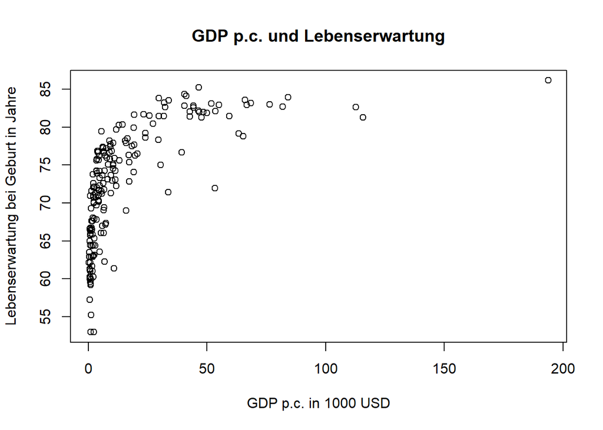

```r
plot(GDPpc/1000, live, xlab = "GDP p.c. in 1000 USD",
     ylab = "Lebenserwartung bei Geburt in Jahre", main = "GDP p.c. und Lebenserwartung")
```

Wie wir sehen, gibt es einen positiven Zusammenhang zwischen GDP p.c. und Lebenserwartung. Allerdings ist dieser positive Zusammenhang nicht linear. Für geringe GDP p.c. Werte führt ein höheres Einkommen zu drastischen Zugewinnen bei der Lebenserwartung, bei höheren GDP p.c. Werten sind die Zugewinne nur noch relativ klein.

Wenn wir GDP p.c. logarithmieren, ändert sich das Bild.

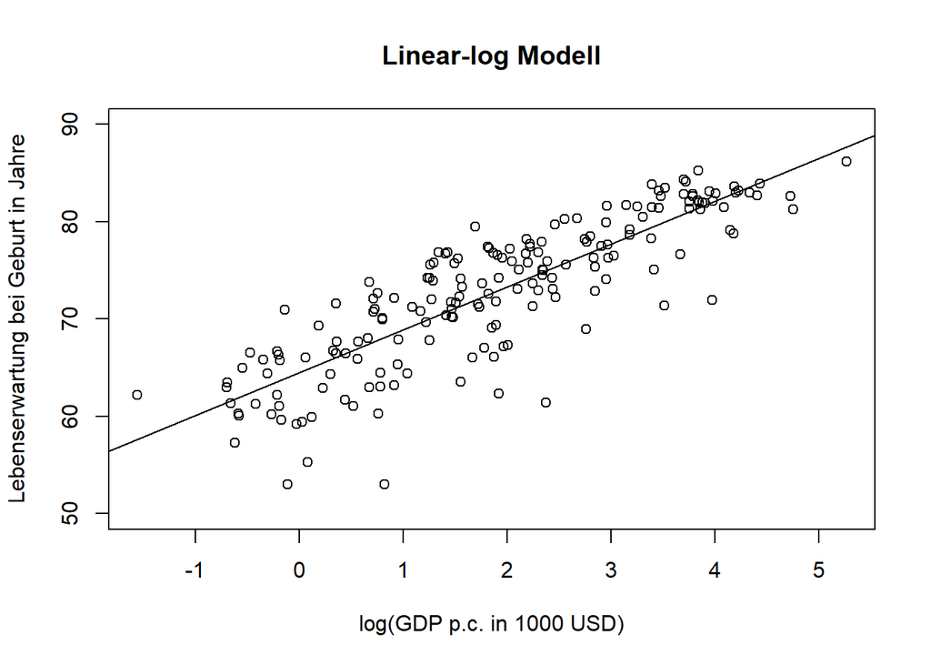

```r
plot(log(GDPpc/1000), live, xlab = "log(GDP p.c. in 1000 USD)",
     ylim = c(50, 90),
     main = "Linear-log Modell",
     ylab = "Lebenserwartung bei Geburt in Jahre")
abline(lm(live ~ log(GDPpc/1000)))
```

Es gibt einen relativ starken, positiven, linearen Zusammenhang zwischen `log(GDPpc/1000)` und `live`. Wir schätzen ein linear-log Modell.

```r
ols <- lm(live ~ log(GDPpc/1000)); ols
```

```
##
## Call:
## lm(formula = live ~ log(GDPpc/1000))
##
## Coefficients:
##     (Intercept)  log(GDPpc/1000)
##            64.5              4.4
```

Das geschätzte Modell (linear-log) ist: $\widehat {live} = 64.5 + 4.4*log(GDPpc/1000)$. Der Anstiegsparameter dieses Modells ist folgendermaßen zu interpretieren: Eine Erhöhung des GDP p.c. um 1% führt gemäß Modellprognose zu einer um 0.044 Jahre höheren Lebenserwartung. Oder: Eine Erhöhung des GDP p.c. um 10% führt gemäß Modellprognose zu einer um ca. 0.44 Jahre höheren Lebenserwartung.

Wir betrachten nochmal die ursprünglichen Daten mit dem geschätzten Modell.

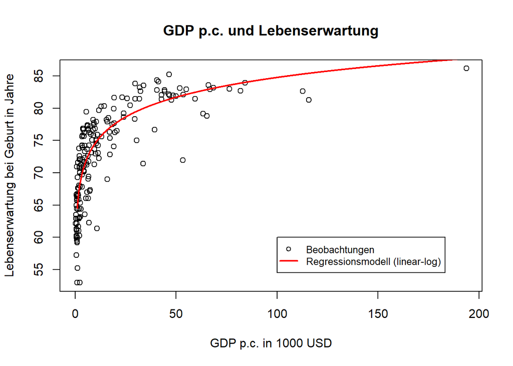

```r
gdp <- seq(1, 200, 0.1)
le <- 64.5 + 4.4*log(gdp)
plot(GDPpc/1000, live, xlab = "GDP p.c. in 1000 USD",
     ylab = "Lebenserwartung bei Geburt in Jahre",
     main = "GDP p.c. und Lebenserwartung")
lines(gdp, le, lwd = 2, col = "red")
legend(100, 60, pch = c(1,NA), c("Beobachtungen","Regressionsmodell (linear-log)"),
       lwd = c(NA,2), col = c("black","red"), cex = 0.8)
```

Wir prüfen das Modell: Bei einem GDP p.c. von 5000 USD prognostiziert das Modell eine Lebenserwartung von 71.56 Jahre. Steigt das GDP p.c. auf 5500 USD (+10%), so prognostiziert das Modell eine Lebenserwartung von 71.98 (ein Plus von 0.42 Jahre). Auf eine Diskussion der Modellannahmen verzichten wir hier aus Platzgründen.

```r
64.474 + 4.403*log(5); 64.474 + 4.403*log(5.5)
```

```
## [1] 71.56
```

```
## [1] 71.98
```

Um die Varianzzerlegung zu illustrieren, können auch die Varianzen ausgeben lassen.

```r
var(live); var(ols$residuals); var(ols$fitted.values)
```

```
## [1] 55.937
```

```
## [1] 15.489
```

```
## [1] 40.448
```

#### Beispiel IV

Betrachten wir ein Beispiel für das log-linear Modell $\widehat {log(y)} = \beta_0 + \beta_1x$.

```r
setwd("C:/Users/sturm/Desktop/dataR")   # setze das Arbeitsverzeichnis
data <- read.csv("Bsp._5.4.csv")
# data <- read.csv("https://raw.githubusercontent.com/bodosturm/dataR/main/Bsp._5.4.csv")
data[1:2, ]; attach(data)
```

|  | educ | wage | male |
| --- | --- | --- | --- |
| 1 | 8 | 5.1 | 0 |
| 2 | 9 | 7.9 | 1 |

Wir betrachten das Streudiagramm für die Variablen `wage` und `educ`:

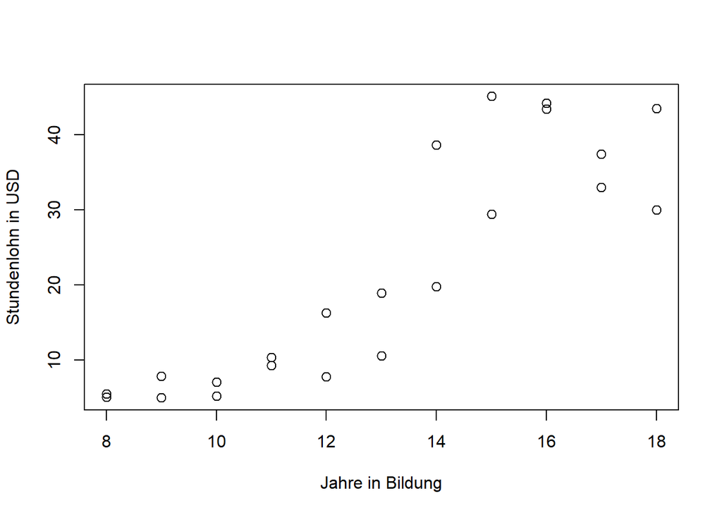

```r
plot(educ, wage, xlab = "Jahre in Bildung", ylab = "Stundenlohn in USD", cex = 1.2)
```

Offensichtlich ist der Zusammenhang nicht linear. Mit zunehmender Bildung steigt der Stundenlohn stärker. Außerdem scheint für das lineare Modell die Streuung der Fehlerterme nicht konstant zu sein. Wenn wir `wage` logarithmieren, ist der Zusammenhang deutlich stärker linear (auch das $R^2$ ist höher).

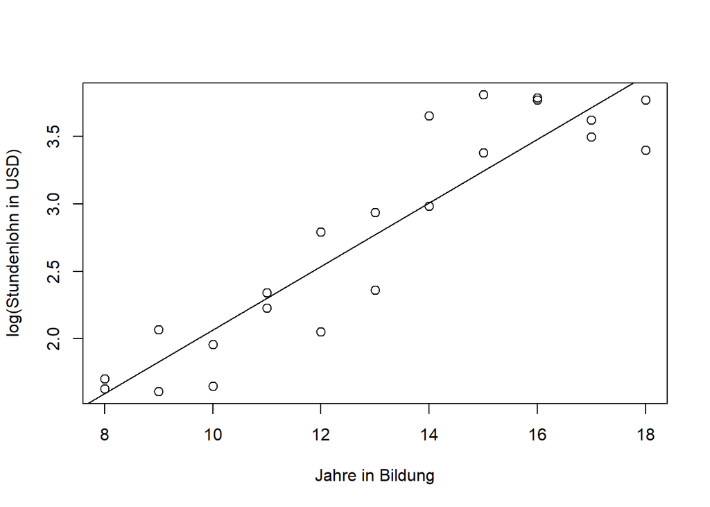

```r
plot(educ, log(wage), xlab = "Jahre in Bildung", ylab = "log(Stundenlohn in USD)", cex = 1.2)
abline(lm(log(wage) ~ educ))
```

Wir lassen uns den Anstiegsparameter ausgeben:

```r
ols3 <- lm(log(wage) ~ educ); ols3
```

```
##
## Call:
## lm(formula = log(wage) ~ educ)
##
## Coefficients:
## (Intercept)         educ
##      -0.290        0.236
```

Interpretation (vgl. Tabelle oben): Das Modell prognostiziert, dass ein Jahr mehr Bildung im Mittel den Stundenlohn um 23.6% erhöht. Der Anstiegsparameter im log-linear Modell ist also eine konstante relative Größe.

Betrachten wir das Streudiagramm zwischen $u$ und $\widehat y$.

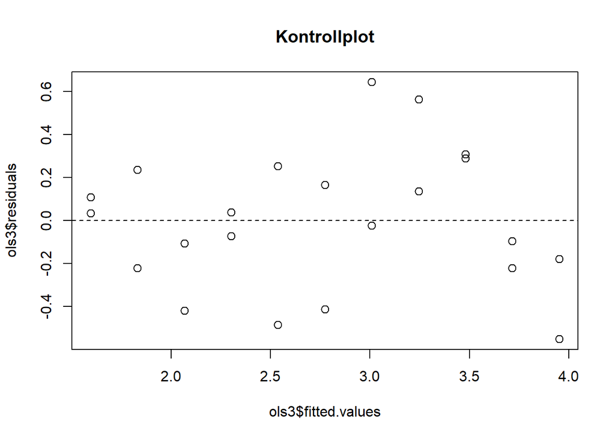

```r
plot(ols3$fitted.values, ols3$residuals, main = "Kontrollplot", cex = 1.2)
abline(h = 0, lty = 2)
```

Die Verteilung der Werte ist relativ unauffällig.

```r
cor(educ, log(wage), method = "pearson")^2
```

```
## [1] 0.85156
```

Das $R^2$ ist relativ hoch mit 85%. Die Variable `educ` kann 85% der Streuung des natürlichen Logs von `wage` erklären.

Die Rücktransformation und grafische Darstellung im Plot für `educ` und `wage` erfolgt folgendermaßen:

```r
log(2.718) # Der Log der Eulerschen Zahl e muss 1 sein
```

```
## [1] 0.9999
```

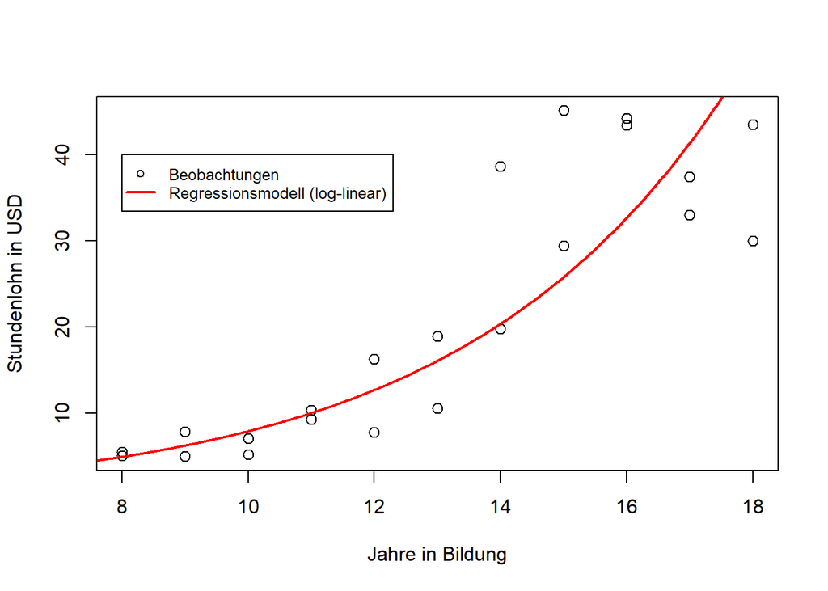

```r
educ_ols <- seq(0, 18, 0.01)
wage_ols <- 2.718^(-0.290 + 0.236*educ_ols)
plot(data$educ, data$wage, cex = 1.2, ylab = "Stundenlohn in USD", xlab = "Jahre in Bildung")
lines(educ_ols, wage_ols, lwd = 2, col = "red")
legend(8, 40, pch = c(1,NA), c("Beobachtungen","Regressionsmodell (log-linear)"), lwd = c(NA,2),
col = c("black","red"), cex = 0.8)
```

Wir sehen in der Abbildung oben, dass ein konstanter relativer Anstieg (ca. +24% pro Jahr) zu einem absolut zunehmenden Effekt von `educ` auf `wage` führt. Wenn `educ = 10` führt ein Jahr mehr in Bildung zu ca. 2 USD mehr Stundenlohn (ca. +27%). Wenn `educ = 15` führt ein Jahr mehr in Bildung zu ca. 7 USD mehr Stundenlohn (ca. +27%). Die Abweichungen zum Modell ergeben sich u.a. dadurch, dass wir einen stetigen Zusammenhang diskret (+1 Jahr) interpretieren.

```r
Eff10_11 <- 2.718^(-0.290 + 0.236*11) - 2.718^(-0.290 + 0.236*10); Eff10_11 # von 10 auf 11 Jahre
```

```
## [1] 2.1087
```

```r
100*Eff10_11/(2.718^(-0.290 + 0.236*10)) # Anstieg in Prozent
```

```
## [1] 26.614
```

```r
Eff15_16 <- 2.718^(-0.290 + 0.236*16) - 2.718^(-0.290 + 0.236*15); Eff15_16 # von 15 auf 16 Jahre
```

```
## [1] 6.8616
```

```r
100*Eff15_16/(2.718^(-0.290 + 0.236*15)) # Anstieg in Prozent
```

```
## [1] 26.614
```

Es stellt sich abschließend die Frage, welche Transformation bei einem nicht-linearen Zusammenhang zu wählen ist. Ziel muss es zunächst sein, die **Bedingungen der linearen Regression** bestmöglich zu erfüllen. Aus den Modellen, die die Bedingungen erfüllen, ist dann das Modell zu wählen, welches die größte Erklärungskraft (also das höchste $R^2$) hat. Zugleich sollte das Modell möglichst einfach zu interpretieren sein.

## Zufallsvariablen und zentraler Grenzwertsatz (alle Module)

In diesem Abschnitt werden wir uns mit ausgewählten Verteilungen von Zufallsvariablen und dem zentralen Grenzwertsatz (Central Limit Theorem, CLT) beschäftigen.

Folgende Verteilungen stetiger Zufallsvariablen werden behandelt:

- Normalverteilung $X \sim N(\mu, \sigma)$ und Standardnormalverteilung $Z \sim N(0,1)$
- Gleichverteilung (Rechteckverteilung)
- $\chi^2$-Verteilung
- t-Verteilung

Dabei behandeln wir u.a. folgende Punkte:

- Zufallsvariablen generieren
- Bestimmung von Quantilen $x_{[q]}$ mit $q \in [0,1]$ und $q=P(X\leq{x_{[q]}})$
- Berechnung von Wahrscheinlichkeiten mit der Verteilungsfunktion $F(x)=P(X\leq{x})$
- Bestimmung von Wahrscheinlichkeiten als Fläche unter der Dichte $f(x)=F'(x)$
- Darstellung von $F$ und $f$ mit `curve()`
- Prüfung auf Normalverteilung mit `qqnorm()`

### Normalverteilung und Standardnormalverteilung

#### Notation

Die Notation für eine normalverteilte Zufallsvariable $X$ ist $X \sim N(\mu, \sigma)$ mit $\mu$ als Mittelwert bzw. Erwartungswert und $\sigma$ als Standardabweichung. Mit `rnorm()` lassen sich Zufallszahlen (`r` steht für “random”, `norm` für “normal distribution”) aus der Normalverteilung erzeugen. Im Folgenden wollen wir 1000 Zufallszahlen aus N(2,6) ziehen und die Werte als Histogramm darstellen. Das Problem: Jeder Rechner wird hier unterschiedliche Ergebnisse erhalten, da auf jedem Rechner ein Zufallsprozess läuft. Daher benötigen wir einen Befehl, um die Reproduzierbarkeit der Ergebnisse sicherzustellen. Mit `set.seed()` und der Angabe einer einheitlichen Zahl kann ein Zufallsexperiment durchgeführt werden, so dass die Ergebnisse auf unterschiedlichen Rechnern identisch sind.

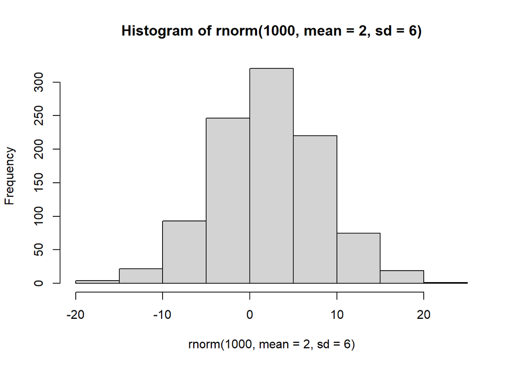

```r
set.seed(5); hist(rnorm(1000, mean = 2, sd = 6)) # set.seed() hier mit Zahl = 5
```

Die Notation für die standardnormalverteilte Zufallsvariable $Z$ ist $Z \sim N(0,1)$. Wir wollen hier 1000 Zufallsvariablen aus N(0,1) erzeugen und die Verteilung mit einem Histogramm darstellen.

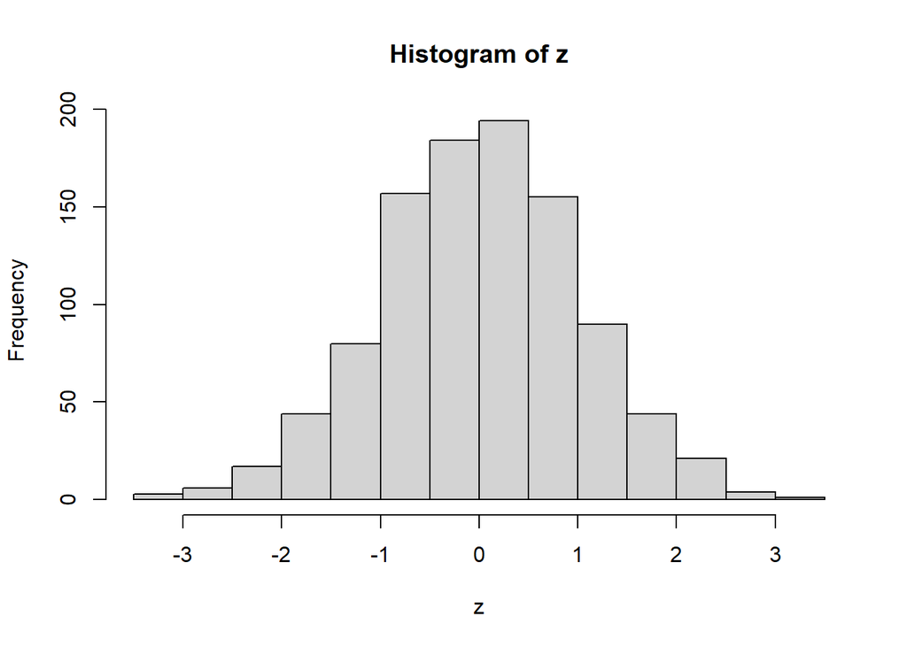

```
##    Min. 1st Qu.  Median    Mean 3rd Qu.    Max.
## -3.4981 -0.6556  0.0223  0.0174  0.6919  3.4019
```

```
## [1] 1.012
```

```r
set.seed(5); z <- rnorm(1000, mean = 0, sd = 1)
hist(z); summary(z); sd(z)
```

#### Standardisierung

Jede normalverteilte Zufallsvariable $X \sim N(\mu, \sigma)$ kann durch Standardisieren in eine standardnormalverteilte Zufallsvariable $Z \sim N(0, 1)$ überführt werden. Es gilt

$Z=\frac{X - \mu}{\sigma}$.

Der Vorteil der Standardisierung liegt allgemein darin, dass man von der Variablenausprägung direkt auf die Abweichungen zum Mittelwert in Einheiten der Standardabweichung schließen kann (unabhängig davon, ob eine Normalverteilung vorliegt oder nicht). Beispiel: $X \sim N(4, 2)$. Der Wert $x=0$ liegt 2 Standardabweichungen unter dem Mittelwert. Standardisiert ergibt sich $z=(0-4)/2=-2$. Der Wert $x=7$ liegt 1.5 Standardabweichungen über dem Mittelwert. Standardisiert ergibt sich $z=(7-4)/2=1.5$. Außerdem kann man nach der Standardisierung von $X \sim N(\mu, \sigma)$ mit den (tabellierten) $z$-Werten für N(0,1) rechnen und über die Tabelle der Verteilungsfunktion $F_{St}$ für $N(0,1)$ Eintrittswahrscheinlichkeiten bestimmen (vgl. Lehrbuch).

#### Empirical Rule

Zur Interpretation der Normalverteilung wird die “Empirical Rule” verwendet: Bei einer normalverteilten Zufallsvariable $X \sim N(\mu, \sigma)$ liegen im Intervall $\mu +/-2\sigma$ ca. 95% aller Beobachtungen. Wir zeigen hier die Gültigkeit der Empirical Rule für $Z \sim N(0, 1)$ mit verschiedenen Methoden, die allesamt nützlich sind, um Informationen über beliebige Verteilungen zu erhalten.

Methode 1: **Quantile**. Ein Quantil $x_{[q]}$ ist eine Zahl $x$ mit $q\in[0,1]$, für die gilt, dass der Anteil $q$ aller Beobachtungen kleiner oder gleich $x$ ist, d.h. $q=P(X\leq{x_{[q]}})$. Wir suchen also hier die Quantile $z_{[0.025]}$ und $z_{[0.975]}$. Zwischen diesen Werten liegen ca. 95% aller Beobachtungen von $Z$.

```r
set.seed(5); z <- rnorm(1000, mean = 0, sd = 1)
quantile(z, probs = c(0.025, 0.975)) # 2.5%- und 97.5%-Quantil
```

```
##    2.5%   97.5%
## -2.0010  2.0073
```

Der genaue Wert ist $z_{[0.975]} = 1.96$. 97.5% aller Werte von $Z$ sind also kleiner oder gleich 1.96. Die Zahl **1.96** - das 97.5%-Quantil der Standardnormalverteilung - ist **die wichtigste Zahl in der Statistik**. Wir benötigen diesen Wert bei der Berechnung von 95%-Konfidenzintervallen und als kritischen Wert für den zweiseitigen Hypothesentest zum Signifikanzniveau $\alpha=0.05$ (vgl. weiter unten zu Inferenzstatistik).

Die exakten Quantile von $N(\mu,\sigma)$ lassen sich mit `qnorm()` ausgeben.

```r
qnorm(0.975, mean = 0, sd = 1)  # 97.5%-Quantil von N(0,1) = z[0.975] = 1.96
```

```
## [1] 1.96
```

```r
qnorm(0.025, mean = 0, sd = 1)  # 2.5%-Quantil von N(0,1) = z[0.025] = -1.96
```

```
## [1] -1.96
```

Methode 2: Logische Abfrage mit “und” (oder alternativ mit “oder”). Wir suchen die relative Häufigkeit für $-2 \leq z \leq 2$.

```r
set.seed(5); z <- rnorm(1000, mean = 0, sd = 1)
prop.table(table((z >= -1.96) & (z <= 1.96))) # logisches UND
```

```
##
## FALSE  TRUE
##  0.06  0.94
```

#### Exkurs: Logische Bedingungen

Mit logischen Bedingungen lassen sich Abfragen leicht durchführen und dann mit `table()` auswerten (vgl. folgende Tabelle).

Logische Bedingungen

| Operator in R | Interpretation |
| --- | --- |
| `==` | gleich |
| `>` | größer |
| `<` | kleiner |
| `!=` | ungleich |
| `&` | und |
| `>=` | größer gleich |
| `<=` | kleiner gleich |
| `\|` | oder |

```r
# ein Beispiel für die Anwendung logischer Bedingungen
X <- 1:10; Y <- 16:25
Z <- c(rep("Yes", 4), rep("No", 6))
data.frame(X, Y, Z)
```

| X | Y | Z |
| --- | --- | --- |
| 1 | 16 | Yes |
| 2 | 17 | Yes |
| 3 | 18 | Yes |
| 4 | 19 | Yes |
| 5 | 20 | No |
| 6 | 21 | No |
| 7 | 22 | No |
| 8 | 23 | No |
| 9 | 24 | No |
| 10 | 25 | No |

```r
table(X <= 2 & Z == "Yes")
```

```
##
## FALSE  TRUE
##     8     2
```

```r
table(X <= 2 | Z == "Yes")
```

```
##
## FALSE  TRUE
##     6     4
```

```r
X > 8 & Y != 24 & Z == "No"
```

```
##  [1] FALSE FALSE FALSE FALSE FALSE FALSE FALSE FALSE FALSE  TRUE
```

```r
table(X > 8 & Y != 24 & Z == "No")
```

```
##
## FALSE  TRUE
##     9     1
```

Methode 3: **Verteilungsfunktion**. Die Verteilungsfunktion der Variablen $X$, $F(x)$, ist eine Funktion, für die gilt $F(x) = P(X \leq x)$. $F$ ist eine kompakte Darstellung für die Verteilung einer Zufallsvariablen und häufig tabelliert (z.B. $F_{St}$ für N(0,1), vgl. Lehrbuch).

Hier zunächst nur die graphische Darstellung von $F$ für `z` (1000 Zufallszahlen aus $N(0,1)$):

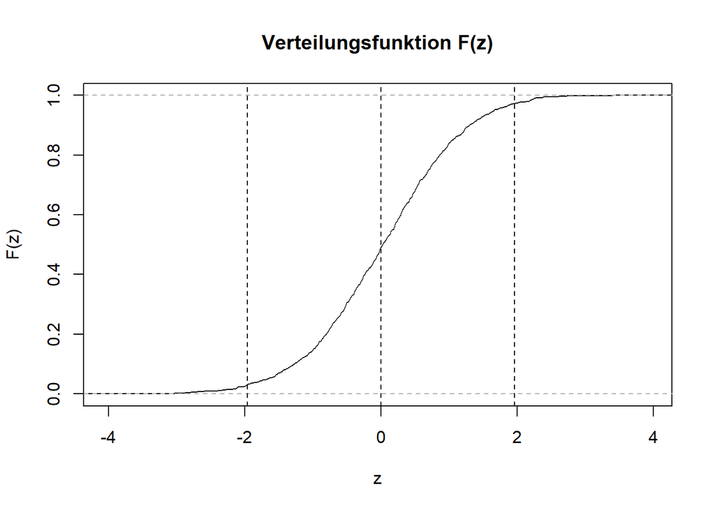

```r
plot.ecdf(z, xlab = "z", ylab = "F(z)", main= "Verteilungsfunktion F(z)")
abline(v = c(-1.96, 0, 1.96), lty = 2)
```

Wir schreiben für die Verteilungsfunktion von $N(0,1)$ auch $F_{St}$. Oben war $z_{[0.025]} = -1.96$. Dies ist mit der Abbildung von $F_{St}$ konsistent, da $F_{St}(-1.96) = 0.025$. Analog gilt $F_{St}(1.96) = 0.975$. Die Quantile lassen sich also aus der Verteilungsfunktion ablesen. Es gilt: $q=F(x_{[q]})$ und $x_{[q]}=F^{-1}(q)$. Quantile $x_{[q]}$ lassen sich also über die Umkehrfunktion der Verteilungsfunktion $F^{-1}(q)$ bestimmen.

Die exakten Werte für $F$ von $N(\mu,\sigma)$ lassen sich mit `pnorm()` ausgeben. Zum Beispiel für $N(0,1)$:

```r
pnorm(0, mean = 0, sd = 1)      # 0 ist das 50%-Quantil von N(0,1)
```

```
## [1] 0.5
```

```r
pnorm(1.645, mean = 0, sd = 1)  # 1.645 ist das 95%-Quantil von N(0,1)
```

```
## [1] 0.95002
```

```r
pnorm(1.96, mean = 0, sd = 1)   # 1.96 ist das 97.5%-Quantil von N(0,1)
```

```
## [1] 0.975
```

Die **Dichtefunktion** einer Zufallsvariablen $X$, $f$, ist die 1. Ableitung von $F$. Kurz: $F' = f$. Mit Hilfe der Umkehroperation zur 1. Ableitung gilt: $F(x) = \int_{-\infty}^{x} f dx$. Wir können also $F(x)=P(X \leq x)$ aus der Dichte $f$ ablesen als Fläche unter der Dichte $f$ von $-\infty$ bis $x$.

Die exakten Werte für die Dichte von $N(\mu,\sigma)$ lassen sich mit `dnorm()` ausgeben. Zum Beispiel für $N(0,1)$:

```r
dnorm(0, mean = 0, sd = 1)   # maximale Dichte bei z = 0
```

```
## [1] 0.39894
```

```r
dnorm(1, mean = 0, sd = 1)   # positive Dichte bei z = 1
```

```
## [1] 0.24197
```

```r
dnorm(-1, mean = 0, sd = 1)  # Symmetrie
```

```
## [1] 0.24197
```

```r
dnorm(5, mean = 0, sd = 1)   # Dichte ist praktisch Null für z > 3
```

```
## [1] 1.4867e-06
```

Wenn wir die **Wahrscheinlichkeit** $P(X \leq x)$ suchen, gibt es also zwei Optionen:

1. Berechnung über den Funktionswert von $F$. Es gilt $P(X \leq x) = F(x)$.
2. Berechnung als Fläche unter der Dichte $f$. Es gilt $P(X \leq x) = \int_{-\infty}^{x} f dx$.

#### Darstellung von Funktionen mit `curve()`

Mit `curve()` können wir u.a. die Dichte $f$ von $N(\mu, \sigma)$ darstellen. Man kann auch mehrere Kurven mit `curve()` darstellen, nur muss man dann `add = TRUE` ergänzen. Hier:

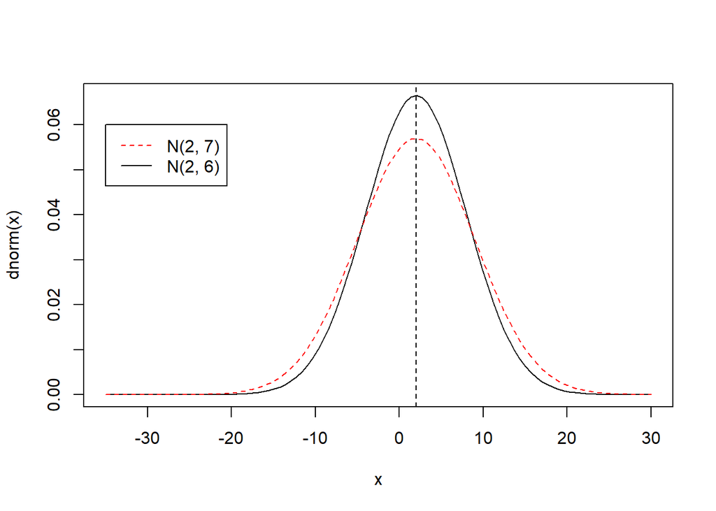

```r
curve(dnorm(x, mean = 2, sd = 6), xlim = c(-35, 30), ylab = "dnorm(x)")
abline(v = 2, lty = 2)
curve(dnorm(x, mean = 2, sd = 7), lty = 2, col = "red", add = TRUE)
legend(-35, 0.06, lty = c(2,1), col = c("red", "black"), c("N(2, 7)", "N(2, 6)"))
```

#### Berechnung von Wahrscheinlichkeiten

Wir wollen nun Eintrittswahrscheinlichkeiten für normalverteilte Zufallsvariablen bestimmen. Betrachten wir ein Beispiel zu $N(\mu, \sigma)$: Gegeben $X \sim N(100,20)$ und man soll (1) $P(X > 110)$ und (2) $P(100 < X \leq 130)$ bestimmen.

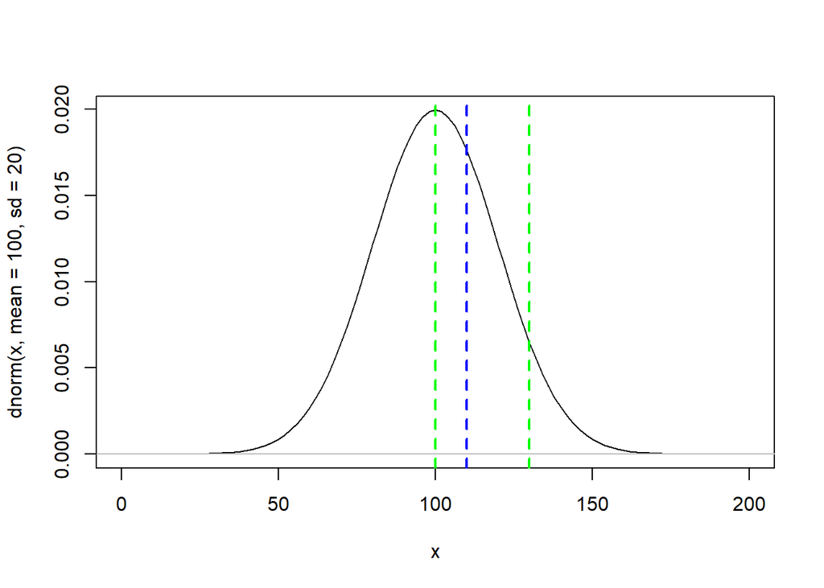

```r
curve(dnorm(x, mean = 100, sd = 20), xlim = c(0, 200))
abline(h = 0, col = "grey")
abline(v = 110, lty = 2, col = "blue", lwd = 2)
abline(v = c(100, 130), lty = 2, col = "green", lwd = 2)
```

Die Berechnung der gesuchten Wahrscheinlichkeit (1), gleich der Fläche unter der Dichte rechts von der blauen vertikalen Linie, ist damit folgendermaßen möglich:

1. Direkt über `pnorm()`

```r
1 - pnorm(110, mean = 100, sd = 20)
```

```
## [1] 0.30854
```

2. Mit Standardisierung und über $N(0,1)$

Der gesuchte z-Wert ist hier 0.5, da

$P(X > 110) = P((X - \mu)/\sigma > (110 - 100)/20) = P(Z > 0.5) = 1 - P(Z \leq 0.5) = 1 - F_{St}(0.5)$

```r
1 - pnorm(0.5, mean = 0, sd = 1)
```

```
## [1] 0.30854
```

Die Wahrscheinlichkeit (2), gleich der Fläche unter der Dichte zwischen den beiden grünen vertikalen Linien, berechnet sich entsprechend.

```r
pnorm(130, mean = 100, sd = 20) - pnorm(100, mean = 100, sd = 20)
```

```
## [1] 0.43319
```

#### Exkurs: Definition von Funktionen und Integration

Mit R lassen sich Funktionen definieren und bestimmte Integrale berechnen. Man kann also die Fläche unter einer Funktion numerisch bestimmen. Im folgenden Beispiel definieren wir eine Funktion, stellen diese grafisch dar und lassen uns einen Funktionswert ausgeben. Dann berechnen wir zwei bestimmte Integrale für diese Funktion.

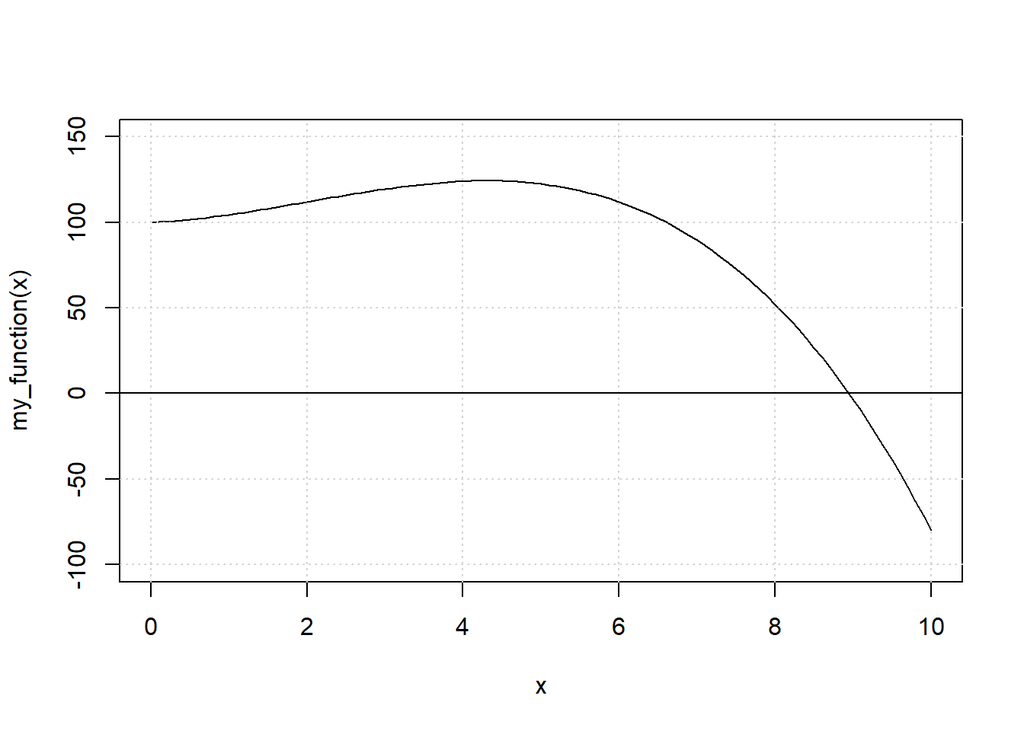

```r
my_function <- function(x) {    # Generiert eine Funktion my_function
  y <- 2*x + 3*x^2 - 0.5*x^3 + 100
  return(y)
}

curve(my_function, xlim = c(0, 10), ylim = c(-100, 150)); grid(); abline(h = 0)
```

```r
my_function(x=6)                # my_function für x = 6
```

```
## [1] 112
```

```r
integrate(my_function, 0, 2)    # Integral über my_function im Intervall [0, 2]
```

```
## 210 with absolute error < 2.3e-12
```

```r
integrate(my_function, 2, 4)    # Integral über my_function im Intervall [2, 4]
```

```
## 238 with absolute error < 2.6e-12
```

Man kann auch über in R definierte Funktionen wie `dnorm()` oder `dunif()` integrieren.

```r
# Dichte unter N(0,1) im Intervall [-Inf, -1.96]
integrate(dnorm, mean = 0, sd = 1, -Inf, -1.96)
```

```
## 0.024998 with absolute error < 0.000019
```

```r
# Dichte unter N(0,1) im Intervall [-1.96, 1.96]
integrate(dnorm, mean = 0, sd = 1, -1.96, 1.96)
```

```
## 0.95 with absolute error < 1e-11
```

```r
# Dichte unter der Rechteckverteilung mit min = 1 und max = 9 im Intervall [1, 4]
integrate(dunif, min = 1, max = 9, 1, 4)
```

```
## 0.375 with absolute error < 4.2e-15
```

#### qq-Plot

Man will häufig wissen, ob ein Vektor von Zahlen einer $N(\mu, \sigma)$-Verteilung folgt. Das Quantile-Quantile-Plot (“qq-Plot”) stellt die Quantile der $N(0,1)$-Verteilung auf der Abszisse gegen die Quantile der beobachteten Variable auf der Ordinate dar. Wenn das qq-Plot näherungsweise eine **Gerade** zeigt, liegt eine $N(\mu, \sigma)$-Verteilung vor.

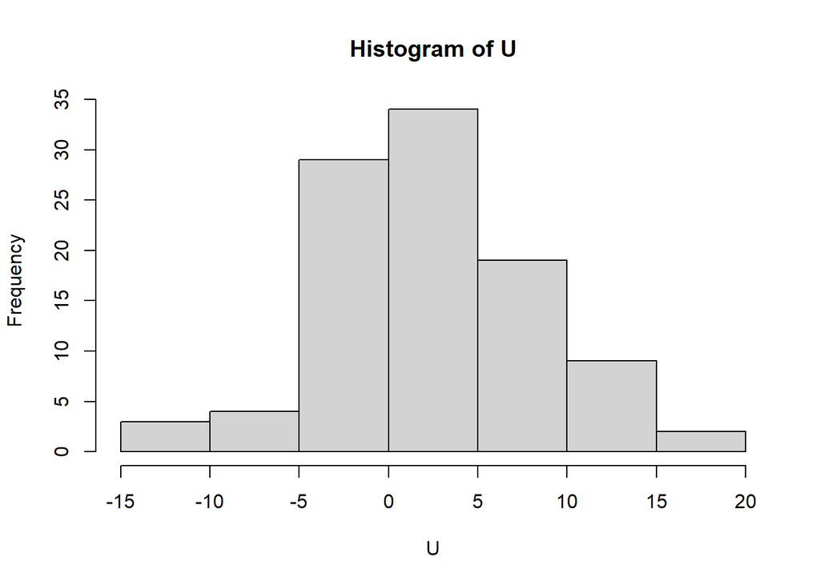

```r
set.seed(5); U <- rnorm(100, mean = 2, sd = 6)
hist(U)
```

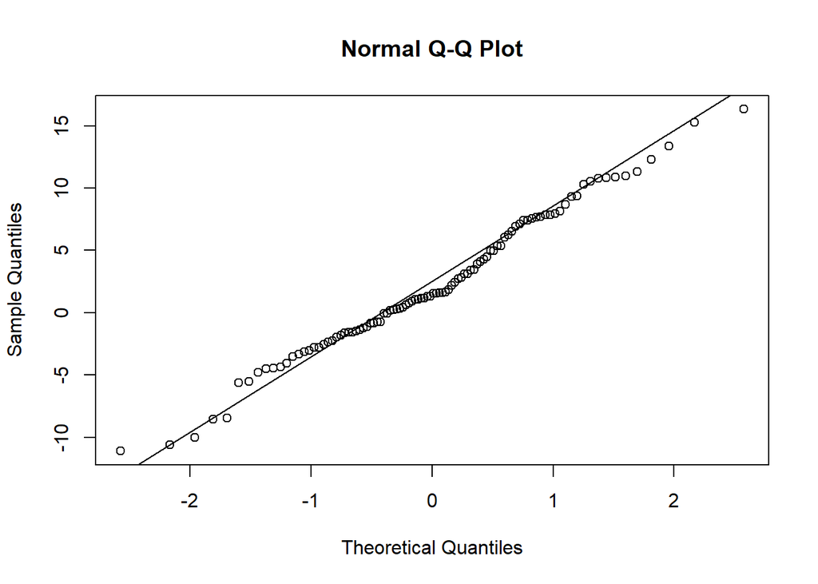

```r
qqnorm(U)
qqline(U)  # ergänzt die 45-Grad-Linie
```

#### Exkurs: Shapiro-Wilk-Test auf Normalverteilung

Mit diesem Hypothesentest (vgl. weiter unten zu Inferenzstatistik) kann man anhand einer Stichprobe untersuchen, ob die zugrundeliegende Grundgesamtheit einer Normalverteilung folgt. Die Nullhypothese besagt bei diesem Test, dass in der Grundgesamtheit eine Normalverteilung vorliegt. Die Alternativhypothese besagt, dass in der Grundgesamtheit keine Normalverteilung vorliegt. Das bedeutet: Kann bei diesem Test statistische Signifikanz (p-value < 0.05) festgestellt werden, so müssen wir die Nullhypothese verwerfen und davon ausgehen, dass in der Grundgesamtheit keine Normalverteilung vorliegt. Ist das Testergebnis statistisch insignifikant (p-value $\geq$ 0.05), so können wir die Nullhypothese nicht verwerfen (und können weiter mit der Hypothese der Normalverteilung arbeiten).

Wir betrachten das folgende Beispiel mit zwei Stichproben `x` und `y`:

```r
x <- c(1,1,2,2,1,1)
set.seed(4); y <- rnorm(6, mean = 4, sd = 2)
shapiro.test(x)
```

```
##
##  Shapiro-Wilk normality test
##
## data:  x
## W = 0.64, p-value = 0.0014
```

```r
shapiro.test(y)
```

```
##
##  Shapiro-Wilk normality test
##
## data:  y
## W = 0.976, p-value = 0.93
```

Für die erste Variable (`x`) können wir die Nullhypothese, nach der eine Normalverteilung in der Grundgesamtheit vorliegt, verwerfen. Der p-value liegt unter 5%, dem üblichen Signifikanzniveau. Für die zweite Variable (`y`) können wir die Nullhypothese, nach der eine Normalverteilung in der Grundgesamtheit vorliegt, nicht verwerfen und behalten sie bei.

Auf Grund der Bedeutung der bisher betrachteten Konzepte erläutern wir diese nochmal am Beispiel der $N(0,1)$- und der $N(2,2)$-Verteilung: (1) Zufallsvariablen, (2) Quantile, (3) Werte der Dichte $f$ und (4) Werte der Verteilungsfunktion $F$.

1. Zufallsvariablen (`r` für “random”)

```r
set.seed(3); rnorm(5) # 5 Zufallszahlen aus N(0,1)
```

```
## [1] -0.96193 -0.29253  0.25879 -1.15213  0.19578
```

```r
set.seed(3); rnorm(5, mean = 2, sd = 2) # aus N(2,2)
```

```
## [1]  0.076133  1.414949  2.517576 -0.304264  2.391566
```

2. Quantile (`q` für “Quantil”)

```r
qnorm(0.5)    # 0.5-Quantil (auch "50%-Quantil") für N(0,1)
```

```
## [1] 0
```

```r
qnorm(0.975)  # 0.975-Quantil (auch "97.5%-Quantil") für N(0,1)
```

```
## [1] 1.96
```

```r
qnorm(0.5, mean = 2, sd = 2)    # 0.5-Quantil für N(2,2)
```

```
## [1] 2
```

```r
qnorm(0.975, mean = 2, sd = 2)  # 0.975-Quantil für N(2,2)
```

```
## [1] 5.9199
```

3. Werte der Dichte $f$ (`d` für “density”)

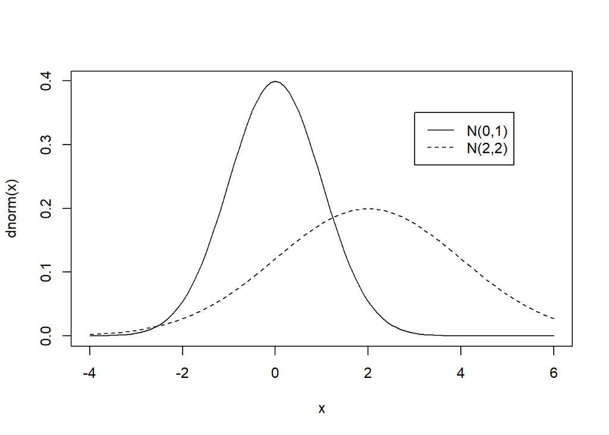

```r
curve(dnorm(x), xlim = c(-4, 6)) # Dichte f für N(0,1)
curve(dnorm(x, mean = 2, sd = 2), add = TRUE, lty = 2) # Dichte f für N(2,2)
legend(3, 0.35, c("N(0,1)", "N(2,2)"), lty = c(1,2))
```

4. Werte der Verteilungsfunktion $F$ (`p` für “probability”)

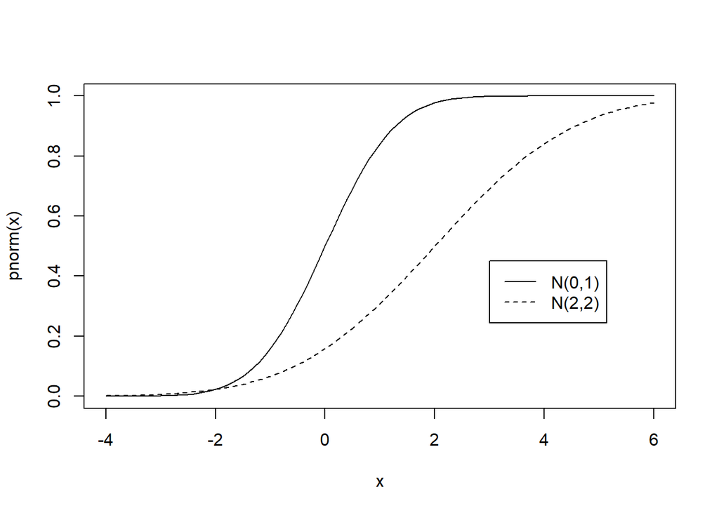

```r
curve(pnorm(x), xlim = c(-4, 6)) # F für N(0,1)
curve(pnorm(x, mean = 2, sd = 2), add = TRUE, lty = 2) # F für N(2,2)
legend(3, 0.45, c("N(0,1)", "N(2,2)"), lty = c(1,2))
```

#### Exkurs: Flächen unter der Dichte

Allgemein lassen sich Flächen in einem Plot mit `polygon()` darstellen. Dabei sind x- und y-Koordinaten für die Fläche zu definieren. Betrachten wir das folgende Beispiel:

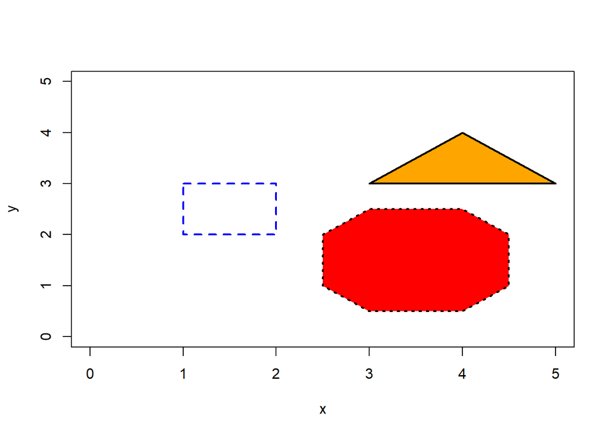

```r
plot(0, cex = 1.2, xlim = c(0, 5), type = "n",
ylim = c(0, 5), xlab = "x", ylab = "y")
x.coord1 <- c(1, 2, 2, 1) # x für Viereck
y.coord1 <- c(3, 3, 2, 2) # y für Viereck
x.coord2 <- c(2.5, 2.5, 3.0, 4.0, 4.5, 4.5, 4.0, 3.0) # Achteck
y.coord2 <- c(1.0, 2.0, 2.5, 2.5, 2.0, 1.0, 0.5, 0.5)
x.coord3 <- c(3, 4, 5) # Dreieck
y.coord3 <- c(3, 4, 3)
polygon(x.coord1, y.coord1, lty = 2, border = "blue", lwd = 2)
polygon(x.coord2, y.coord2, lty = 3, lwd = 2, col = "red")
polygon(x.coord3, y.coord3, lty = 1, lwd = 2, col = "orange")
```

Mit `polygon()` lassen sich auch Flächen unter der Dichte darstellen.

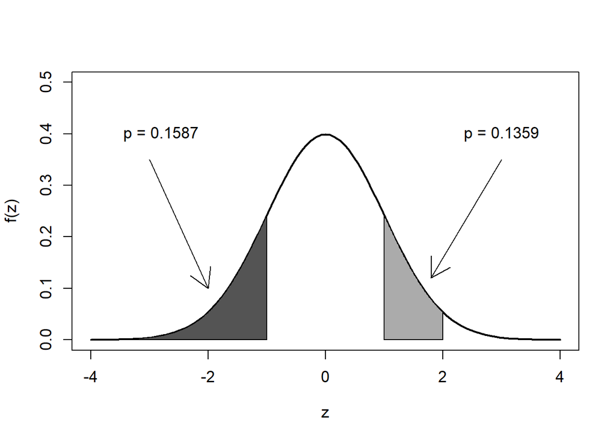

```r
cord.x1 <- c(-4,seq(-4,-1,0.01),-1)
cord.y1 <- c(0,dnorm(seq(-4,-1,0.01)),0)
cord.x2 <- c(1,seq(1,2,0.01),2)
cord.y2 <- c(0,dnorm(seq(1,2,0.01)),0)
curve(dnorm(x),xlim=c(-4,4), ylim = c(0, 0.5), lwd = 2,
cex.lab = 1.1, cex.axis = 1.1, ylab = "f(z)", xlab = "z")
polygon(cord.x1,cord.y1,col='gray33')
polygon(cord.x2,cord.y2,col='gray67')
text(-2.8, 0.4, "p = 0.1587", cex = 1.1)
text(3.0, 0.4, "p = 0.1359", cex = 1.1)
arrows(-3, 0.35, -2, 0.1); arrows(3, 0.35, 1.8, 0.12)
```

In der Abbildung oben ist $P(Z \leq -1)=F_{St}(-1)$ und $P(1 < Z \leq 2)=F_{St}(2)-F_{St}(1)$ dargestellt.

### Rechteckverteilung

Wir betrachten nun die Rechteckverteilung `unif` (auch “Gleichverteilung” genannt). Die stetige Rechteckverteilung ist durch eine konstante Dichte im Intervall $[a,b]$ mit $a<b$ charakterisiert.

1. Zufallsvariablen mit `r`

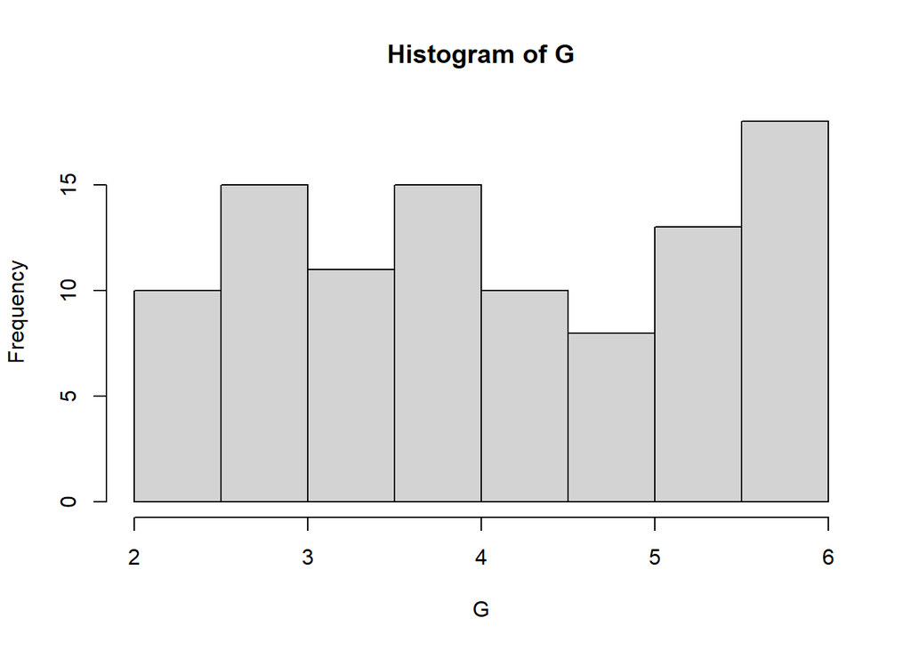

```r
set.seed(5); G <- runif(100, min = 2, max = 6)
hist(G)
```

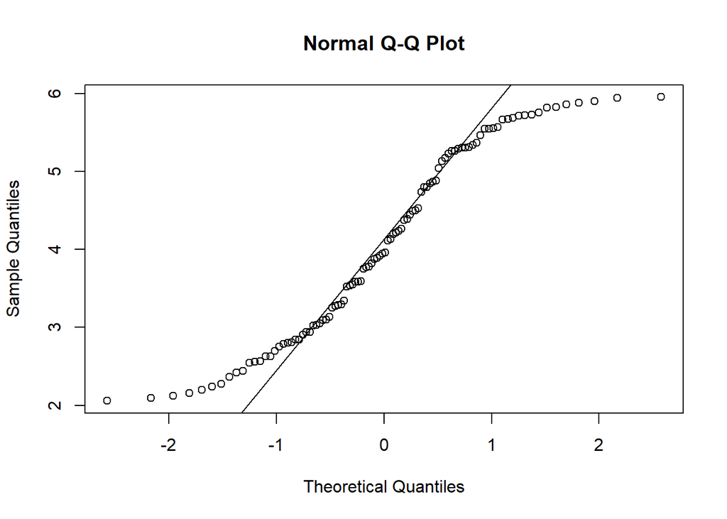

```r
qqnorm(G); qqline(G) # starke Abweichung von N(mu, sigma)
```

2. Quantile mit `q`

```r
qunif(0.5, min = 2, max = 6)  # Median
```

```
## [1] 4
```

```r
qunif(0.25, min = 2, max = 6) # Q1
```

```
## [1] 3
```

3. Dichte $f$ mit `d`

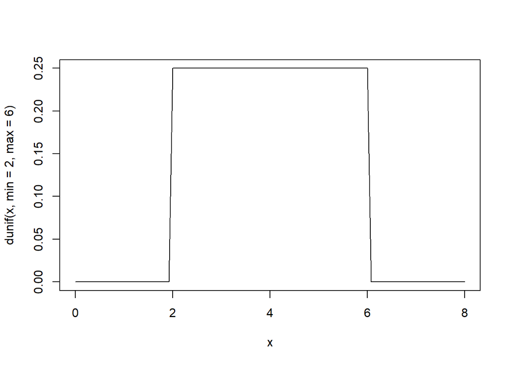

```r
curve(dunif(x, min = 2, max = 6), xlim = c(0, 8))
```

```r
dunif(0.5, min = 2, max = 6); dunif(3.5, min = 2, max = 6)
```

```
## [1] 0
```

```
## [1] 0.25
```

4. Verteilungsfunktion $F$ mit `p`

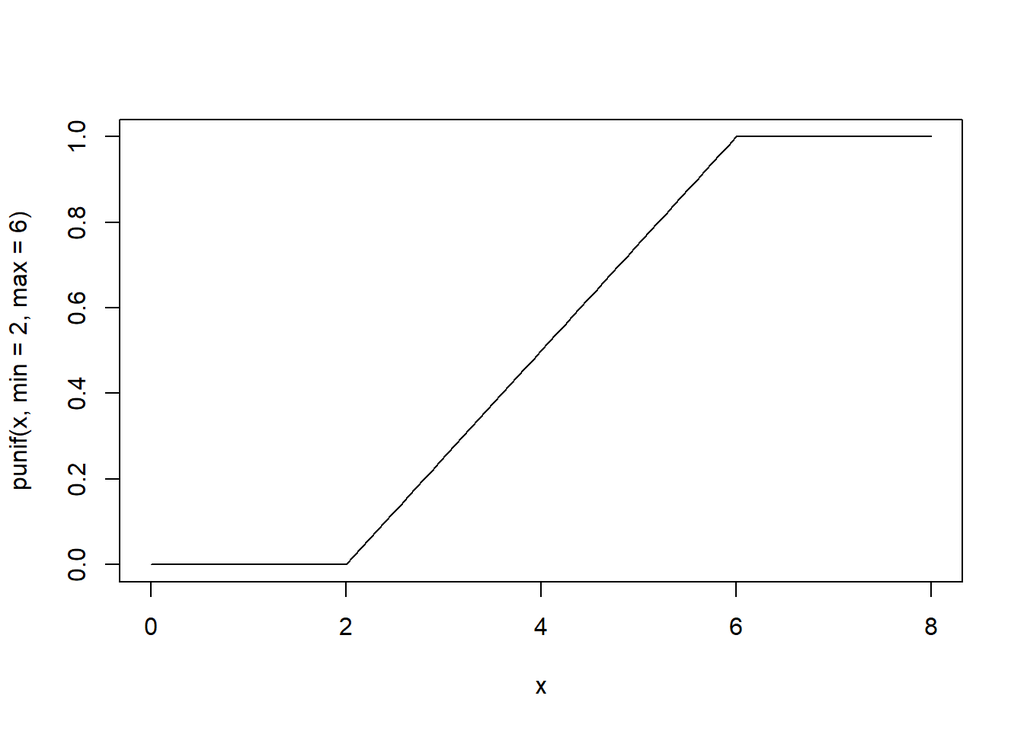

```r
curve(punif(x, min = 2, max = 6), xlim = c(0, 8))
```

```r
punif(1, min = 2, max = 6); punif(5, min = 2, max = 6)
```

```
## [1] 0
```

```
## [1] 0.75
```

### $\chi^2$-Verteilung

Die $\chi^2$-Verteilung ist eine stetige Verteilung, die insbesondere beim Testen von Hypothesen mit qualitativen Merkmalen benötigt wird. Eine $\chi^2$-Zufallsvariable mit $n$ Freiheitsgraden (df = degrees of freedom) ergibt sich, wenn die Quadrate von $n$ $N(0,1)$-verteilten Zufallsvariablen addiert werden.

Wenn also $Z_1, Z_2, ..., Z_n$ $N(0,1)$-verteilte und unabhängige Zufallsvariablen sind, dann heißt die Zufallsvariable

$\chi^2_n=Z^2_1+Z^2_2+...+Z^2_n$

$\chi^2$-verteilt mit $n$ Freiheitsgraden ($df$).

Die $\chi^2$-Verteilungen haben damit immer eine positive Dichte im Intervall $[0, +\infty]$. Für kleine $df$ ist die Dichte **linkssteil**. Für große $df$ konvergiert die $\chi^2$-Verteilung gegen eine Normalverteilung. Der **Modus** liegt bei $df-2$ für $df\geq2$. Das Kürzel in R für die $\chi^2$-Verteilung ist `chisq`. Die Kürzel `r`, `d`, `q`, `p` werden wie bei anderen Verteilungen auch genutzt.

Der Plot der Dichte für $\chi^2(df=4)$, $\chi^2(df = 10)$ und $\chi^2(df=30)$ ist:

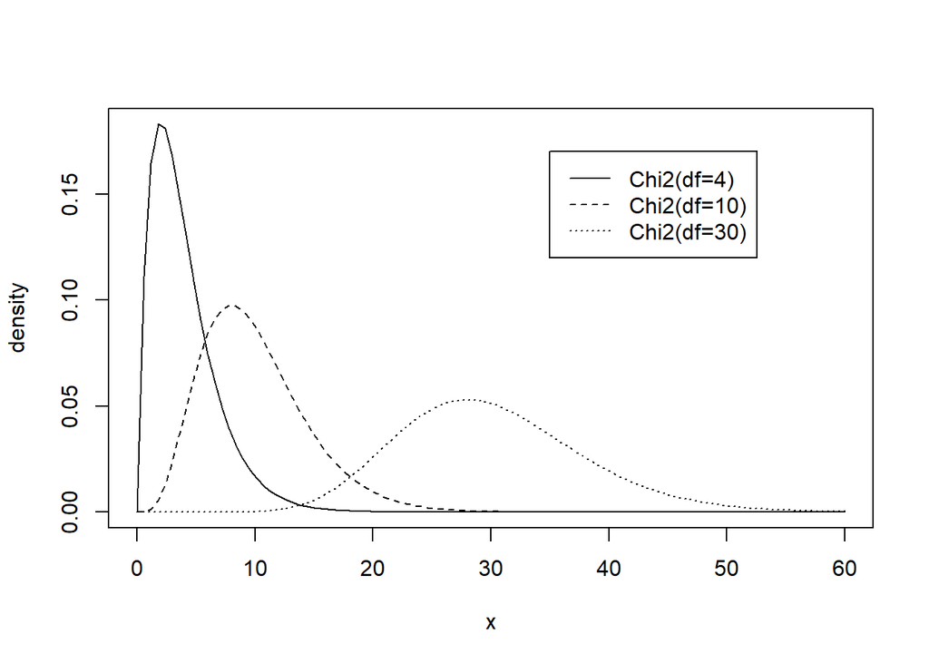

```r
curve(dchisq(x, df = 4), xlim = c(0, 60), ylab = "density")
curve(dchisq(x, df = 10), lty = 2, add = TRUE)
curve(dchisq(x, df = 30), lty = 3, add = TRUE)
legend(35, 0.17, c("Chi2(df=4)", "Chi2(df=10)", "Chi2(df=30)"), lty = c(1,2,3))
```

Die Quantile der $\chi^2$-Verteilung sind positiv. Betrachten wir die 95%-Quantile der $\chi^2$-Verteilungen in der Abbildung oben:

```r
qchisq(0.95, df = 4); qchisq(0.95, df = 10); qchisq(0.95, df = 30)
```

```
## [1] 9.4877
```

```
## [1] 18.307
```

```
## [1] 43.773
```

Das 95%-Quantil wird mit der Zahl der Freiheitsgrade df größer.

### t-Verteilung

Gegeben sei die $\chi^2$-verteilte Zufallsvariable $\chi^2_n$ und die $N(0,1)$-verteilte Zufallsvariable $Z$. Beide Zufallsvariablen seien stochastisch unabhängig voneinander.

Dann heißt die Zufallsvariable

$T_n=\frac{Z}{\sqrt{\frac{\chi^2_n}{n}}}$

t-verteilt mit $n$ Freiheitsgraden (df). Die t-Verteilung ist eine um Null symmetrische, stetige Verteilung mit df > 1. Im Vergleich zur $N(0,1)$-Verteilung ist die Dichte der t-Verteilung um Null kleiner und an den Rändern größer. Die t-Verteilung konvergiert für zunehmende df gegen $N(0,1)$. Für df = 30 und größer können die t-Quantile praktisch durch $N(0,1)$-Quantile approximiert werden. Die t-Verteilung ist bedeutsam insbesondere für das Testen von Hypothesen über den wahren Mittelwert und für die Berechnung von entsprechenden Konfidenzintervallen (vgl. Kapitel “Inferenz für quantitative Daten”). Sie geht zurück auf William Sealy Gosset, der unter dem Pseudonym “Student” die Idee dieser Verteilung 1908 zum ersten Mal tabellierte (daher wird diese Verteilung auch Student’s t genannt).

Das Kürzel in R für die t-Verteilung ist `t`. Die Kürzel `r`, `d`, `q`, `p` werden wie bei anderen Verteilungen auch genutzt.

Der Plot der Dichte für N(0,1), t(df = 2) und t(df = 20) ist:

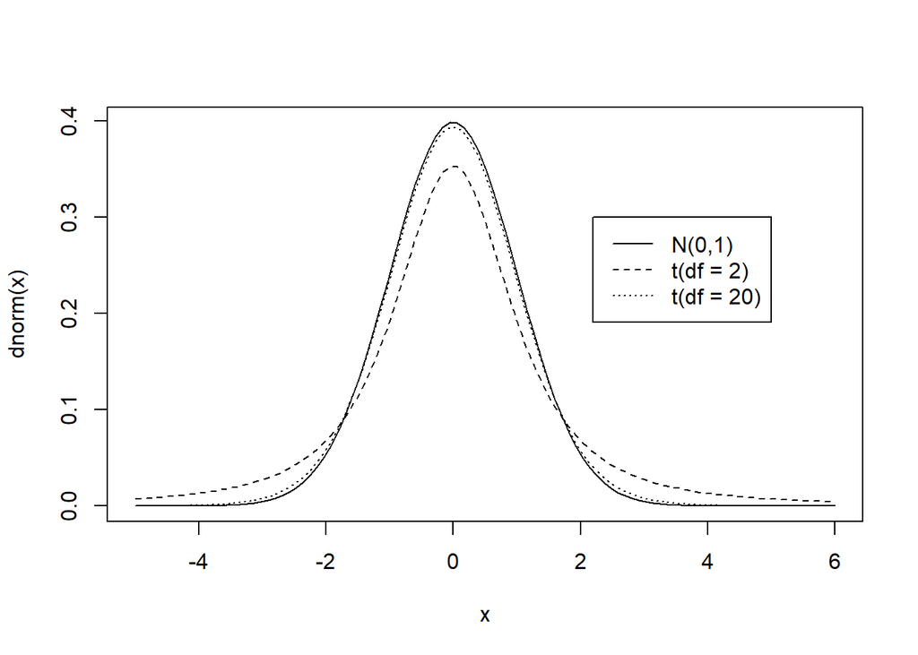

```r
curve(dnorm(x), xlim = c(-5, 6))
curve(dt(x, df = 2), lty = 2, add = TRUE)
curve(dt(x, df = 20), lty = 3, add = TRUE)
legend(2.2, 0.3, c("N(0,1)", "t(df = 2)", "t(df = 20)"), lty = c(1, 2, 3))
```

Die Quantile der t-Verteilung sind betragsmäßig **immer größer** als die korrespondierenden Quantile von $N(0,1)$. Der Unterschied wird aber für zunehmende df kleiner.

```r
qt(0.975, df = 2)  # 97.5%-Quantil der t-Verteilung mit df = 2
```

```
## [1] 4.3027
```

```r
qt(0.975, df = 20) # 97.5%-Quantil der t-Verteilung mit df = 20
```

```
## [1] 2.086
```

```r
qt(0.975, df = 50) # 97.5%-Quantil der t-Verteilung mit df = 50
```

```
## [1] 2.0086
```

### Central Limit Theorem (CLT)

#### Qualitative Daten

Unter bestimmten Annahmen (vgl. unten) gilt für den Stichprobenanteilswert:

$H \sim N(p,\sqrt{\frac{p(1-p)}{n}})$

Für den standardisierten Stichprobenanteilswert gilt dann:

$\frac{H-p}{\sqrt{\frac{p(1-p)}{n}}} \sim N(0,1)$

mit $p$ als wahrer Anteilswert in der Grundgesamtheit.

**Annahmen** des CLT: 1) Unabhängigkeit, 2) große Stichprobe.

Die Gültigkeit der Annahmen wird mit drei **Bedingungen** geprüft: 1) Zufallsstichprobe (sichert Unabhängigkeit), 2) beim Ziehen ohne Zurücklegen muss ein kleiner Auswahlsatz mit $n/N \leq 0.05$ vorliegen (sichert Unabhängigkeit, weil $h$ konstant, vgl. Exkurs), 3) große Stichprobe: $np \geq 10$ und $n(1-p) \geq 10$.

#### Quantitative Daten

Unter bestimmten Annahmen (vgl. unten) gilt für den Stichprobenmittelwert:

$\bar{X} \sim N(\mu,\frac{\sigma}{\sqrt{n}})$

Für den standardisierten Stichprobenmittelwert gilt dann:

$\frac{\bar{X}-\mu}{\frac{\sigma}{\sqrt{n}}} \sim N(0,1)$

mit $\mu$ als wahrer Mittelwert der Grundgesamtheit und $\sigma$ als wahre Standardabweichung der Grundgesamtheit.

Dies gilt **unabhängig von der Verteilung des Merkmals** in der Grundgesamtheit.

Die Bedingungen und Annahmen sind wie oben, nur für die Stichprobengröße gilt nun $n > 30$. Später sind Modifikationen nötig, wenn $\sigma$ unbekannt ist und geschätzt werden muss.

Betrachten wir ein Beispiel zur Anwendung des CLT für qualitative Daten. Der wahre Anteil für die Zustimmung zu einem Projekt in der Grundgesamtheit sei p = 0.4. Wir ziehen eine Zufallsstichprobe der Größe n = 800. Wie groß sind die Wahrscheinlichkeiten: a) $P(h < 0.35)$ und b) $P(0.37 < h < 0.43)$? Wir können hier Stetigkeit unterstellen, d.h., die Punktwahrscheinlichkeit ist näherungsweise Null.

Lösung a): Wir wissen, dass gemäß CLT der Stichprobenanteil einer $N(0.4, \sqrt{0.24/800})$-Verteilung folgt.

Der Plot der Dichte ist:

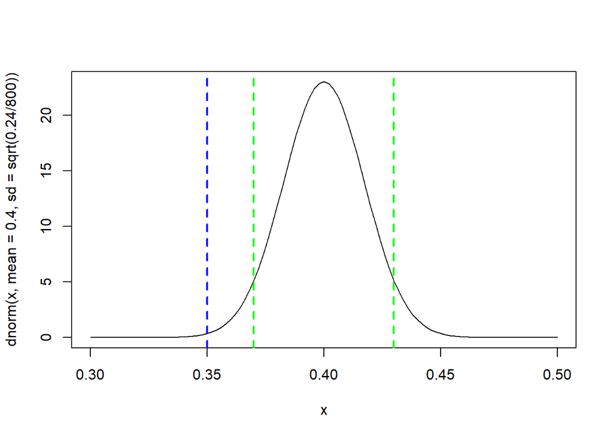

```r
curve(dnorm(x, mean = 0.4, sd = sqrt(0.24/800)), xlim = c(0.3, 0.5))
abline(v = 0.35, lty = 2, lwd = 2, col = "blue")
abline(v = c(0.37, 0.43), lty = 2, lwd = 2, col = "green")
```

Wir suchen für a) die Fläche unterhalb der Dichte $f$ links der vertikalen blauen Linie. Die Berechnung über die Verteilungsfunktion $F$ ist:

```r
pnorm(0.35, mean = 0.4, sd = sqrt(0.24/800))
```

```
## [1] 0.0019462
```

Damit ist die gesuchte Wahrscheinlichkeit 0.195%.

Wir können für b) von der gleichen Verteilungsannahme wie in a) ausgehen. Wir suchen für b) die Fläche unterhalb der Dichte $f$ zwischen den vertikalen grünen Linien.

Berechnung über die Verteilungsfunktion $F$:

```r
pnorm(0.43, mean = 0.4, sd = sqrt(0.24/800)) - pnorm(0.37, mean = 0.4, sd = sqrt(0.24/800))
```

```
## [1] 0.91674
```

Die gesuchte Wahrscheinlichkeit ist 91.7%.

#### Exkurs: Stochastische Unabhängigkeit

Stochastische Unabhängigkeit für zwei Ereignisse $A$ und $B$ ist definiert als $P(A|B)=P(A)$. Das bedeutet, dass die Wahrscheinlichkeit für $A$ unter der Bedingung, dass $B$ eingetreten ist, gleich der unbedingten Wahrscheinlichkeit für $A$ ist. Mit anderen Worten: Ob $B$ eintritt oder nicht, hat keinen Einfluss auf $A$. Die Eintrittswahrscheinlichkeit für $A$ ist also unabhängig von $B$ und damit konstant. Dieses Konzept wird nun bei der Ziehung von Stichproben aus einer Grundgesamtheit genutzt. Hierbei wird das Ziehen **mit Zurücklegen** und **ohne Zurücklegen** unterschieden.

Wir betrachten eine kleine Grundgesamtheit ($N=10$) mit fünf roten ($R$) und fünf schwarzen ($S$) Kugeln. Wir ziehen eine Zufallsstichprobe vom Umfang $n=3$. Mit Zurücklegen gilt stochastische Unabhängigkeit und die Wahrscheinlichkeit für „rot“ beim 1., 2. und 3. Zug ist $P(R_1)=P(R_2)=P(R_3)=0.5$. Die Wahrscheinlichkeit für “rot” ist also konstant und unbeeinflusst von Ereignissen vor dem Zufallszug. Ohne Zurücklegen ist dies nicht der Fall, denn die Eintrittswahrscheinlichkeiten im 2. und 3. Zug sind abhängig von den Ereignissen davor. So gilt z.B. für die Wahrscheinlichkeit, „rot“ beim 2. Zug zu beobachten, wenn beim 1. Zug bereits „rot“ beobachtet wurde: $P(R_2|R_1)=4/9$. Entsprechend gilt $P(R_3|R_1 \cap R_2)=3/8$. In diesem Fall ist der Auswahlsatz relativ groß ($n/N=0.3$), so dass wir nicht davon ausgehen können, dass Ziehen ohne Zurücklegen näherungsweise die gleichen Ergebnisse bringt wie Ziehen mit Zurücklegen. Betrachten wir nun eine große Grundgesamtheit mit $N=10000$ mit 5000 roten und 5000 schwarzen Kugeln. Wir ziehen wieder eine Stichprobe vom Umfang $n=3$. Im Fall ohne Zurücklegen sind jetzt die Eintrittswahrscheinlichkeiten im 2. und 3. Zug praktisch unabhängig von den Ereignissen davor, d.h., hier ist Unabhängigkeit gegeben. So gilt z.B. $P(R_2|R_1)=4999/9999\approx0.5$ und $P(R_3|R_1 \cap R_2)=4998/9998\approx0.5$. In diesem Fall ist der Auswahlsatz relativ klein ($n/N=0.0003$), so dass wir davon ausgehen können, dass auch beim Ziehen ohne Zurücklegen näherungsweise stochastische Unabhängigkeit gilt.

Stochastische Unabhängigkeit der Beobachtungen ist für die induktive Statistik (auch Inferenzstatistik) von großer Bedeutung. Da in der Praxis Stichproben i.d.R. ohne Zurücklegen gewonnen werden, ist es üblich durch die Wahl eines kleinen Auswahlsatzes die stochastische Unabhängigkeit und damit die Konstanz der Eintrittswahrscheinlichkeit sicherzustellen.

#### Exkurs: Simulationen zur Veranschaulichung des CLT

Unter einer Simulation verstehen wir die kontrollierte Wiederholung eines Zufallsexperiments. Benötigt wird hier der Befehl `sample()` zur Ziehung von Stichproben mit einer bestimmten Zahl an Elementen (`size`) aus x mit oder ohne Zurücklegen (`replace`). Betrachten wir als Beispiel: 6 Mal Würfeln ohne und mit Zurücklegen.

```r
set.seed(4); sample(1:6, size = 6, replace = FALSE) # 6 Mal Würfeln ohne Zurücklegen
```

```
## [1] 3 6 5 4 2 1
```

```r
set.seed(4); sample(1:6, size = 6, replace = TRUE) # 6 Mal Würfeln mit Zurücklegen
```

```
## [1] 3 3 3 4 3 6
```

Nun wollen wir uns den CLT für qualitative Daten veranschaulichen. Wir nehmen p = 0.4 (wahrer Anteilswert in der Grundgesamtheit) an. Zunächst definieren wir uns eine Grundgesamtheit (GG) mit N = 1 Mio.

```r
rep(1, 10) # Wiederholung von Werten => Die "1" wird 10 Mal wiederholt
```

```
##  [1] 1 1 1 1 1 1 1 1 1 1
```

```r
GG <- c(rep(1, 400000), rep(0, 600000)); table(GG)
```

```
## GG
##      0      1
## 600000 400000
```

Wir ziehen mit Stichprobengröße n = 100 eine Zufallsstichprobe aus GG und berechnet den Stichprobenanteilswert.

```r
set.seed(4); mean(sample(GG, size = 100, replace = TRUE))
```

```
## [1] 0.44
```

Das o.g. Zufallsexperiment wollen wir nun 1000 Mal durchführen.

```r
TEST = c() # Definiere leere Variable TEST
```

Wir erzeugen mit `for()` einen “Loop” (Schleife).

```r
for(i in 1:1000) {set.seed(i); TEST[i] = mean(sample(GG, size = 100, replace = TRUE))}
TEST[1:6] # die ersten 6 Werte für den Stichprobenanteil
```

```
## [1] 0.38 0.47 0.39 0.44 0.41 0.45
```

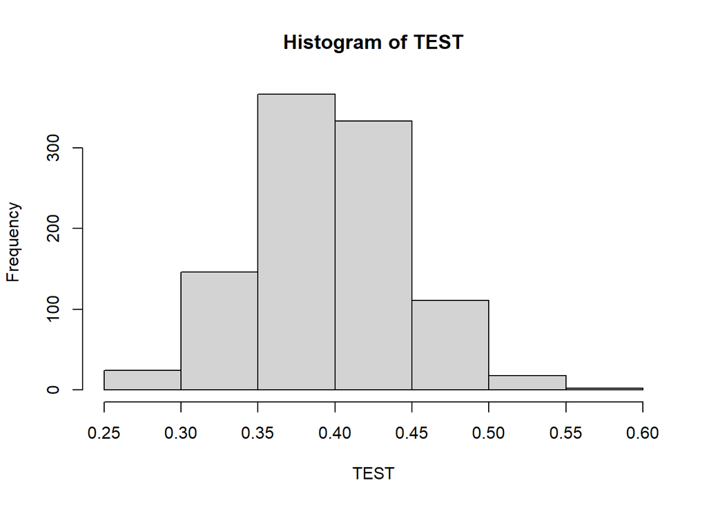

```r
hist(TEST)
```

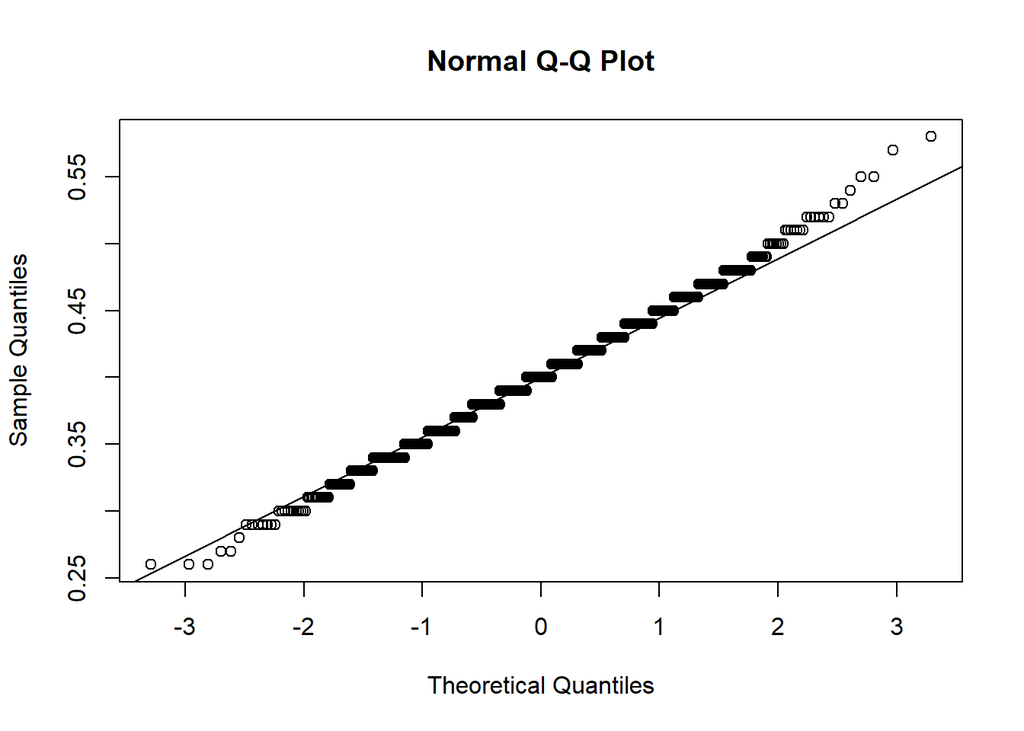

```r
qqnorm(TEST); qqline(TEST)
```

Mit der Darstellung von $f$ und $F$ können wir zeigen, dass der Stichprobenanteilswert näherungsweise einer Normalverteilung nach CLT folgt. Man sieht im Plot von $F$ aber auch, dass bestimmte Werte häufiger beobachtet werden als andere. Wir prüfen Lage- und Streuungsmaß:

```r
mean(TEST) # sollte p = 0.4 sein
```

```
## [1] 0.40119
```

```r
sd(TEST) # sollte sqrt(pq/n) = sqrt(0.4*0.6/100) = 0.049 sein
```

```
## [1] 0.048425
```

Betrachten wir das Beispiel zur Anwendung des CLT für qualitative Daten a) oben. Hier war p = 0.4 und n = 800. Gesucht ist die Wahrscheinlichkeit $P(h < 0.35)$. Die Vorgehensweise ist analog zu oben (nur die GG ist größer und wir wiederholen den Zufallszug 100000 Mal). Das Resultat ist OK.

```r
GG <- c(rep(1, 4000000), rep(0, 6000000))
TEST = c() # Definiere leere Variable TEST
for(i in 1:100000) {set.seed(i); TEST[i] = mean(sample(GG, size = 800, replace = TRUE))}
TEST[1:6] # die ersten 6 Werte für den Stichprobenanteil
```

```
## [1] 0.39000 0.39250 0.37375 0.42000 0.38000 0.40250
```

```r
prop.table(table(TEST < 0.35)) # sollte approx. 0.00195 sein
```

```
##
##  FALSE   TRUE
## 0.9982 0.0018
```

Nun wollen wir uns den CLT für quantitative Daten veranschaulichen. Wir generieren wieder eine Grundgesamtheit (GGq) mit 1 Mio. Werten. Vorab: Wir ziehen 10 Zufallszahlen aus dem Intervall [2,8].

```r
runif(10, min = 2, max = 8) # ziehe 10 Mal aus [2,8]
```

```
##  [1] 5.1546 6.6073 4.5036 6.4950 4.6107 3.9574 2.1220 7.3524 2.6687 6.1147
```

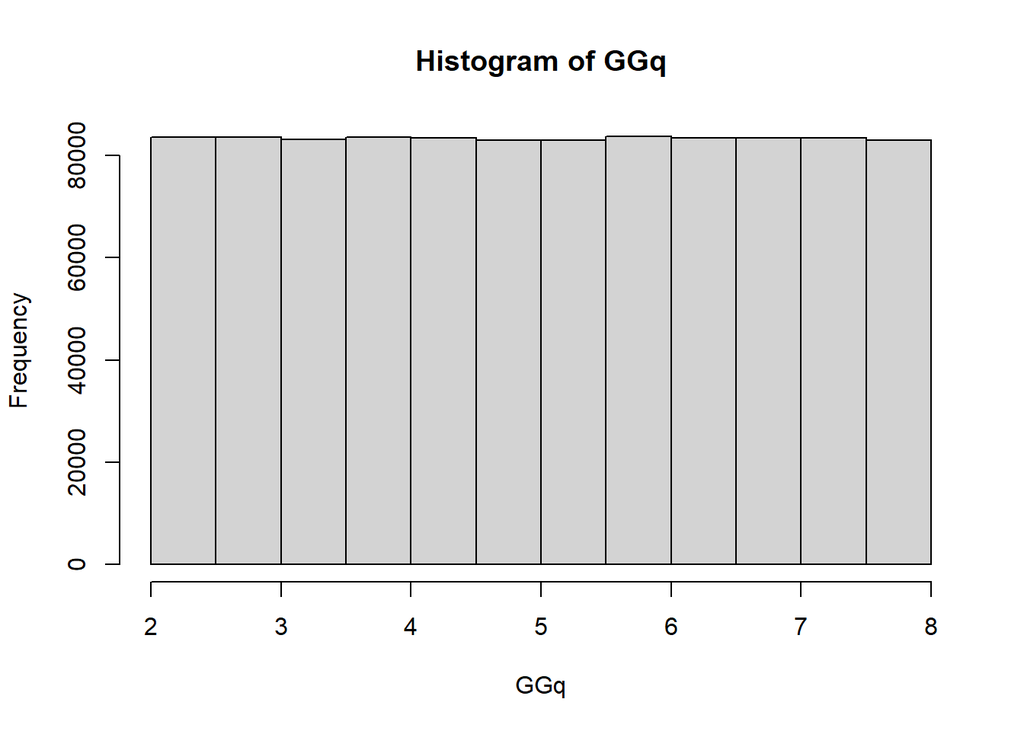

```r
set.seed(4); GGq <- runif(1000000, min = 2, max = 8) # Erzeuge GGq
hist(GGq)
```

```r
mean(GGq); sd(GGq) # wahre Lage- und Streuungsmaße GGq (mu, sigma)
```

```
## [1] 4.999
```

```
## [1] 1.7321
```

Aus dieser GGq ziehen wir jetzt wieder eine Zufallsstichprobe mit n = 100 und berechnen den Stichprobenmittelwert.

```r
mean(sample(GGq, size = 100, replace = TRUE)) # eine Zufallsstichprobe
```

```
## [1] 4.8205
```

```r
TEST2 <- c()
for(i in 1:1000) {set.seed(i); TEST2[i] <- mean(sample(GGq, size = 100, replace = TRUE))}
TEST2[1:3]              # die ersten drei Stichprobenmittelwerte
```

```
## [1] 5.4339 5.1072 4.6206
```

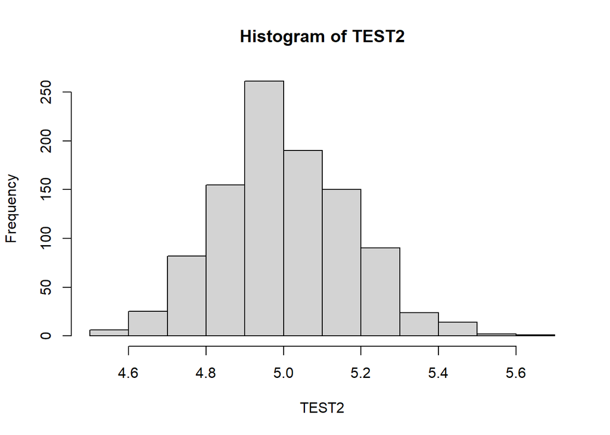

```r
hist(TEST2)
```

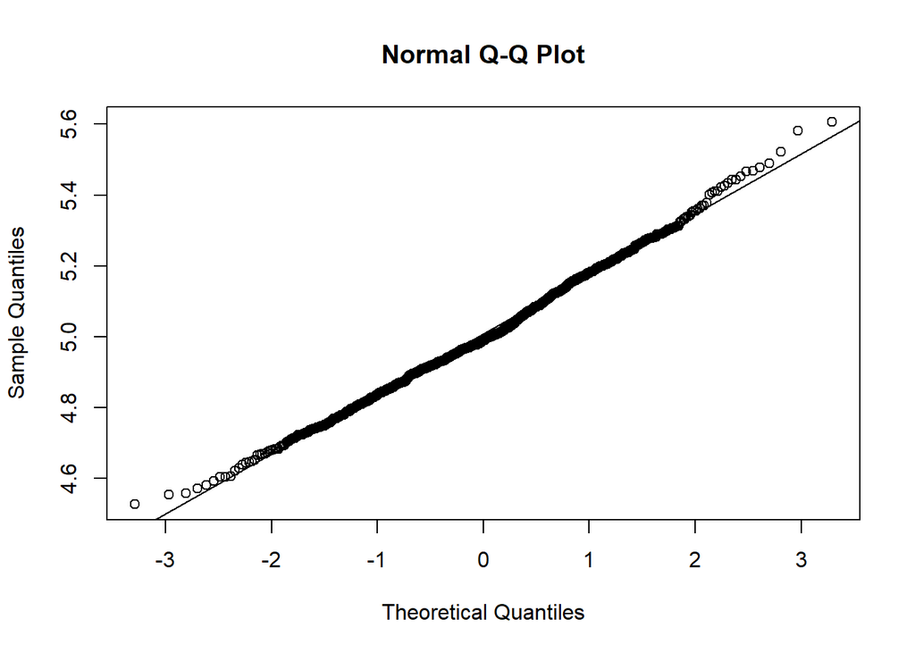

```r
qqnorm(TEST2); qqline(TEST2)
```

Wir betrachten Mittelwert und Standardabweichung von TEST2. Der Mittelwert sollte sein 4.999038 (vgl. oben).

```r
mean(TEST2) # nah am wahren Wert
```

```
## [1] 5.0027
```

Die Standardabweichung des Stichprobenmittels sollte sein $\sigma/\sqrt{n}$, wobei $\sigma$ die wahre Standardabweichung in der Grundgesamtheit ist und $n$ die Stichprobengröße. Wir sollten also erhalten 1.732097/10 = 0.1732097.

```r
sd(TEST2) # nah am wahren Wert
```

```
## [1] 0.17074
```

## Inferenz für qualitative Daten (alle Module)

In diesem Abschnitt werden wir uns mit Methoden der Inferenzstatistik (auch induktive Statistik) für qualitative Daten beschäftigen. Dabei geht es zunächst darum, was wir aus den Stichprobenbeobachtungen über den unbekannten wahren Anteilswert $p$ in der Grundgesamtheit schließen können. Im Anschluss wird erläutert, wie man testen kann, ob in einer Grundgesamtheit ein qualitatives Merkmal einer bestimmten Verteilung folgt und ob zwei qualitative Merkmale unabhängig voneinander sind.

### Konfidenzintervall (KI) für $p$

#### Herleitung

Nach dem CLT gilt näherungsweise:

$H \sim N(p,\sqrt{\frac{p(1-p)}{n}})$ und $\frac{H-p}{\sqrt{\frac{p(1-p)}{n}}} \sim N(0,1)$

Wir können also für den standardisierten Stichprobenanteilswert näherungsweise die Wahrscheinlichkeit definieren, dass dieser Wert in ein um 0 symmetrisches Intervall $[-z,+z]$ fällt. Diese Wahrscheinlichkeit ist:

$P(-z < \frac{H - p}{\sqrt{\frac{p(1-p)}{n}}} < +z) \approx F_{St}(+z) - F_{St}(-z)$

Wir treffen nun folgende Annahmen:

1. Wir verwenden den Standardfehler (Standard Error) $SE =\sqrt{\frac{h(1-h)}{n}}$ als Näherung für $\sqrt{\frac{p(1-p)}{n}}$, wenn die Stichprobe hinreichend groß ist (vgl. unten).
2. Die Wahrscheinlichkeit, mit der der standardisierte Stichprobenanteil in das Intervall $[-z,+z]$ fällt, sei $1-\alpha$ und wird “Vertrauenswahrscheinlichkeit” (confidence level) genannt.
3. $z_{[\alpha/2]} = -z_{[1 - \alpha/2]}$ wegen Symmetrie der $N(0,1)$-Verteilung.

Die Wahrscheinlichkeitsaussage ist dann

$P(z_{[\alpha/2]} < \frac{H - p}{SE} < z_{[1 - \alpha/2]}) \approx 1 - \alpha$

Graphisch lässt sich diese Wahrscheinlichkeitsaussage folgendermaßen darstellen.

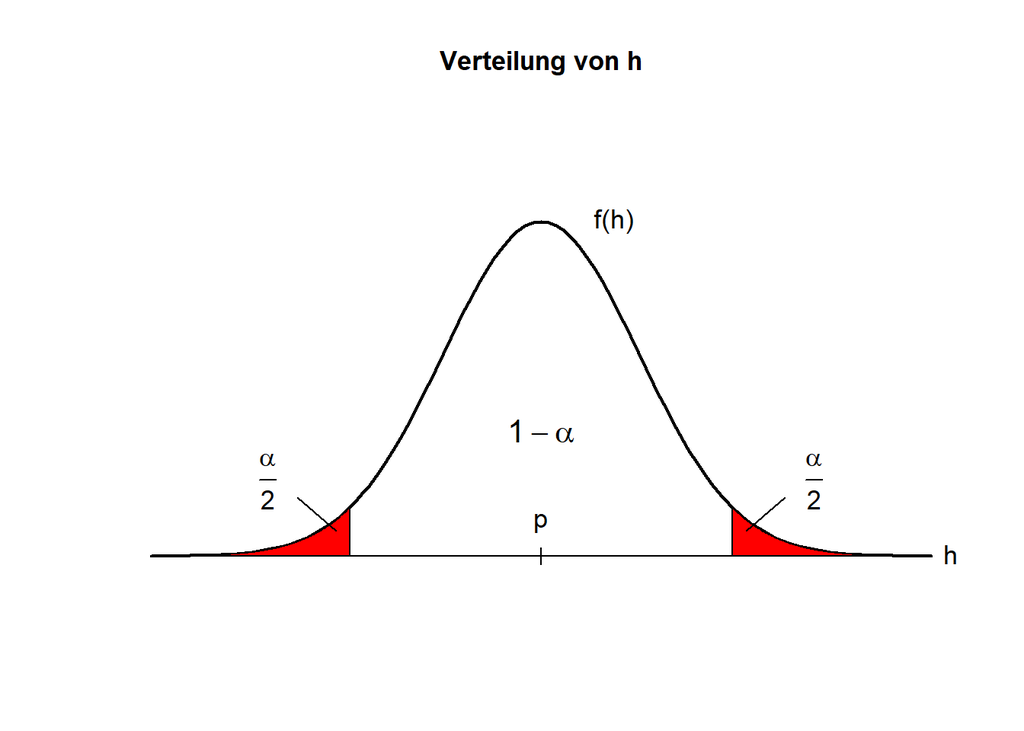

```r
cord.x4 <- c(-4,seq(-4,-1.96,0.01),-1.96)
cord.y4 <- c(0,dnorm(seq(-4,-1.96,0.01)), 0)
cord.x5 <- c(1.96,seq(1.96,4,0.01),4)
cord.y5 <- c(0,dnorm(seq(1.96,4,0.01)),0)
curve(dnorm(x),xlim=c(-4,4), ylim = c(-0.01, 0.5), axes = F,
      main = "Verteilung von h", cex.main = 1.1,
xlab = "", ylab = "", lwd = 2, cex.lab = 1.1)
polygon(cord.x4,cord.y4,col='red')
polygon(cord.x5,cord.y5,col='red')
segments( -4, 0,  4, 0)
segments( 0, -0.01,  0, 0.01)
text(2.8, 0.09, expression(frac(alpha,2)), cex = 1.1)
text(-2.8, 0.09, expression(frac(alpha,2)), cex = 1.1)
text(0, 0.04, expression(p), cex = 1.1)
text(0, 0.15, expression(1 - alpha), cex = 1.3)
text(0.75, 0.4, expression(paste("f(", h, ")")), cex = 1.1)
text(4.2, 0.003, expression(h), cex = 1.1)
segments(2.5, 0.07, 2.1, 0.03)
segments(-2.5, 0.07, -2.1, 0.03)
```

Die Residualwahrscheinlichkeit $\alpha$ (auch als “Irrtumswahrscheinlichkeit” bezeichnet) teilt sich zu gleichen Teilen mit $\alpha/2$ auf den rechten und linken Rand der symmetrischen Verteilung auf.

Wir können dann die Wahrscheinlichkeitsaussage oben so umformen, dass der wahre Anteilswert $p$ in der Mitte der Wahrscheinlichkeitsaussage steht. Anstelle des Stichprobenanteils als Variable ($H$) schreiben wir nun für den beobachteten Stichprobenanteil $h$. Die Idee des Intervalls ist: Wenn wir - basierend auf dem CLT - von $p$ etwas über $h$ lernen können, dann können wir das Ganze auch umdrehen und von $h$ etwas über $p$ lernen. Die umgeformte Wahrscheinlichkeitsaussage ist dann:

$P(h - z_{[1 - \alpha/2]}SE < p < h + z_{[1 - \alpha/2]}SE) \approx 1 - \alpha$

Das $(1-\alpha)$-**Konfidenzintervall** für das wahre $p$ in der Grundgesamtheit ist dann:

$KI{(1-\alpha)}_p = h \pm z_{[1-\alpha/2]}SE = h \pm ME$

mit $ME = z_{[1-\alpha/2]}SE$ und $SE = \sqrt{\frac{h(1 - h)}{n}}$

Der Term $ME$ wird als “absoluter Fehler” oder “Margin of Error” bezeichnet. Der $ME$ beträgt die Hälfte der Länge des KIs.

Die **Annahmen** zur Anwendung des KI sind: (1) Unabhängigkeit und (2) große Stichprobe.

**Bedingungen** für (1):

- Zufallsstichprobe
- bei Ziehen ohne Zurücklegen muss ein kleiner Auswahlsatz vorliegen mit $n/N \leq 0.05$

und für (2):

- $nh \geq 10$ und $n(1-h) \geq 10$

Diese Annahmen und Bedingungen sind - leicht modifiziert - auch beim Hypothesentest für $p$ (vgl. unten) zu prüfen.

#### Beispiele

Betrachten wir zunächst Bsp. 9.10 im Lehrbuch (S. 201). Ein Industrieunternehmen produziert ein Massenprodukt. Aus einer Grundgesamtheit von 50000 Einheiten des Produkts wurde eine Zufallsstichprobe vom Umfang n = 600 gezogen. In der Stichprobe befanden sich 68 unbrauchbare Produkte.

```r
n <- 600    # Stichprobengröße
h <- 68/600 # Ausschussanteil in der Stichprobe
```

Wir wollen ein 90%-KI für den wahren Ausschussanteil in der Grundgesamtheit berechnen.

1. Methode: “per Hand” mit Hilfe der Formel oben.

```r
z <- qnorm(0.95); z           # z-Wert für alpha = 0.1
```

```
## [1] 1.6449
```

```r
SE <- sqrt(h*(1 - h)/n); SE   # SE
```

```
## [1] 0.012941
```

```r
CI_low <- h - z*SE; CI_up <- h + z*SE
CI_low; CI_up                 # untere und obere Grenze des KI
```

```
## [1] 0.092047
```

```
## [1] 0.13462
```

```r
ME <- (CI_up - CI_low)/2; ME  # Margin of Error (abs. Fehler)
```

```
## [1] 0.021287
```

Häufig findet man folgende Interpretation des KI: Mit einer Wahrscheinlichkeit von 90% liegt der wahre, aber unbekannte Anteilswert für Ausschuss zwischen 9.2% und 13.5%. Das Problem ist aber, dass es nur **einen** wahren Anteilswert $p$ gibt. Daher ist es nicht richtig, eine Wahrscheinlichkeitsaussage für ein einzelnes KI zu formulieren. Entweder $p$ liegt im KI oder eben nicht.

Die richtige Interpretation ist: Wenn man 100 Stichproben nach dieser Methode ziehen würde, würde man 100 unterschiedliche KIs erhalten. Von diesen 100 KIs werden im Mittel 90 den wahren Anteilswert beinhalten und 10 nicht. Unser KI, [9.2%, 13.5%], ist eines dieser 100 KIs. Das **Vertrauen** (“confidence”) bezieht sich also nicht auf das einzelne KI, sondern auf die **Methode**, solche Intervalle zu konstruieren.

Kürzer: Wir können zu 90% darauf vertrauen, dass ein nach dieser Methode erzeugtes Intervall den wahren Ausschussanteil in der Grundgesamtheit beinhaltet. Unser KI, [9.2%, 13.5%], ist ein solches Intervall.

2. Methode: mit `prop.test()`

```r
prop.test(68, 600, conf.level = 0.90) # [0.0930, 0.1373], ME = 0.02215
```

```
##
##  1-sample proportions test with continuity correction
##
## data:  68 out of 600, null probability 0.5
## X-squared = 357, df = 1, p-value <2e-16
## alternative hypothesis: true p is not equal to 0.5
## 90 percent confidence interval:
##  0.092997 0.137276
## sample estimates:
##       p
## 0.11333
```

Die Ausgabe enthält einige Informationen, die uns (noch) nicht interessieren. Hier ist relevant die Ausgabe des KI (`90 percent confidence interval`) und der Punktschätzung für $p$ (`sample estimates`, Stichprobenanteilswert $h$). Es gibt eine kleine (und vernachlässigbare) Abweichung zum Ergebnis oben, da R zusätzlich noch mit einer Stetigkeitskorrektur rechnet.

#### Trade-off zwischen Präzision und Sicherheit

Wovon ist die Breite des KIs, also die Präzision der Aussage, abhängig? Aus der Formel zur Berechnung des KI ergibt sich, dass es zwei Optionen gibt, zu einer präziseren Aussage (also zu einem schmaleren KI) zu gelangen:

1. Reduzierung der Vertrauenswahrscheinlichkeit: Ein kleineres $1 - \alpha$ führt zu einem schmaleren KI, da mit steigendem $\alpha$ der Wert $z_{[1-\alpha/2]}$ sinkt. So ist z.B. für $1-\alpha=0.90$ der z-Wert $z_{[0.95]}=1.645$ und für $1-\alpha=0.95$ ist der z-Wert $z_{[0.975]}=1.96$. Werte unter 90% für die Vertrauenswahrscheinlichkeit sind unüblich.
2. Größere Stichprobe: Ein höheres $n$ reduziert den Standardfehler und damit auch den Margin of Error.

Betrachten wir zu (2) Bsp. 9.10 und verdoppeln die Stichprobe von 600 zu 1200. Um einen sinnvollen Vergleich zu ermöglichen, muss auch die Zahl der Erfolge verdoppelt werden (von 68 zu 136). Wir nutzen wieder `prop.test()`.

```r
prop.test(2*68, 2*600, conf.level = 0.90) # [0.0988, 0.1297], ME = 0.01545
```

```
##
##  1-sample proportions test with continuity correction
##
## data:  2 * 68 out of 2 * 600, null probability 0.5
## X-squared = 716, df = 1, p-value <2e-16
## alternative hypothesis: true p is not equal to 0.5
## 90 percent confidence interval:
##  0.098751 0.129703
## sample estimates:
##       p
## 0.11333
```

Das KI wird schmaler (der ME wird um ca. 30% kleiner), aber der Effekt ist relativ klein (immerhin wurde $n$ verdoppelt). Dies liegt daran, dass die Quadratwurzel im $SE$ den Effekt der Vergrößerung von $n$ “bremst” (eine Verdopplung von $n$ reduziert den ME auf das $1/{\sqrt(2)}$-fache).

Punkt (1) oben macht deutlich: Es gibt einen **trade-off** (auch “Abwägen” oder “Zielkonflikt”) zwischen der **Präzision** der Aussage (Breite des KI) und der **Sicherheit** der Aussage (Vertrauen in das KI). Eine höhere Sicherheit bzgl. der Aussage über $p$ geht einher mit geringerer Präzision und umgekehrt. Mit anderen Worten: Wir müssen also einen “Preis” (geringeres Präzision) für höhere Sicherheit zahlen. Das ist das fundamentale Problem der schließenden Statistik. Glücklicherweise können wir oft mit Aussagen ausreichend präzise (z.B. $ME < 0.05$) und zugleich relativ sicher (z.B. mit $1-\alpha=0.95$) sein.

Im Beispiel oben erhöhen wir $1-\alpha$ auf 99%.

```r
prop.test(68, 600, conf.level = 0.99) # relativ breites KI
```

```
##
##  1-sample proportions test with continuity correction
##
## data:  68 out of 600, null probability 0.5
## X-squared = 357, df = 1, p-value <2e-16
## alternative hypothesis: true p is not equal to 0.5
## 99 percent confidence interval:
##  0.083422 0.151911
## sample estimates:
##       p
## 0.11333
```

Zurück zur Aufgabe oben: In einer Pressemitteilung würde das o.g. KI folgendermaßen dargestellt werden: Der Ausschussanteil ist 11.3% +/- 2.1% bei n = 600. Man gibt also den Stichprobenanteilswert $h$ und den Margin of Error sowie $n$ an. Aus diesen Angaben kann mit der Formel für das KI auch (näherungsweise) der $z_{[1-\alpha/2]}$-Wert berechnet werden und damit ist klar, dass bei $z_{[1-\alpha/2]} = z_{[0.95]} = 1.645$ ein 90%-KI berechnet wurde.

```r
ME <- 0.021                           # Margin of Error ist 2.1%
z <- ME/sqrt(0.113*(1 - 0.113)/600)   # Berechnung von z
z # z ist approx. 1.645 => z[0.95] => 1 - alpha = 0.9
```

```
## [1] 1.6248
```

### Hypothesentest für $p$

#### Schrittfolge

Wir wollen eine Hypothese über den unbekannten Anteilswert $p$ in der Grundgesamtheit testen. Dazu nehmen wir die Hypothese als **wahr** an und vergleichen die Stichprobeninformation mit dem, was man unter Gültigkeit der Hypothese erwarten kann. Gibt es einen großen Unterschied zwischen der Erwartung basierend auf der Hypothese und Stichprobeninformation, verwerfen wir die Hypothese.

Wir werden im Folgenden mit folgender Schrittfolge für einen Hypothesentest arbeiten:

*1) Hypothesen aufstellen und Signifikanzniveau (maximale Wahrscheinlichkeit für Fehler 1. Art, $\alpha$) festlegen.* Die Ausgangshypothese wird als **Nullhypothese** $H_0$ bezeichnet. $H_0$ wird als wahr angenommen. Das eigentlich interessante Ergebnis wird i.d.R. in der **Alternativhypothese** $H_A$ “versteckt”. Ziel ist letztlich die Ablehnung der Nullhypothese und die Akzeptanz der Alternative. Die Ablehnung von $H_0$ ist aber nur möglich, wenn wir “begründete Zweifel” an der Nullhypothese haben. Ein Hypothesentest stellt quasi Regeln auf, um zu überprüfen, ob solche begründeten Zweifel vorliegen oder nicht.

Es werden zweiseitige und einseitige Tests unterschieden (je nach Richtung der $H_A$):

- zweiseitig: $H_0$: $p = p_0$ vs. $H_A: p \neq p_0$ (Abweichung von $p_0$ in beide Richtungen möglich)
- oberseitig: $H_0: p = p_0$ vs. $H_A: p > p_0$ (Abweichung von $p_0$ nur nach oben möglich)
- unterseitig: $H_0: p = p_0$ vs. $H_A: p < p_0$ (Abweichung von $p_0$ nur nach unten möglich)

Bei einem Hypothesentest sind zwei Fehler möglich (vgl. folgende Tabelle). Man kann eine wahre Nullhypothese verwerfen (Fehler 1. Art, auch als $\alpha$-Fehler oder “false positive” bezeichnet) oder eine falsche Nullhypothese nicht verwerfen (Fehler 2. Art, $\beta$-Fehler, “false negative”).

Fehler beim Hypothesentest

|  | $H_0$ ist wahr | $H_0$ ist nicht wahr |
| --- | --- | --- |
| verwerfe $H_0$ | Fehler 1. Art ($\alpha$-Fehler) | richtige Entscheidung |
| verwerfe $H_0$ nicht | richtige Entscheidung | Fehler 2. Art ($\beta$-Fehler) |

Betrachten wir als Beispiel eine Gerichtsverhandlung. Die Nullhypothese ist hier “der Angeklagte ist unschuldig”. Wenn die Nullhypothese wahr ist und der Angeklagte wird verurteilt, begeht man einen Fehler 1. Art. Wird dagegen ein eigentlich Schuldiger nicht verurteilt, liegt ein Fehler 2. Art vor. Welcher Fehler ist wichtiger?

In der Medizin ist die Nullhypothese i.d.R. “der Wirkstoff hat keinen Effekt”. Wenn die Nullhypothese wahr ist und man kommt dennoch zum Ergebnis, dass es einen Effekt des Wirkstoffs gibt, begeht man einen Fehler 1. Art (daher “false positive”). Wird dagegen ein eigentlich existierender Effekt nicht entdeckt, liegt ein Fehler 2. Art vor (daher “false negative”).

Beim Hypothesentest in der Praxis liegt der Fokus auf dem **Fehler 1. Art**. Dieser soll ein bestimmtes Niveau $\alpha$ (auch “Signifikanzniveau” genannt, i.d.R. 0.05) nicht überschreiten. Man beachte, dass man den Fehler 1. Art sehr wohl auf Null minimieren könnte (wenn $H_0$ nie verworfen wird), dann aber der Fehler 2. Art 1 bzw. 100% werden würde, wenn $H_0$ falsch ist. Dies wäre keine sinnvolle Teststrategie. Man wird also nicht ohne Fehler 1. und 2. Art auskommen.

Stattdessen geht man folgendermaßen vor: In der Zufallsstichprobe wird ein Stichprobenanteil $h$ beobachtet. Wir lehnen dann $H_0$ nur ab, wenn die Abweichung zwischen $h$ und dem als wahr angenommenen Wert aus der Null, $p_0$, bedeutsam (“statistisch signifikant”) ist. Der Fehler 1. Art soll dabei ein bestimmtes Signifikanzniveau nicht überschreiten. Das typische Signifikanzniveau ist $\alpha = 0.05$ (seltener 0.01 oder 0.10).

Die exakte Wahrscheinlichkeit für den Fehler 1. Art kann bestimmt werden, weil wir gemäß CLT die Verteilung von $h$ kennen (gegeben die Annahme: $H_0$ ist wahr). Die Berechnung des Fehlers 2. Art ist i.d.R. deutlich schwieriger, weil es viele denkbare falsche $H_0$-Werte gibt (vgl. Exkurs bzw. Lehrbuch).

*2) Festlegung der Testvariable ($Z$) und Testverteilung.* Gemäß CLT folgt $H$ einer $N(p_0, \sqrt{\frac{p_0(1-p_0)}{n}})$-Verteilung, denn $H_0$ wurde als wahr angenommen. Damit folgt $\frac{H - p_0}{\sqrt{\frac{p_0(1-p_0)}n}}$ einer $N(0,1)$-Verteilung und $Z$ (standardnormalverteilte Zufallsvariable) kann als **Testvariable** verwendet werden. Wenn der empirische Wert von $Z$ (mit $z$ bzw. als “Prüfgröße” bezeichnet) weit weg von Null liegt, gibt es eine bedeutsame bzw. “statistisch signifikante” Abweichung zwischen $h$ und $p_0$. Die Annahmen und Bedingungen (diese sind identisch zum $(1-\alpha)$-KI für $p$ mit einer Ausnahme: für eine große Stichprobe muss gelten: $np_0 \geq 10$ und $n(1-p_0) \geq 10$) sind zuvor zu prüfen.

*3) Berechnung der Prüfgröße $z$ und des p-value.* Der Wert der **Prüfgröße** $z$ (so wird der empirische Wert der Testvariable $Z$ bezeichnet) berechnet sich folgendermaßen:

$z = \frac{h - p_0}{\sigma}$ mit $\sigma = \sqrt{\frac{p_0(1-p_0)}{n}}$

Achtung: $\sigma$ ist hier kein Standardfehler, sondern eine Standardabweichung, da wir $H_0$ als gültig und somit als wahr unterstellen.

Um zu einer Entscheidung über $H_0$ zu kommen, wird dann der sog. **p-value** berechnet. Der p-value ist die Wahrscheinlichkeit, Daten wie in der Stichprobe oder extremer zu beobachten, wenn $H_0$ wahr ist. Wenn der p-value sehr gering und kleiner als das Signifikanzniveau $\alpha$ ist, verwerfen wir $H_0$, weil unser Misstrauen gegenüber dieser Hypothese zu groß ist.

Der p-value berechnet sich hier folgendermaßen:

- zweiseitig: p-value = $2(1 - F_{St}(|z|))$
- oberseitig: p-value = $1 - F_{St}(z)$
- unterseitig: p-value = $F_{St}(z) = 1 - F_{St}(|z|)$

mit $F_{St}(z)$ als Verteilungsfunktion von $N(0,1)$.

Ist der p-value hinreichend klein (< $\alpha$) haben wir kein Vertrauen in $H_0$. Wir lehnen dann $H_0$ ab und nehmen $H_A$ an. Mit der Ablehnung von $H_0$ (und damit mit der Akzeptanz von $H_A$) haben wir jedoch nicht gezeigt, dass $H_0$ falsch ist (Sicherheit darüber kann nur eine Totalerhebung bringen). Wir haben nur unsere “begründeten Zweifel” an $H_0$ zum Ausdruck gebracht. Wir haben bei Nicht-Ablehnung von $H_0$ auch nicht gezeigt, dass $H_0$ wahr ist (wir hatten schließlich angenommen, dass die Nullhypothese wahr ist). Man hat dann nur gezeigt, dass man $H_0$ nicht verwerfen kann (und üblicherweise arbeitet man dann weiter mit der Nullhypothese).

*4) Entscheidung und Interpretation.* Die Entscheidung basierend auf dem p-value erfolgt nach der Regel: Ablehnung von $H_0$, wenn p-value < $\alpha$. Alternativ wäre auch eine Entscheidung über den Vergleich der Prüfgröße mit einem, aus dem Signifikanzniveau abgeleiteten, kritischen Wert der Testverteilung möglich (vgl. Lehrbuch). Die Interpretation der Entscheidung über $H_0$ hat im Kontext zu erfolgen (ebenso wie die Interpretation des p-value). Der p-value kann dabei als Indikator für die **Glaubwürdigkeit** von $H_0$ interpretiert werden: Dieser Wert gibt schließlich die Wahrscheinlichkeit an, dass das Stichprobenergebnis oder extremere Werte rein zufällig zustandegekommen sein können, wenn $H_0$ wahr ist. Wenn diese Wahrscheinlichkeit sehr klein ist, spricht das gegen $H_0$ und wir verwerfen.

Der hier erläuterte Test wird auch **Einstichproben-z-Test** (one proportion z-test) genannt.

#### Beispiele

Beispiel 1: Aus früheren Untersuchungen sei bekannt, dass die Kundenzufriedenheit bei 30% liegt. Nach einer “Charmeoffensive” werden 500 zufällig ausgewählte Kunden nach ihrer Zufriedenheit befragt. 35% geben an “zufrieden” zu sein. Hat die “Charmeoffensive” etwas gebracht? Das Signifikanzniveau sei 0.05.

Wir testen hier oberseitig $H_0: p=0.3$ vs. $H_A:p>0.3$, da wir daran interessiert sind zu zeigen, dass die Charmeoffensive einen positiven Effekt hatte. Bevor wir mit den Berechnungen beginnen, prüfen wir, ob die Bedingungen für die Anwendung eines Hypothesentests erfüllt sind: (1) Zufallsstichprobe, (2) kleiner Auswahlsatz mit $n/N \leq 0.05$ und (3) $np_0\geq10$ und $n(1-p_0)\geq10$.

```r
h <- 0.35; n = 500; p0 <- 0.3
SD <- sqrt((p0*(1-p0))/n); SD
```

```
## [1] 0.020494
```

```r
z <- (h - p0)/SD; z   # Wert der Prüfgröße
```

```
## [1] 2.4398
```

Der Wert der Prüfgröße ist also hier $z = 2.4$. Der p-value berechnet sich mit

```r
1 - pnorm(2.4)        # p-value für oberseitigen Test
```

```
## [1] 0.0081975
```

```r
prop.test(0.35*500, 500, p = 0.3, alternative = c("greater"))
```

```
##
##  1-sample proportions test with continuity correction
##
## data:  0.35 * 500 out of 500, null probability 0.3
## X-squared = 5.72, df = 1, p-value = 0.0084
## alternative hypothesis: true p is greater than 0.3
## 95 percent confidence interval:
##  0.31484 1.00000
## sample estimates:
##    p
## 0.35
```

Wenn die Kundenzufriedenheit in der Grundgesamtheit tatsächlich bei 30% liegt, ist die Wahrscheinlichkeit, bei einer Zufallsstichprobe von n = 500 einen Anteilswert von 35% oder größer zu beobachten, gleich 0.8%. Auf Grund der Tatsache, dass der p-value unter dem Signifikanzniveau $\alpha$ (dem max. zulässigen Fehler 1. Art, hier 0.05) liegt, verwerfen wir die Nullhypothese und nehmen die Alternative an. Es gibt also einen statistisch signifikanten, positiven Effekt der Charmeoffensive auf die Kundenzufriedenheit.

Ist der Effekt auch ökonomisch bedeutsam? Die Frage der ökonomischen Signifikanz ist kontextabhängig (vgl. zur Unterscheidung zwischen statistischer und ökonomischer Signifikanz unten), allerdings kann eine Effektgröße von 5 Prozentpunkten als relativ stark bezeichnet werden.

Beispiel 2 (Bsp. 10.7 aus dem Lehrbuch, S. 236): Bei einer Befragung in den USA werden 2336 Wahlberechtigte nach ihrer Einschätzung der wirtschaftlichen Lage befragt. Von den Befragten geben 33% an, die wirtschaftliche Lage sei “schlecht”. In der Vorperiode lag der wahre Anteil derjenigen, die die wirtschaftliche Lage als “schlecht” einstuften, bei 30%. Hat sich der Anteil geändert? Das Signifikanzniveau sei 0.05.

Auch hier gehen wir nach den oben erläuterten Schritten vor: Wir testen zweiseitig, da wir keine Erwartung hinsichtlich der Richtung der Abweichung haben, und stellen die Hypothesen auf mit $H_0: p = 0.3$ vs. $H_A: p \neq 0.3$. Wir können den CLT anwenden und $Z$ als Testvariable verwenden. Die Bedingungen zur Anwendung des Einstichproben-z-Tests sind erfüllt.

Die Standardabweichung und der Wert der Prüfgröße berechnen sich mit

```r
sigma <- sqrt(0.3*0.7/2336); sigma
```

```
## [1] 0.0094814
```

```r
z <- abs((0.33 - 0.3)/sigma); z   # Wert der Prüfgröße
```

```
## [1] 3.1641
```

Es gilt “pie-mal-Daumen”: Alle Werte für $|z| > 2$ sind “überraschend” groß und implizieren einen kleinen p-value und damit ein Ablehnen der Nullhypothese bei einem zweiseitigen Test mit $\alpha = 0.05$.

```r
pvalue <- 2*(1- pnorm(z)); pvalue   # p-value bei zweiseitigem Test
```

```
## [1] 0.0015557
```

Die Umsetzung mit `prop.test()` ist

```r
prop.test(0.33*2336, 2336, p = 0.3, alternative = c("two.sided"))
```

```
##
##  1-sample proportions test with continuity correction
##
## data:  0.33 * 2336 out of 2336, null probability 0.3
## X-squared = 9.87, df = 1, p-value = 0.0017
## alternative hypothesis: true p is not equal to 0.3
## 95 percent confidence interval:
##  0.31101 0.34955
## sample estimates:
##    p
## 0.33
```

Auch hier gibt es eine zu vernachlässigende Abweichung (vgl. die Werte der p-values) zwischen beiden Methoden.

Der p-value ist mit 0.002 oder 0.2% kleiner als das gewählte Signifikanzniveau $\alpha = 0.05$. Daher lehnen wir $H_0$ ab und nehmen $H_A$ an. Die Interpretation des p-value ist: Wenn in der Grundgesamtheit 30% der US-Amerikaner der Meinung sind, die wirtschaftliche Lage sei “schlecht”“, dann ist bei einer Zufallsstichprobe von n = 2336 die Wahrscheinlichkeit, eine Abweichung von 3%-Punkten oder extremer zu beobachten, gleich 0.2%. Auf Grund dieser geringen Wahrscheinlichkeit verwerfen wir die Nullhypothese und müssen davon ausgehen, dass sich der Anteil geändert hat.

Beispiel 3 (Bsp. 10.9 aus dem Lehrbuch, S. 237): Ein Hersteller von Smartphones hat eine Ausschussquote von 20%. Eine Untersuchung zu einem neuen Produkt zeigt, dass 92 und damit 17.8% von 517 zufällig ausgewählten Geräten ausfielen. Gibt es damit empirische Evidenz, dass die Ausschussquote für das neue Modell unter den 20% früherer Modelle liegt? Das Signifikanzniveau sei 0.05.

Die Hypothesen sind: $H_0: p = 0.2$ vs. $H_A: p < 0.2$. Wir testen also unterseitig zu $\alpha = 0.05$. Unterseitig, weil wir daran interessiert sind zu zeigen, dass eine Verbesserung der Produktion (= Verringerung der Ausschussquote) erreicht werden konnte. $Z$ ist die Testvariable, weil die Bedingungen zur Anwendung der Normalverteilung erfüllt sind (die Annahmen sind zu nennen und die Bedingungen zu prüfen).

Der Wert der Prüfgröße (= empirischer Wert der Testvariable) bzw. der p-value können folgendermaßen berechnet werden:

```r
h <- 92/517; h              # Stichprobenanteil
```

```
## [1] 0.17795
```

```r
sigma <- sqrt(0.2*0.8/517)  # Standardabweichung
z <- (h - 0.2)/sigma; z     # Wert der Prüfgröße
```

```
## [1] -1.2534
```

```r
pvalue <- pnorm(z); pvalue  # p-value
```

```
## [1] 0.10502
```

```r
prop.test(x = 92, n = 517, p = 0.2, alternative = c("less"))
```

```
##
##  1-sample proportions test with continuity correction
##
## data:  92 out of 517, null probability 0.2
## X-squared = 1.44, df = 1, p-value = 0.12
## alternative hypothesis: true p is less than 0.2
## 95 percent confidence interval:
##  0.00000 0.20829
## sample estimates:
##       p
## 0.17795
```

Entscheidung: Da der p-value deutlich > 0.05 ist, können wir $H_0$ nicht verwerfen. Interpretation des p-value: Wenn in der Grundgesamtheit der Ausschussanteil 20% ist, liegt die Wahrscheinlichkeit bei einer Zufallsstichprobe von n = 517 einen Ausschussanteil von 17.8% oder weniger zu beobachten, bei ca. 10%. Diese Wahrscheinlichkeit ist relativ groß, daher lehnen wir die Nullhypothese nicht ab. Wir können also keine statistisch signifikante Reduzierung der Ausschussrate feststellen. In einer Präsentation würde man schreiben: In einer Stichprobe von n = 517 wurde ein Ausschussanteil von 17.8% beobachtet. Dieser Wert ist nicht statistisch signifikant kleiner als der Referenzwert 20% (z = -1.25, p-value = 0.105). Hier liegt also keine statistische Signifikanz vor, allerdings könnte die Effektgröße von 2.2 Prozentpunkten durchaus ökonomisch signifikant sein. Dies ist kontextabhängig (vgl. zur Unterscheidung zwischen statistischer und ökonomischer Signifikanz unten).

Wie oben erläutert, haben wir bei p-value $\geq\alpha$ **nicht** gezeigt, dass $H_0$ wahr ist, sondern nur, dass wir nicht in der Lage waren, $H_0$ zu verwerfen.

Der p-value lässt sich für das Beispiel graphisch folgendermaßen zeigen:

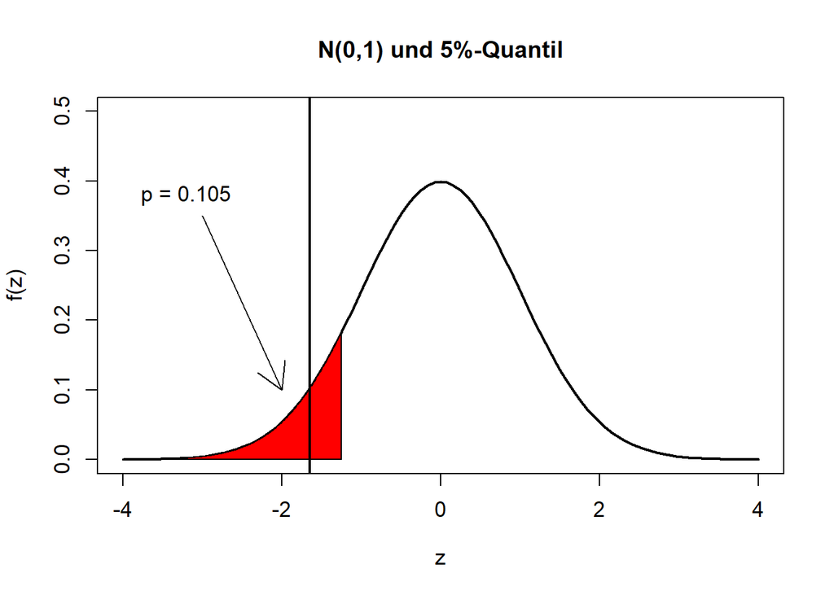

```r
cord.x1 <- c(-4,seq(-4,-1.25,0.01),-1.25)
cord.y1 <- c(0,dnorm(seq(-4,-1.25,0.01)),0)
curve(dnorm(x),xlim=c(-4,4), ylim = c(0, 0.5), lwd = 2,
      main = "N(0,1) und 5%-Quantil",
cex.lab = 1.1, cex.axis = 1.1, ylab = "f(z)", xlab = "z")
polygon(cord.x1,cord.y1,col='red')
text(-3.2, 0.38, "p = 0.105", cex = 1.1)
arrows(-3, 0.35, -2, 0.1)
abline(v = qnorm(0.05), lty = 1.5, lwd = 2) # kritischer z-Wert
```

Ab welchem Stichprobenanteilswert hätte man $H_0$ bei $\alpha = 0.05$ abgelehnt? In der Ausgangssituation hatten wir 92 defekte Teile.

```r
prop.test(x = 87, n = 517, p = 0.2, alternative = c("less"))
```

```
##
##  1-sample proportions test with continuity correction
##
## data:  87 out of 517, null probability 0.2
## X-squared = 3.06, df = 1, p-value = 0.04
## alternative hypothesis: true p is less than 0.2
## 95 percent confidence interval:
##  0.00000 0.19808
## sample estimates:
##       p
## 0.16828
```

Bei 87 defekten Teilen oder weniger hätten wir $H_0$ zu einem p-value < 0.05 abgelehnt. Also bei einem Stichprobenanteil von 87/517 = 16.8% oder weniger.

#### Statistische vs. ökonomische Signifikanz

Der Wert der Prüfgröße $z$ (<=> p-value) ist der Indikator für **statistische Signifikanz** und damit für die Frage, ob ein bestimmtes Stichprobenergebnis oder extremere Werte sich zufällig ergeben haben können. Ist $z$ betragsmäßig groß (und damit der p-value klein, d.h. < $\alpha$) spricht man von einem “statistisch signifikanten” Resultat. In diesem Fall können wir also davon ausgehen, dass das beobachtete Stichprobenergebnis **nicht zufällig** zustandegekommen ist. Es gibt also “begründete Zweifel” an der Nullhypothese: $H_0$ wird verworfen und $H_A$ angenommen.

Die Effektgröße $|h - p_0|$ (also der Betrag des Zählers von $z$) ist hingegen der Indikator für **ökonomische Signifikanz**, also für die Abweichung zwischen dem beobachteten Stichprobenwert und dem als wahr angenommenen Wert in der Null. Was hier “ökonomisch bedeutsam” ist, ist i.d.R. kontextabhängig (es gibt für den Einstichproben-z-Test auch Maßzahlen, die hier aber nicht betrachtet werden). Unter sonst gleichen Bedingungen erhöht sich mit zunehmender Effektgröße auch die statistische Signifikanz, da $z=(h-p_0)/\sigma$ mit $\sigma=\sqrt{p_0(1-p_0)/n}$. Das Problem ist aber: Es gibt ökonomisch signifikante Effekte, die nicht statistisch signifikant sind und umgekehrt. Dabei ist die **Stichprobengröße $n$** von zentraler Bedeutung. Wenn $n$ klein ist, ist $\sigma$ groß, und $z$ ist dann selbst bei einer relativ großen Effektgröße (<=> ökonomisch bedeutender Effekt) klein und es liegt keine statistische Signifikanz vor. Ist hingegen $n$ groß, kann auch eine relativ kleine Effektgröße (<=> ökonomisch unbedeutender Effekt) statistisch signifikant werden. Mit anderen Worten: Jede noch so kleine Effektgröße kann durch ein hinreichend großes $n$ “statistisch signifikant” werden. Ziel ist also, mit relativ geringem $n$ statistisch signifikante Effekte zu zeigen. Man sollte daher bei der Präsentation von Testergebnissen immer Effektgröße, Prüfgröße, $n$ und den p-value angeben. So kann man sich leicht selbst ein Bild machen, ob eine statistische Signifikanz durch eine relativ große Stichprobe verursacht wurde, aber der beobachtete Effekt ökonomisch eher unbedeutend ist.

Beispiel: Es sei $H_0: p = 0.2$ vs. $H_A: p \neq 0.2$. Wir testen also zweiseitig. Eine relativ “kleine” Effektgröße von 1%-Punkt, ist bei einem zweiseitigen Test zu $\alpha=0.05$ “statistisch signifikant”, wenn $n = 10000$, aber “statistisch insignifikant” bei $n = 1000$. Zur Erinnerung: Der kritische Wert der Prüfgröße bei einem zweiseitigen Test und $\alpha = 0.05$ ist $z_{[0.975]}=1.96$.

```r
z1 <- abs((0.19 - 0.2)/sqrt(0.2*0.8/10000)); z1  # großer z-Wert
```

```
## [1] 2.5
```

```r
z2 <- abs((0.19 - 0.2)/sqrt(0.2*0.8/1000)); z2   # kleiner z-Wert
```

```
## [1] 0.79057
```

Normalerweise liegt $n$ für einen one-proportion z-Test im Intervall $[800, 1500]$.

#### Exkurs: p-value und Fehler 1. Art

In diesem Exkurs soll gezeigt werden, dass wir mit der Festlegung des Signifikanzniveaus $\alpha$ letztlich die maximal akzeptable Wahrscheinlichkeit für den Fehler 1. Art festlegen.

Wir definieren eine große Grundgesamtheit (`pop`) mit einem wahren Anteil von $p = 0.3$.

```r
pop <- c(rep(1, 300000), rep(0, 700000))
length(pop); prop.table(table(pop))
```

```
## [1] 1000000
```

```
## pop
##   0   1
## 0.7 0.3
```

Wir ziehen aus dieser Grundgesamtheit nun eine Stichprobe mit n = 800 und testen $H_0$: $p=0.3$ vs. $H_A$: $p\neq0.3$ zu einem Signifikanzniveau von $\alpha=0.05$. Wir wiederholen dies 1000 Mal und generieren somit 1000 Zufallsstichproben mit n = 800 und können 1000 Mal einen z-Wert und einen p-value berechnen. Von den 1000 p-values liegen 49 (4.9%) unter 5%, d.h., in diesen Fällen verwerfen wir $H_0$, obwohl diese Hypothese richtig ist (= Fehler 1. Art).

```r
TEST = c() # empty variable TEST
for(i in 1:1000) {set.seed(i); TEST[i] = mean(sample(pop, 800, replace = T))}
TEST[1]    # 1st sample proportion
```

```
## [1] 0.30375
```

```r
TEST[31]   # 31st sample proportion
```

```
## [1] 0.34875
```

```r
SD <- sqrt(0.3*0.7/800)
z <- (TEST - 0.3)/SD
(TEST[1] - 0.3)/SD  # 1st z-score
```

```
## [1] 0.23146
```

```r
(TEST[31] - 0.3)/SD # 31st z-score
```

```
## [1] 3.0089
```

```r
p.value <- 2*(1 - pnorm(abs(z)))
2*(1 - pnorm(abs((TEST[1] - 0.3)/SD)))  # 1st p-value
```

```
## [1] 0.81696
```

```r
2*(1 - pnorm(abs((TEST[31] - 0.3)/SD))) # 31st p-value
```

```
## [1] 0.0026218
```

```r
prop.table(table(p.value < 0.05))
```

```
##
## FALSE  TRUE
## 0.951 0.049
```

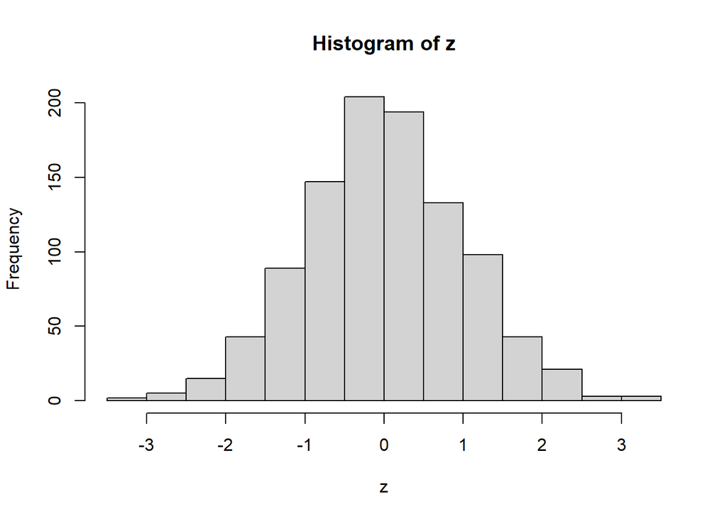

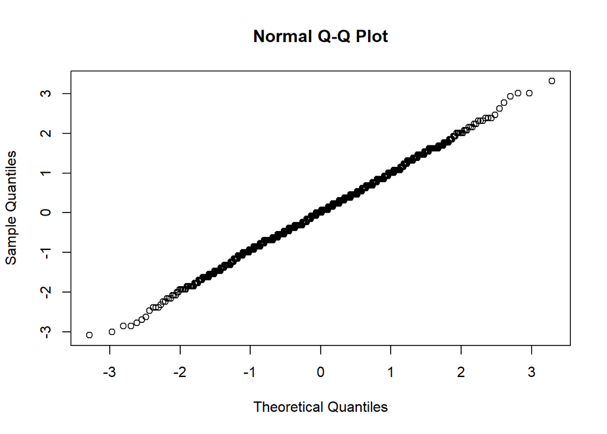

```r
hist(z); qqnorm(z)
```

Hier werden exemplarisch zwei Stichproben dargestellt: Die 1. ($h=0.3038$, relativ geringe Abweichung von 0.3, keine Ablehnung von $H_0$, p-value = 0.817) und die 31. ($h=0.3488$, relativ große Abweichung von 0.3, Ablehnung von $H_0$, p-value = 0.003). In der Praxis haben wir natürlich nur **eine Stichprobe** und kennen den wahren Anteilswert in der Grundgesamtheit nicht. Durch die Festlegung auf das Signifikanzniveau $\alpha$ können wir aber darauf vertrauen, dass wir die wahre Nullhypothese höchstens in $\alpha*100\%$ der Fälle verwerfen. Damit wird der Fehler 1. Art auf max. 0.05 (5%) begrenzt.

Wie gemäß CLT zu erwarten, folgen die 1000 z-Werte einer N(0,1)-Verteilung.

#### Konfidenzintervalle vs. p-value

Konfidenzintervalle und der aus dem Hypothesentest resultierende p-value sind wichtige Konzepte der Inferenzstatistik. Der p-value ermöglicht in Studien eine Entscheidung über das Verwerfen oder Beibehalten einer vorab formulierten Nullhypothese. In explorativen Studien lässt er statistisch auffällige (also statistisch signifikante bzw. nicht durch Zufall bedingte) Ergebnisse erkennen. Konfidenzintervalle liefern Informationen über einen Bereich, in dem der wahre Wert mit einer gewissen Wahrscheinlichkeit liegt sowie über Effektrichtung und -stärke. Durch die Angabe des Konfidenzintervalls wird die Bandbreite der Effektgröße also in einer leicht nachvollziehbaren Form kommuniziert, ohne dass man auf die Information zur statistischen Signifikanz verzichten muss. Damit werden Aussagen zur statistischen Signifikanz und zur ökonomischen Signifikanz der Studienergebnisse möglich. Die Angabe beider statistischen Maße in wissenschaftlichen Artikeln ist oft sinnvoll, da sie einander ergänzende Informationen enthalten. Diese Überlegungen gelten sowohl für den Anteilswert als auch für den Mittelwert einer Grundgesamtheit (vgl. unten).

Diese Überlegungen werden durch das folgende Beispiel illustriert:

```r
prop.test(77, 1000, p = 0.1, alt = "two.sided")
```

```
##
##  1-sample proportions test with continuity correction
##
## data:  77 out of 1000, null probability 0.1
## X-squared = 5.62, df = 1, p-value = 0.018
## alternative hypothesis: true p is not equal to 0.1
## 95 percent confidence interval:
##  0.061599 0.095736
## sample estimates:
##     p
## 0.077
```

Es wird ein zweiseitiger Hypothesentest zu $\alpha = 0.05$ durchgeführt ($H_0: p_0 = 0.1$) und ein 95%-KI berechnet. Der Stichprobenanteilswert ist $h = 0.077$ bei $n = 1000$. Ergebnis des Hypothesentests ist, dass es eine statistisch signifikante Veränderung des Anteilswerts im Vergleich zum Referenzwert 0.1 gibt (p-value = 0.02 < 0.05). Das 95%-KI für den wahren Anteilswert ist [0.062, 0.096]. Der Referenzwert (0.1) ist nicht eingeschlossen, daher kommt das KI zum gleichen Ergebnis wie der Hypothesentest: Wir können davon ausgehen, dass der wahre Anteilswert nicht 0.1 ist.

Allgemein gilt (wie hier im Beispiel): Ein zweiseitiger Hypothesentest zu einem Signifikanzniveau $\alpha$ kommt i.d.R. zur gleichen Schlussfolgerung wie ein (zweiseitiges) Konfidenzintervall zur Vertrauenswahrscheinlichkeit $1 - \alpha$.

#### Exkurs: Fehler 2. Art

In diesem Exkurs soll gezeigt werden, wie der Fehler 2. Art berechnet werden kann. Der Fehler 1. Art ($\alpha$) besteht darin, $H_0$ zu verwerfen, obwohl diese Hypothese wahr ist. Der Fehler 2. Art ($\beta$) besteht darin, $H_0$ zu nicht verwerfen, obwohl diese Hypothese falsch ist. Mit $1-\beta$ wird die **Power** (Teststärke) eines Hypothesentests bezeichnet. Die Power gibt an, mit welcher Wahrscheinlichkeit man eine falsche $H_0$ richtigerweise verwirft. Mit anderen Worten: Die Power gibt an, wie gut ein Test einen echten Effekt findet.

Beispiel 1: Wir berechnen die Power für einen Einstichproben-z-Test mit $H_0: p = 0.5$ vs. $H_A: p > 0.5$ (oberseitig, $\alpha = 0.05$). Der wahre Anteilswert in der Grundgesamtheit sei $p=0.6$ (hier mit p1 bezeichnet, mit p0 wird hingegen der Anteilswert unter $H_0$ bezeichnet). Wie wir sehen, ist in diesem Fall die Nullhypothese falsch.

```r
# Wir installieren und laden zwei Pakete.
library(EnvStats)  # Das Paket muss installiert sein.
library(stats)     # Das Paket muss installiert sein.
```

Zunächst müssen wir klären, wo der Ablehnungsbereich für diesen Test liegt.

```r
# 95%-Quantil für N(0.5, sqrt(0.5*0.5/200))
pnorm(0.558, 0.5, sqrt(0.5*0.5/200))
```

```
## [1] 0.94955
```

Der Wert $h=0.558$ ist das 95%-Quantil der Normalverteilung unter $H_0$. Also wird $H_0$ verworfen (<=> Ablehnungsbereich), wenn $h>0.558$. Man kann den Ablehnungsbereich auch über N(0,1) berechnen. Es gilt $z = (x - \mu)/\sigma$. Hier ist $z = 1.645$ (95%-Quantil von N(0,1)), $\mu=0.5$ und $\sigma={\sqrt{(0.5*0.5/200)}}= 0.0354$. Dann ist $x = 1.645*0.0354 + 0.5 = 0.558$.

Das Problem kann dann graphisch folgendermaßen dargestellt werden.

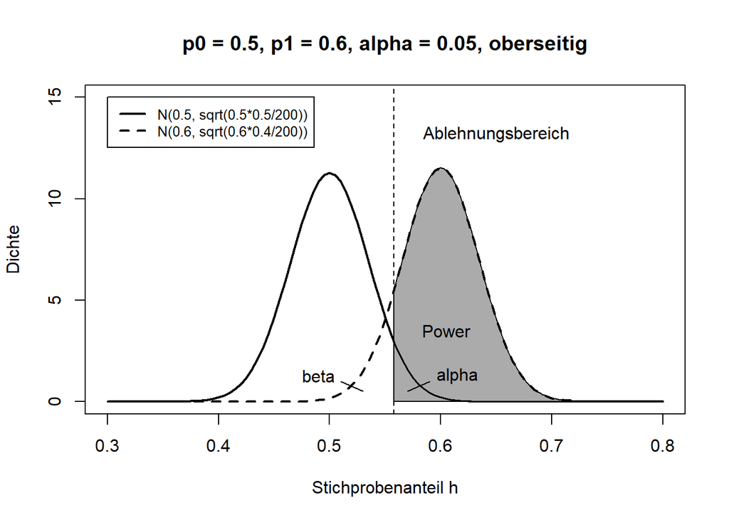

```r
# Koordinaten für polygon() unten
cord.x1 <- c(0.558,seq(0.558,0.8,0.001), 0.8)
cord.y1 <- c(0,dnorm(seq(0.558,0.8,0.001), 0.6, sqrt(0.6*0.4/200)),0)

curve(dnorm(x, 0.5, sqrt(0.5*0.5/200)), xlab = "Stichprobenanteil h", lwd = 2,
main= "p0 = 0.5, p1 = 0.6, alpha = 0.05, oberseitig",
ylab = "Dichte",
xlim = c(0.3, 0.8), ylim = c(0, 15))
abline(v = 0.558, lty = 2)
curve(dnorm(x, 0.6, sqrt(0.6*0.4/200)), xlim = c(0.3, 0.8), add = TRUE,
      lty = 2, lwd = 2)
text(0.65, 13.2, "Ablehnungsbereich")
legend(0.3, 15, c("N(0.5, sqrt(0.5*0.5/200))", "N(0.6, sqrt(0.6*0.4/200))"),
       lty = c(1, 2), lwd = c(2,2), cex = 0.8)
polygon(cord.x1,cord.y1,col='gray67')
curve(dnorm(x, 0.5, sqrt(0.5*0.5/200)), add = TRUE, lwd = 1.5)
curve(dnorm(x, 0.6, sqrt(0.6*0.4/200)), add = TRUE, lty = 2, lwd = 2)
text(0.615, 1.3, "alpha"); text(0.49, 1.3, "beta"); text(0.605, 3.5, "Power")
segments(0.57, 0.5, 0.59, 1); segments(0.53, 0.5, 0.51, 1)
```

In der Abbildung oben sind zwei Normalverteilungen dargestellt. Die linke Normalverteilung ist um 0.5 zentriert und ergibt sich aus der (hier falschen) Nullhypothese mit p = p0 = 0.5. Die rechte Normalverteilung ist um 0.6 zentriert und ergibt sich aus dem wahren Anteilswert p1 = 0.6. Aus dem Abstand der Mittelwerte ergibt sich die Effektgröße, hier 0.6 - 0.5 = 0.1 (10%). Die Nullhypothese wird verworfen, wenn der Stichprobenanteil $h$ im Ablehnungsbereich (rechts der gestrichelten vertikalen Linie) liegt, hier wenn $h>0.558$. Wenn $\alpha = 0.05$, ergibt sich $\beta$ als Fläche unter der rechten Normalverteilung links von $h=0.558$. $\beta$ ist also die Wahrscheinlichkeit, die Nullhypothese von p = p0 = 0.5 nicht zu verwerfen, obwohl diese eigentlich falsch ist (es gilt ja p1 = 0.6). Die **Power**, d.h. die Wahrscheinlichkeit, die falsche $H_0$ richtigerweise zu verwerfen, ergibt sich dann als grau markierte Fläche unter der Dichte der rechten Normalverteilung im Ablehnungsbereich.

In R kann man die Power leicht berechnen.

```r
# Berechnung der Power für Beispiel 1 oben
1 - pnorm(0.558, 0.6, sqrt(0.6*0.4/200))  # Power = grau markierte Fläche
```

```
## [1] 0.88733
```

```r
# Alternativ mit propTestPower(), o.g. Pakete müssen geladen sein
power <- propTestPower(n.or.n1 = 200, alt = "greater", p.or.p1 = 0.6, p0 = 0.5)
round(power, 3)
```

```
## [1] 0.886
```

Was folgt daraus?

Für eine empirische Studie sind **vier Faktoren** zu berücksichtigen:

1. Der **Fehler 1. Art $\alpha$** (“false positive”): Meist als Signifikanzniveau bezeichnet, i.d.R. wird $\alpha = 0.05$ (5%) gesetzt.
2. Die **Power** ($1-\beta$, Gegenwahrscheinlichkeit zum Fehler 2. Art): Die Power (auch Teststärke genannt) ist die Wahrscheinlichkeit, dass ein Effekt entdeckt wird, wenn der Effekt auch tatsächlich existiert. Es wird i.d.R. eine Power von 0.8 (80%) angestrebt (<=> $\beta = 0.2$ (20%)).
3. Die **Effektgröße**, also die Größe des Unterschieds oder des Zusammenhangs, den man aufdecken möchte.
4. Die **Stichprobengröße** (i.d.R. die Zahl der Teilnehmer an der Studie).

Diese vier Größen werden auch mit **APES** bezeichnet. Interessant ist, dass, wenn man drei der Größen aus APES kennt, man die vierte berechnen kann.

In der Praxis wird diese Logik folgendermaßen angewendet:

1. Die Effektgröße ist vorgegeben oder man hat eine Erwartung darüber (z.B. aus der Literatur oder aus einer Pilotstudie), $\alpha$ (i.d.R. 0.05 = 5%) und Power (i.d.R. 0.80 = 80%) sind gegeben und man berechnet dann die nötige Stichprobengröße.
2. Man berechnet für eine gegebene Stichprobengröße, $\alpha$ (i.d.R. 0.05 = 5%) und Power (i.d.R. 0.80 = 80%) die kleinste Effektgröße, die man mit dem Test gerade noch entdecken kann (auch “Minimum Detectable Effect (MDE)”).

Einige weitere Berechnungen zu Beispiel 1: $H_0: p = 0.5$ vs. $H_A: p > 0.5$ (oberseitig, $\alpha = 0.05$): (a) Was ist die Power für eine Stichprobengröße von 30, wenn p1 = 0.75? (b) Welche Stichprobengröße wird benötigt, um eine Power von 80% bei p1 = 0.65 zu erreichen? (c) Welche Stichprobengröße wird benötigt, um eine Power von 80% bei p1 = 0.55 zu erreichen? (d) Welche Effektgröße lässt sich für eine Stichprobengröße von 100 und eine Power von 80% gerade noch entdecken?

```r
# a)
power <- propTestPower(n.or.n1 = 30, alpha = 0.05, alt = "greater", p.or.p1 = 0.75, p0 = 0.5)
round(power, 3)
```

```
## [1] 0.897
```

```r
# Die Power ist 89.7%.
```

```r
# b)
power <- propTestPower(n.or.n1 = 67, alpha = 0.05, alt = "greater", p.or.p1 = 0.65, p0 = 0.5)
round(power, 3)
```

```
## [1] 0.802
```

```r
# Es wird eine Stichprobengröße von 67 benötigt.
```

```r
# c)
power <- propTestPower(n.or.n1 = 616, alpha = 0.05, alt = "greater", p.or.p1 = 0.55, p0 = 0.5)
round(power, 3)
```

```
## [1] 0.8
```

```r
# Es wird eine Stichprobengröße von 616 benötigt.
```

```r
# d)
power <- propTestPower(n.or.n1 = 100, alpha = 0.05, alt = "greater", p.or.p1 = 0.623, p0 = 0.5)
round(power, 3)
```

```
## [1] 0.8
```

```r
# Eine Effektgröße von 0.623 - 0.5 = 0.123 (12.3%) kann gerade noch entdeckt werden.
```

**Power-Analysen** machen eine Aussage darüber, wie hoch die statistische Power für ein Studiendesign ist. Sie werden i.d.R. vor der eigentlichen Datenerhebung durchgeführt (a priori power analysis), um abzuschätzen, wie viele Versuchspersonen für die Durchführung der Studie nötig sind.

Beispiel 2: Angenommen, 50 % der Patienten mit einer bestimmten Krebsart überleben fünf Jahre. Forscher haben eine neue Behandlung entwickelt, um den Prozentsatz der Personen zu erhöhen, die fünf Jahre überleben. Obwohl die Forscher nicht wissen, wie hoch der tatsächliche Prozentsatz der Patienten ist, die mit der neuen Behandlung überleben werden, möchten sie untersuchen, welche Aussagekraft die Ergebnisse haben, wenn der Prozentsatz unter der neuen Behandlung 60% (oder 55%) beträgt. Die Aussagekraft wird für Studien mit Stichprobengrößen von 50, 100, 200, 300, 500 oder 800 und einem Signifikanzniveau von 0.05 (zweiseitig) bestimmt. Ziel ist es, mit einer Abbildung den Zusammenhang zwischen Stichprobengröße (sample size) und Power für unterschiedliche Effektgrößen (hier 5%- und 10%-Punkte) zu ermitteln.

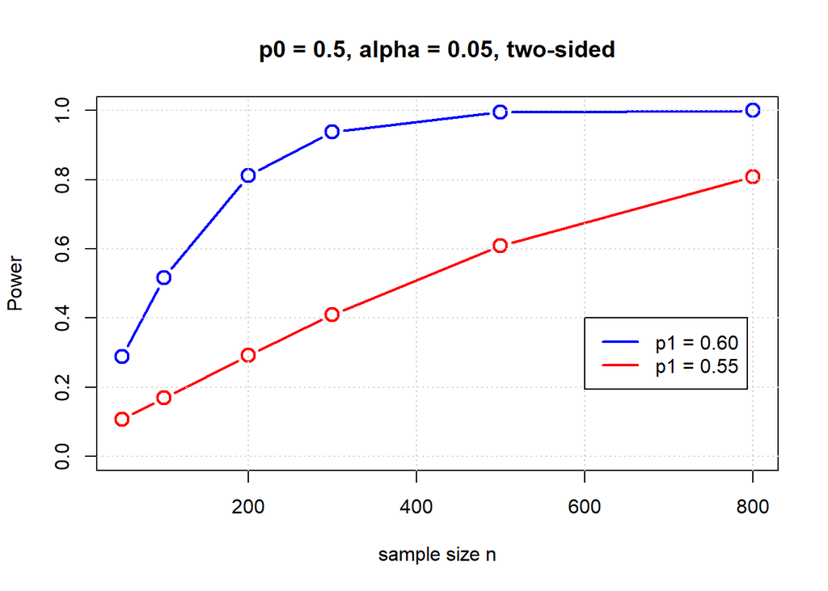

```r
power <- propTestPower(n.or.n1 = c(50, 100, 200, 300, 500, 800), alpha = 0.05,
                       alt = "two.sided", p.or.p1 = 0.6, p0 = 0.5)
pwrp1is0.60 <- round(power, 3)

power <- propTestPower(n.or.n1 = c(50, 100, 200, 300, 500, 800), alpha = 0.05,
                       alt = "two.sided", p.or.p1 = 0.55, p0 = 0.5)
pwrp1is0.55 <- round(power, 3)

plot(c(50, 100, 200, 300, 500, 800), pwrp1is0.60, type = "b", ylim = c(0,1),
xlab = "sample size n", ylab = "Power",
main= "p0 = 0.5, alpha = 0.05, two-sided",
cex = 1.5, col = "blue", lwd = 2)
lines(c(50, 100, 200, 300, 500, 800), pwrp1is0.55, type = "b",
      col = "red", lwd = 2, cex = 1.5)
grid()
legend(600, 0.4, c("p1 = 0.60","p1 = 0.55"), lwd = 2, col = c("blue", "red"))
```

Aus der Abbildung oben wird deutlich, dass für eine Effektgröße von 5%-Punkten (10%-Punkten) eine Stichprobengröße von 800 (200) Teilnehmern nötig ist, um eine Power von 80% zu erreichen. Wir sehen also, dass für eine gegebene Effektgröße eine Erhöhung der Stichprobengröße die Power erhöht. Es wird auch deutlich, dass für eine bestimmte Stichprobengröße die Power größer ist, wenn die Effektgröße größer ist.

Wichtig ist, zu verstehen:

1. für eine gegebene Stichprobengröße und $\alpha$, ist die Power umso größer, je größer die Effektgröße ist.
2. für eine gegebene Effektgröße und $\alpha$, ist die Power umso größer, je größer die Stichprobengröße ist (weil dies die Standardabweichung reduziert).

Abschließend wollen wir die Power mit Hilfe einer Simulation verdeutlichen. Wir beziehen uns wieder auf das Beispiel 1: $H_0: p = 0.5$ vs. $H_A: p > 0.5$ (oberseitig, $\alpha = 0.05$) und setzen die Stichprobengröße n = 200 und p1 = 0.6. Wir erzeugen zunächst eine Grundgesamtheit mit p = 0.6. Aus dieser Grundgesamtheit ziehen wir 1000 Mal eine Zufallsstichprobe mit n = 200 und berechnen einen Stichprobenanteilswert und einen z-Wert. Daraus lässt sich dann ermitteln, ob man $H_0$ verwirft (richtige Entscheidung) oder nicht (falsche Entscheidung).

```r
# Erzeuge eine Grundgesamtheit mit p = 0.6
set.seed(3); pop <- c(rep(1, 6000000), rep(0, 4000000))
table(pop)
```

```
## pop
##       0       1
## 4000000 6000000
```

```r
sample_prop <- c()
for(i in 1:1000) {set.seed(i); sample_prop[i] = mean(sample(pop, size = 200, replace = TRUE))}
SD <- sqrt((0.6*0.4)/200)
sample_prop_st <- (sample_prop - 0.5)/SD
# hist(sample_prop_st)

# H0 wird verworfen, wenn sample_prop_st > 1.645 = 95%-Quantil von N(0,1)
prop.table(table(sample_prop_st > qnorm(0.95)))
```

```
##
## FALSE  TRUE
## 0.124 0.876
```

Das Ergebnis: Wir verwerfen $H_0$ in 87.6% aller Fälle und treffen dann die richtige Entscheidung. Die Power ist also hier 87.6%. In 12.4% der Fälle verwerfen wir $H_0$ nicht und treffen die falsche Entscheidung (“false negative”), d.h. $\beta = 0.124$ (12.4%). Das Ergebnis stimmt also näherungsweise mit den theoretischen Überlegungen oben überein.

### Anpassungstest

Bei diesem Test geht es darum, ob ein bestimmtes theoretisches Modell in der Lage ist, die beobachtete Verteilung qualitativer Daten angemessen zu erklären. Konkret: Man vergleicht eine Stichprobenverteilung, die aus einer unbekannten Verteilung $F$ in der Grundgesamtheit gewonnen wurde, mit einer vorgegebenen theoretischen Verteilung $F_0$.

Die Nullhypothese

$H_0: F = F_0$

wird verworfen, wenn die Verteilung $F$ relativ stark von $F_0$ abweicht. Die Alternativhypothese ist daher $H_A: F \neq F_0$. Dieser Test wird Anpassungstest (auch “goodness-of-fit test”) genannt.

Die Testvariable beim Anpassungstest ist

$\sum_{j=1}^{m} \frac{(n_j-E_j)^2}{E_j} \sim \chi^2_{m-1}$

Die Testvariable folgt unter Gültigkeit von $H_0$ unter bestimmten Bedingungen (vgl. unten) einer $\chi^2$-Verteilung mit $df=m-1$ und $m$ als Zahl Klassen. Die Logik hinter dem Summenoperator ist Folgende: Die qualitativen Daten liegen mit absoluter Häufigkeit $n_j$ in $m$ Klassen vor. Zugleich kann man unter Gültigkeit von $H_0$ die erwarteten absoluten Häufigkeiten $E_j$ gemäß der theoretischen Verteilung bestimmen. Für jede Klasse wird die Differenz zwischen beobachteter und erwarteter Häufigkeit bestimmt, diese quadriert und in Relation zur erwarteten Häufigkeit gesetzt. Die so gewonnenen $m$ Werte werden aufaddiert.

Wird die Abweichung zwischen beobachteten und erwarteten Häufigkeiten sehr groß, ist $H_0$ zu verwerfen. Ein großer Wert der Prüfgröße spricht also gegen $H_0$. Die Entscheidungsregel bei diesem Test ist daher:

$\sum_{j=1}^{m} \frac{(n_j-E_j)^2}{E_j} > \chi^2_{m-1[1-\alpha]} => H_0$ $verwerfen$

Die Berechnung des p-value erfolgt mit:

$p$-$value =1-F_{\chi^2}(\sum_{j=1}^{m} \frac{(n_j-E_j)^2}{E_j},m-1)$

Hierbei ist $F_{\chi^2}(...,m-1)$ die Verteilungsfunktion der $\chi^2$-Verteilung mit $m-1$ Freiheitsgraden. Der Anpassungstest ist immer ein **oberseitiger Test**.

Folgende **Annahmen und Bedingungen** müssen für den Anpassungstest gültig sein:

1. Es müssen qualitative Daten vorliegen.
2. Die beobachteten Werte müssen unabhängig voneinander sein. Diese Annahme kann als erfüllt angesehen werden, wenn die Beobachtungen eine Zufallsstichprobe aus der Grundgesamtheit darstellen und der Auswahlsatz klein ist ($n/N\leq0.05$).
3. Die Stichprobe muss hinreichend groß sein. Konkret ist $E_j\geq5$ zu fordern (mind. fünf erwartete Beobachtungen in jeder Klasse).

Betrachten wir das folgende Beispiel (vgl. auch unfall.csv): Es liegen Zahlen zu 130 Arbeitsunfällen pro Arbeitstag (Mo bis Fr) vor. Die Beobachtungen wurden zufällig aus einer großen Grundgesamtheit gewonnen. Die Frage ist, ob die Arbeitsunfälle sich gleichmäßig auf die Arbeitstage verteilen oder nicht. Bei einer Gleichverteilung würden sich 130/5 = 26 Unfälle pro Arbeitstag ergeben.

Wir stellen zunächst die beobachtete Häufigkeitsverteilung mit einem Barplot graphisch dar.

```r
unfall <- c(39, 23, 12, 21, 35); sum(unfall)
```

```
## [1] 130
```

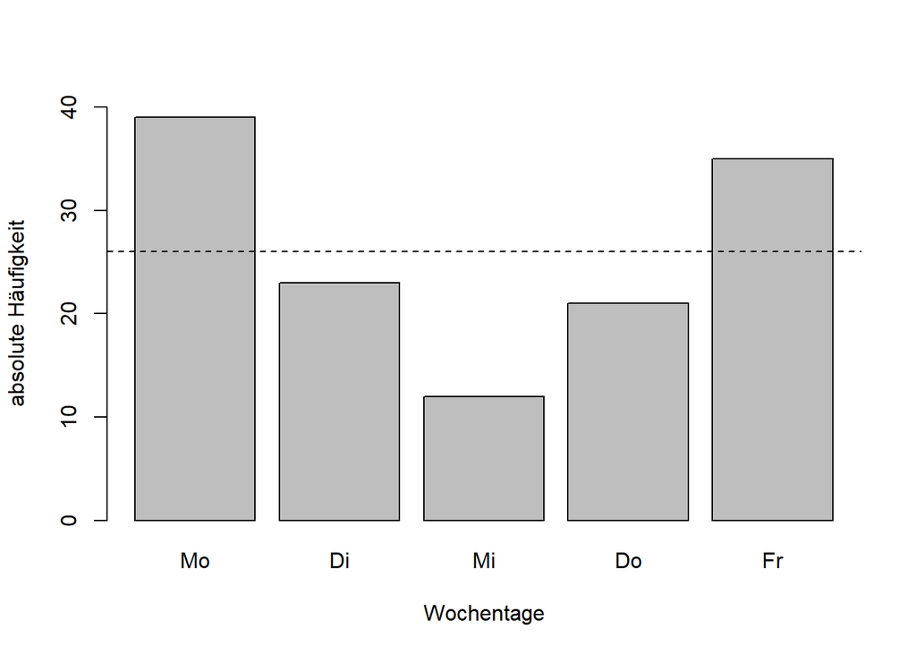

```r
barplot(unfall, ylab = "absolute Häufigkeit", xlab = "Wochentage", ylim = c(0, 40),
names.arg = c("Mo", "Di", "Mi", "Do", "Fr"))
abline(h = 26, lty = 2)
```

Der Barplot zeigt eine deutliche Abweichung von der Gleichverteilung (gestrichelte Linie), die aber gleichwohl zufällig bedingt sein kann. Mit dem Anpassungstest können wir diese Unsicherheit quantifizieren. Die Nullhypothese ist, dass in der Grundgesamtheit eine Gleichverteilung vorliegt. Die Alternativhypothese ist, dass in der Grundgesamtheit keine Gleichverteilung vorliegt.

Wir berechnen den p-value folgendermaßen:

```r
unfall <- c(39, 23, 12, 21, 35); sum(unfall)
```

```
## [1] 130
```

```r
Exp <- c(26, 26, 26, 26, 26)
Chi <- sum((unfall - Exp)^2/Exp); Chi   # Berechnung der Prüfgröße
```

```
## [1] 18.462
```

```r
p.value <- 1 - pchisq(Chi, df = 4); p.value
```

```
## [1] 0.0010024
```

Mit R können wir den Test einfach so durchführen:

```r
chisq.test(unfall, p = c(26/130, 26/130, 26/130, 26/130, 26/130))
```

```
##
##  Chi-squared test for given probabilities
##
## data:  unfall
## X-squared = 18.5, df = 4, p-value = 0.001
```

Hierzu müssen wir mit `p = c()` die Wahrscheinlichkeit für die Verteilung unter der Nullhypothese angegeben (hier $26/130=0.2$). Die Interpretation des p-value ist folgende: Wenn in der Grundgesamtheit die Arbeitsunfälle tatsächlich gleichverteilt sind, ist die Wahrscheinlichkeit, bei einer Zufallsstichprobe von 130 Unfällen eine Verteilung wie in der Stichprobe oder extremer zu beobachten, gleich 0.1%. Auf Grund dieser geringen Wahrscheinlichkeit können wir davon ausgehen, dass die Arbeitsunfälle nicht gleichverteilt sind. Oder m.a.W.: Die Verteilung der Unfälle unterscheidet sich statistisch signifikant von der Gleichverteilung.

Auf die Darstellung von Maßzahlen für die Effektgröße verzichten wir hier.

#### Exkurs: Anpassungstest bei zwei Klassen

Der Anpassungstest ist bei zwei Klassen (z.B. Ausschuss: ja oder nein) äquivalent zum Anteilswert-z-Test (vgl. oben). Um den exakten p-value zu erhalten, müssen wir dabei nur die Stetigkeitskorrektur in R deaktivieren (`correct = FALSE`). $H_0$ bestimmt die erwartete Verteilung, und die beobachtete Verteilung ergibt sich aus der Stichprobe.

Betrachten wir Beispiel 3 mit der Ausschussquote oben:

```r
prop.test(x = 92, n = 517, p = 0.2, correct = FALSE)
```

```
##
##  1-sample proportions test without continuity correction
##
## data:  92 out of 517, null probability 0.2
## X-squared = 1.57, df = 1, p-value = 0.21
## alternative hypothesis: true p is not equal to 0.2
## 95 percent confidence interval:
##  0.14739 0.21326
## sample estimates:
##       p
## 0.17795
```

Hier muss mit `prop.test()` zweiseitig getestet werden, weil es um die Abweichung vom Anteilswert in $H_0$ geht (Abweichung nach oben und unten ist möglich). Die Zahl Freiheitsgrade ist df = 1. Der $\chi^2$-Wert und der p-value ergeben sich mit:

```r
chi <- (92 - 0.2*517)^2/(0.2*517) + (425 - 0.8*517)^2/(0.8*517); chi
```

```
## [1] 1.5711
```

```r
p.value <- 1 - pchisq(chi, df = 1); p.value
```

```
## [1] 0.21005
```

Wert der Prüfgröße und p-value sind für beide Rechenmethoden identisch.

### Unabhängigkeitstest

Bei einem Unabhängigkeitstest möchte man die Hypothese testen, dass zwei qualitative Merkmale, $X$ und $Y$, voneinander unabhängig sind. Man testet also:

$H_0$: $X$ und $Y$ sind unabhängig vs. $H_A$: $X$ und $Y$ sind nicht unabhängig

Der Test erfolgt unter Berücksichtigung der Verteilung in einer Stichprobe. Wird in der Stichprobe eine hinreichend starke Abhängigkeit zwischen beiden Merkmalen gefunden, wird $H_0$ verworfen. Der Unabhängigkeitstest verwendet die **quadratische Kontingenz** $QK$ als Testvariable. $QK$ ist unter Gültigkeit von $H_0$ näherungsweise $\chi^2$-verteilt mit $(k-1)(l-1)$ Freiheitsgraden, wobei $k$ für die Zeilenzahl und $l$ für die Spaltenzahl der Kontingenztabelle steht.

Die Entscheidungsregel lautet daher:

$QK = \sum_{i=1}^{k} \sum_{j=1}^{l} \frac{(n_{ij}-E_{ij})^2}{E_{ij}} > \chi^2_{(k-1)(l-1)[1-\alpha]} => H_0$ $verwerfen$

Hierbei sind $n_{ij}$ die beobachteten Werte in der Kontingenztabelle für Zeile $i$ und Spalte $j$, $E_{ij}$ sind die erwarteten Werte bei statistischer Unabhängigkeit. Wie beim Anpassungstest spricht ein hoher Wert der Prüfgröße gegen $H_0$.

Die Berechnung des p-value erfolgt mit:

$p$-$value =1-F_{\chi^2}(QK,(k-1)(l-1))$

mit $F_{\chi^2}(...,(k-1)(l-1))$ als Verteilungsfunktion der $\chi^2$-Verteilung mit $(k-1)(l-1)$ Freiheitsgraden.

Der Unabhängigkeitstest ist immer ein **oberseitiger Test**.

Für den Unabhängigkeitstest müssen folgende Annahmen und Bedingungen gültig sein (analog zum Anpassungstest, vgl. oben):

1. Die Merkmale müssen in Klassen erhoben bzw. qualitativ sein.
2. Die Beobachtungen müssen unabhängig voneinander sein bzw. aus einer Zufallsstichprobe stammen. Der Auswahlsatz muss klein sein ($n/N\leq0.05$).
3. Die erwartete absolute Häufigkeit in jeder Zelle der Kontingenztabelle muss mindestens fünf sein, d.h. $E_{ij} \geq 5$.

Betrachten wir ein Beispiel (Lehrbuch S. 261): Vor den US-Präsidentschaftswahlen werden 1000 zufällig ausgewählte Wahlberechtigte nach Geschlecht und Wahlpräferenz befragt. Die Daten liegen in `Bsp._11.7.csv` vor. Es stellt sich die Frage, ob das Geschlecht einen Effekt auf die Wahlpräferenz hat. Das Signifikanzniveau sei 0.05.

```r
setwd("C:/Users/sturm/Desktop/dataR")   # setze das Arbeitsverzeichnis
data <- read.csv("Bsp._11.7.csv")
# data <- read.csv("https://raw.githubusercontent.com/bodosturm/dataR/main/Bsp._11.7.csv")
data[1:2,]; attach(data)
```

|  | X | vote | gender |
| --- | --- | --- | --- |
| 1 | 1 | rep | male |
| 2 | 2 | rep | male |

Mit R lässt sich der Test auf Unabhängigkeit einfach so durchführen:

```r
addmargins(table(gender, vote))
```

```
##       vote
## gender  dem  ind  rep  Sum
##   fem   300   50  250  600
##   male  150   50  200  400
##   Sum   450  100  450 1000
```

```r
chisq.test(table(gender, vote))
```

```
##
##  Pearson's Chi-squared test
##
## data:  table(gender, vote)
## X-squared = 16.2, df = 2, p-value = 0.0003
```

Wir wollen hier $QK$ “per Hand” berechnen und den p-value reproduzieren.

```r
Chi2 <- chisq.test(table(gender, vote))
Chi2$expected           # erwartete Werte bei Unabhängigkeit E_ij
```

```
##       vote
## gender dem ind rep
##   fem  270  60 270
##   male 180  40 180
```

```r
Chi2$observed           # beobachtete Werte n_ij
```

```
##       vote
## gender dem ind rep
##   fem  300  50 250
##   male 150  50 200
```

```r
QK <- sum((Chi2$observed - Chi2$expected)^2/Chi2$expected)
QK                      # Quadratische Kontingenz
```

```
## [1] 16.204
```

```r
p.value <- 1 - pchisq(QK, df = 2); p.value
```

```
## [1] 0.00030298
```

Interpretation: Wir lehnen $H_0$ ab und können damit schlussfolgern, dass die Merkmale Geschlecht und Wahlpräferenz statistisch signifikant voneinander abhängig sind. Wenn in der Grundgesamtheit die Merkmale Geschlecht und Wahlpräferenz tatsächlich voneinander unabhängig sind, ist die Wahrscheinlichkeit, bei einer Zufallsstichprobe von $n = 1000$ eine Verteilung wie in der Stichprobe oder extremer zu erhalten, gleich 0.03%. Auf Grund dieser geringen Wahrscheinlichkeit verwerfen wir die Hypothese der Unabhängigkeit und können davon ausgehen, dass die beiden Merkmale voneinander abhängig sind. Hier: Das Geschlecht beeinflusst das Wahlverhalten.

Ein kleiner p-value (< $\alpha$) beim Unabhängigkeitstest signalisiert, dass die Abhängigkeit nicht zufällig zustandegekommen ist, sondern tatsächlich auch in der Grundgesamtheit vorliegt (“statistische Signifikanz”). Als deskriptives Maß zur Messung der Stärke der Abhängigkeit zwischen zwei nominal skalierten Merkmalen in einer Stichprobe (“ökonomische Signifikanz”) wird u.a. der korrigierte Kontingenzkoeffizient $KK^{*}$ genutzt.

```r
n <- 1000; m <- 2
KK_stern <- sqrt( QK*m /((QK + n)*(m - 1))); KK_stern
```

```
## [1] 0.17858
```

Im Beispiel liegt ein statistisch hochsignifikanter Effekt vor, d.h. der p-value ist sehr klein. KK* als Maß für die Stärke der Abhängigkeit (Effektgröße) ist aber relativ klein mit KK* = 0.18. Wir haben also hier einen ökonomisch eher unbedeutenden Effekt (kleine effect size, KK*), und erhalten wegen der relativ großen Stichprobe aber dennoch ein statistisch signifikantes Resultat.

## Inferenz für quantitative Daten (alle Module)

In diesem Abschnitt werden wir uns mit Methoden der Inferenzstatistik (auch “induktive Statistik”) für quantitative Daten beschäftigen. Dabei geht es darum, was wir aus den Stichprobenbeobachtungen über einen unbekannten Parameter in der Grundgesamtheit (hier der Mittelwert $\mu$) schließen können.

#### Vorab

Immer dann, wenn man die Standardabweichung der Grundgesamtheit ($\sigma$) nicht kennt (und das ist die Regel), muss man diese aus den Stichprobeninformationen schätzen ($\widehat{\sigma}$). Wir berechnen dann mit Hilfe von $\widehat{\sigma}$ die geschätzte Standardabweichung des Stichprobenmittels, auch als **Standardfehler** bezeichnet ($SE = \widehat{\sigma}_{\bar{X}} = \frac{\widehat \sigma}{\sqrt{n}}$). In diesem Fall ist bei einer großen Stichprobe ($n > 30$) der standardisierte Stichprobenmittelwert, $(\bar{x}-\mu)/SE$, nicht mehr näherungsweise $N(0,1)$-verteilt, sondern folgt - unabhängig von der Verteilung des Merkmals in der Grundgesamtheit - näherungsweise einer t-Verteilung mit df = n-1 (df = degrees of freedom). Bei einer kleinen Stichprobe ($n \leq 30$) folgt der standardisierte Stichprobenmittelwert näherungsweise einer t-Verteilung, wenn das Merkmal in der Grundgesamtheit einer $N(\mu, \sigma)$-Verteilung folgt. Diese Erkenntnis geht auf William Sealy **Gosset** (1876-1937) zurück. Gosset war Head Brewer der Guinness Brewerey in Dublin und beschäftigte sich mit der betriebswirtschaftlich hochrelevanten Frage, was man aus kleinen Stichproben über den wahren Mittelwert der Grundgesamtheit lernen kann. Er publizierte seine Erkenntnisse unter dem Pseudonym “Student” (Student: The Probable Error of a Mean, Biometrika, 6(1), 1-24, 1908), daher wurde die zugrundeliegende Verteilung später auch als Student-t-Verteilung (oder nur t-Verteilung) benannt.

### Konfidenzintervall (KI) für $\mu$

#### Einführung

Es gibt zwei unterschiedliche Verteilungen für den standardisierten Stichprobenmittelwert: Die $N(0,1)$-Verteilung (wenn $\sigma$ bekannt) und die t-Verteilung (wenn $\sigma$ unbekannt). Kennt man die Verteilung, kann man aus dem Stichprobenmittel, der zugehörigen Standardabweichung und dem $(1-\alpha/2)$-Quantil der entsprechenden Verteilung das $(1-\alpha)$-Konfidenzintervall für $\mu$ berechnen.

Die folgende Tabelle zeigt die möglichen Fallunterscheidungen für die Berechnung des $(1-\alpha)$-KI für $\mu$.

KI für den Mittelwert der Grundgesamtheit (GG)

|  | $\sigma$ bekannt | $\sigma$ unbekannt |
| --- | --- | --- |
| **$n > 30$** | $\bar{x}\pm z_{[1-\alpha/2]}\sigma_{\bar{X}}$ | $\bar{x}\pm t_{n-1[1-\alpha/2]}\widehat{\sigma}_{\bar{X}}$ |
| **$n \leq 30$** | $\bar{x}\pm z_{[1-\alpha/2]}\sigma_{\bar{X}}$ wenn GG normalverteilt | $\bar{x}\pm t_{n-1[1-\alpha/2]}\widehat{\sigma}_{\bar{X}}$ wenn GG normalverteilt |

mit:

$\sigma_{\bar{X}}=\frac{\sigma}{\sqrt{n}}$ und $SE = \widehat{\sigma}_{\bar{X}} = \frac{\widehat{\sigma}}{\sqrt{n}}$

für $n > 30$ gilt zudem: $t_{n-1[1-\alpha/2]} \approx z_{[1-\alpha/2]}$.

Generell muss zur Berechnung und Interpretation des KI die Annahme der Unabhängigkeit der Stichprobenbeobachtungen erfüllt sein. Hierfür sollte geprüft werden, ob eine Zufallsstichprobe vorliegt und die Stichprobe in Relation zur Grundgesamtheit klein ist ($n/N \leq0.05$).

Wir betrachten im Folgenden nur die praxisrelevanten Fälle mit unbekanntem $\sigma$.

#### Fall: $n>30$ und $\sigma$ unbekannt

In diesem Fall (“große Stichprobe”) ist das KI definiert als:

$KI(1-\alpha)_{\mu} =\bar{x}\pm t_{n-1[1-\alpha/2]}\widehat{\sigma}_{\bar{X}}$

Betrachten wir zunächst das mittlere monatliche Einkommen von HTWK-Studierenden im Jahr 2009.

```r
setwd("C:/Users/sturm/Desktop/dataR")     # setze das Arbeitsverzeichnis
stud.data_oA <- read.csv("student_ohne_Ausr.csv") # bereinigter Datensatz, nur 2009
# stud.data_oA <- read.csv("https://raw.githubusercontent.com/bodosturm/dataR/main/student_ohne_Ausr.csv")
attach(stud.data_oA); stud.data_oA[1:3, ]
```

|  | fem | age | height | weight | shoe | sport | veg_fruits | income |
| --- | --- | --- | --- | --- | --- | --- | --- | --- |
| 1 | 0 | 20 | 175 | 58 | 41 | 3 | 0 | 300 |
| 2 | 1 | 20 | 168 | 63 | 39 | 1 | 5 | 700 |
| 3 | 1 | 22 | 160 | 62 | 39 | 5 | 3 | 750 |

```
##    Min. 1st Qu.  Median    Mean 3rd Qu.    Max.
##       0     400     600     606     735    3500
```

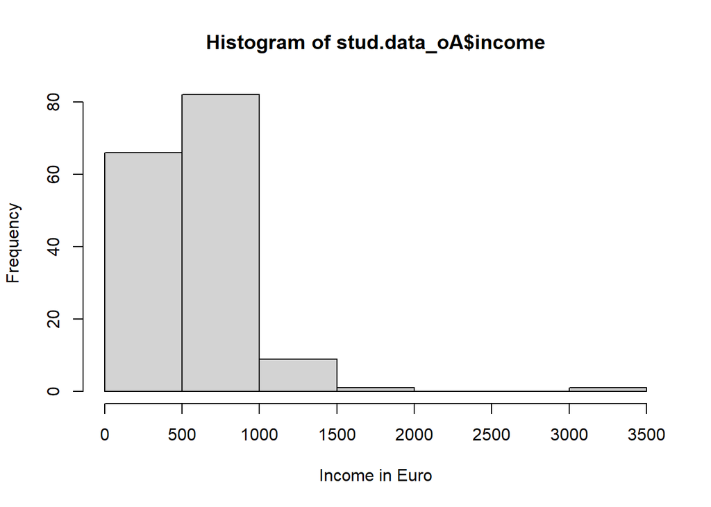

```r
summary(stud.data_oA$income); hist(stud.data_oA$income, xlab = "Income in Euro")
```

Die Verteilung der Stichprobe ist stark linkssteil (skewed to the right), so dass die Normalverteilungsannahme für die Grundgesamtheit klar verletzt ist. Auf Grund der großen Stichprobe können wir aber davon ausgehen, dass der Stichprobenmittelwert unabhängig von der Verteilung des Merkmals in der Grundgesamtheit näherungsweise t-verteilt mit df = n-1 ist.

Wir wollen ein 95%-KI für das mittlere Einkommen in der Grundgesamtheit berechnen.

1. Methode: “per Hand” mit Hilfe der Formel oben.

```r
n <- length(stud.data_oA$income); n
```

```
## [1] 159
```

```r
SE <- sd(stud.data_oA$income)/sqrt(n); SE
```

```
## [1] 30.151
```

```r
t <- qt(0.975, df = n - 1); t
```

```
## [1] 1.9751
```

```r
CI_low <- mean(stud.data_oA$income) - t*SE
CI_up <- mean(stud.data_oA$income) + t*SE
CI_low; CI_up
```

```
## [1] 546.94
```

```
## [1] 666.04
```

2. Methode: mit `t.test()`. Wir nutzen hier nur einen Teil des Outputs (vgl. für den Rest unten)

```r
t.test(stud.data_oA$income, xlab = "Einkommen in Euro")
```

```
##
##  One Sample t-test
##
## data:  stud.data_oA$income
## t = 20.1, df = 158, p-value <2e-16
## alternative hypothesis: true mean is not equal to 0
## 95 percent confidence interval:
##  546.94 666.04
## sample estimates:
## mean of x
##    606.49
```

Interpretation: Wenn man 100 Stichproben nach dieser Methode ziehen würde, würde man 100 unterschiedliche KIs erhalten. Von diesen 100 KIs werden im Mittel 95 den wahren Mittelwert beinhalten und 5 nicht. Unser KI, [547 Euro, 666 Euro], ist eines dieser 100 KIs. Das **Vertrauen** (“confidence”) bezieht sich also nicht auf das einzelne KI, sondern auf die **Methode**, solche Intervalle zu konstruieren. Kürzer: Wir können zu 95% darauf vertrauen, dass ein nach dieser Methode erzeugtes Intervall, das wahre mittlere Einkommen in der Grundgesamtheit beinhaltet. Unser KI, [547 Euro, 666 Euro], ist ein solches Intervall.

Bei einer großen Stichprobe ($n > 30$, das ist hier der Fall) können wir das Quantil der t-Verteilung durch das Quantil der $N(0,1)$-Verteilung approximieren. Hier im Beispiel ist - wie zu erwarten - die Abweichung sehr gering:

```r
t <- qt(0.975, df = n - 1); t # sollte nah an 1.96 sein
```

```
## [1] 1.9751
```

```r
z <- qnorm(0.975); z
```

```
## [1] 1.96
```

```r
CI_low_z <- mean(stud.data_oA$income) - z*SE
CI_up_z <- mean(stud.data_oA$income) + z*SE
CI_low_z; CI_up_z
```

```
## [1] 547.39
```

```
## [1] 665.58
```

#### Fall: $n \leq 30$ und $\sigma$ unbekannt

In diesem Fall (“kleine Stichprobe”) ist das KI wie oben definiert als:

$KI(1-\alpha)_{\mu}=\bar{x}\pm t_{n-1[1-\alpha/2]}\widehat{\sigma}_{\bar{X}}$

wenn (!) das Merkmal in der Grundgesamtheit normalverteilt ist. Diese Eigenschaft ist durch ein Histogramm bzw. qq-Plot der Stichprobenwerte zu prüfen (ggf. auch durch einen Shapiro-Wilk-Test auf Normalverteilung).

Betrachten wir das folgende Beispiel: Sie trinken in einer Kneipe mit Ihren Freunden ein paar Bier und möchten gerne wissen, wie viel Bier “im Mittel” pro Glas ausgeschenkt wird. Die Füllmengen der Gläser (in Liter) sind: 0.51, 0.48, 0.52, 0.47, 0.48, 0.40, 0.44, 0.43, 0.48, 0.49, 0.47, 0.45, 0.45, 0.46, 0.5.

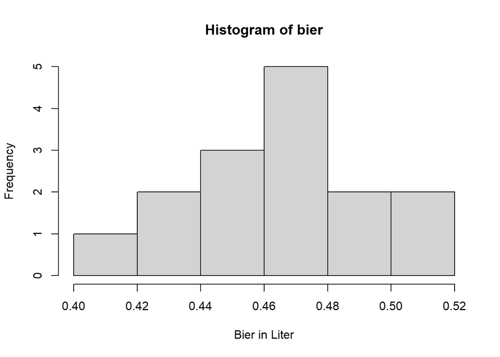

```r
bier <- c(0.51, 0.48, 0.52, 0.47, 0.48, 0.40, 0.44, 0.43, 0.48, 0.49, 0.47, 0.45, 0.45, 0.46, 0.5)
hist(bier, xlab = "Bier in Liter")
```

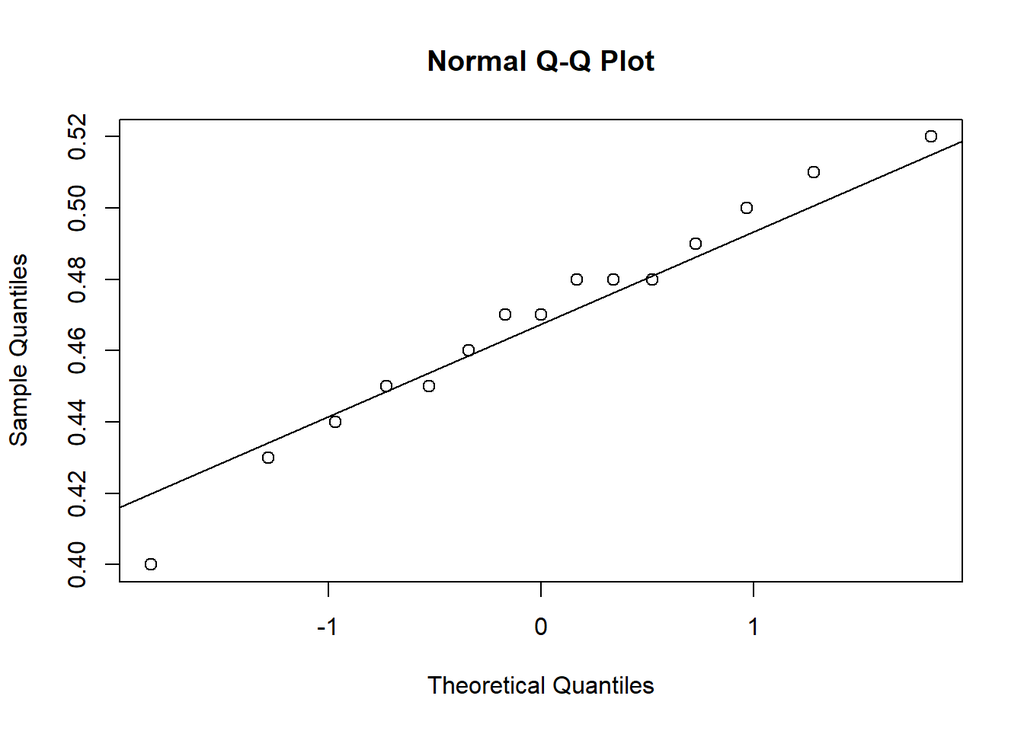

```r
qqnorm(bier, cex = 1.1); qqline(bier)
```

```r
shapiro.test(bier)
```

```
##
##  Shapiro-Wilk normality test
##
## data:  bier
## W = 0.979, p-value = 0.97
```

Die Normalverteilungsannahme kann als erfüllt angesehen werden (sie kann zumindest nicht verworfen werden).

Das KI berechnet sich folgendermaßen:

1. Methode: “per Hand” mit Hilfe der Formel oben.

```r
n <- length(bier); n
```

```
## [1] 15
```

```r
SE <- sd(bier)/sqrt(n); SE
```

```
## [1] 0.0081572
```

```r
t <- qt(0.975, df = n - 1); t
```

```
## [1] 2.1448
```

```r
CI_low <- mean(bier) - t*SE
CI_up <- mean(bier) + t*SE
CI_low; CI_up
```

```
## [1] 0.45117
```

```
## [1] 0.48616
```

2. Methode: mit `t.test()`. Wir nutzen hier nur einen Teil des Outputs (vgl. für den Rest unten)

```r
t.test(bier)
```

```
##
##  One Sample t-test
##
## data:  bier
## t = 57.5, df = 14, p-value <2e-16
## alternative hypothesis: true mean is not equal to 0
## 95 percent confidence interval:
##  0.45117 0.48616
## sample estimates:
## mean of x
##   0.46867
```

Interpretation: Wenn man 100 Stichproben nach dieser Methode ziehen würde, würde man 100 unterschiedliche KIs erhalten. Von diesen 100 KIs werden im Mittel 95 den wahren Mittelwert beinhalten und 5 nicht. Unser KI, [0.45 l, 0.49 l], ist eines dieser 100 KIs. Das **Vertrauen** (“confidence”) bezieht sich also nicht auf das einzelne KI, sondern auf die **Methode**, solche Intervalle zu konstruieren. Kürzer: Wir können zu 95% darauf vertrauen, dass ein nach dieser Methode erzeugtes Intervall, die wahre mittlere Biermenge in der Grundgesamtheit beinhaltet. Unser KI, [0.45 l, 0.49 l], ist ein solches Intervall. Man beachte, dass die Normmenge, 0.5 Liter, nicht im KI liegt. Dies ist ein Argument gegen die Behauptung, dass der Wirt 0.5 Liter pro Glas ausschenkt (vgl. unten zum Hypothesentest für dieses Beispiel).

#### Trade-off zwischen Präzision und Sicherheit

Aus der Formel zur Berechnung des KI ergibt sich, dass es zwei Optionen gibt, zu einer präziseren Aussage (also zu einem schmaleren KI) zu gelangen:

1. Reduzierung der Vertrauenswahrscheinlichkeit: Ein kleineres $1 - \alpha$ führt zu einem schmaleren KI, da sich das $(1-\alpha/2)$-Quantil der t-Verteilung dann verkleinert. Wir müssen also einen “Preis” (geringeres Vertrauen) für höhere Präzision zahlen.

Zum Beispiel für df = 10 und df = 100:

```r
qt(0.95, df = 10); qt(0.95, df = 100)   # 1 - alpha = 0.90
```

```
## [1] 1.8125
```

```
## [1] 1.6602
```

```r
qt(0.975, df = 10); qt(0.975, df = 100) # 1 - alpha = 0.95
```

```
## [1] 2.2281
```

```
## [1] 1.984
```

Werte unter 90% für die Vertrauenswahrscheinlichkeit sind unüblich.

2. Größere Stichprobe: Ein höheres $n$ reduziert den Standardfehler $SE = \widehat{\sigma}_{\bar{X}} = \frac{\widehat{\sigma}}{\sqrt{n}}$ und damit auch den Margin of Error. Zugleich wird auch der t-Wert kleiner, da mit einem höheren $df$-Wert der t-Wert von oben näher an den kleineren z-Wert heranrückt.

Es gibt also einen **trade-off** (“Abwägen” oder auch “Zielkonflikt”) zwischen **Präzision** der Aussage (Breite des KI) und der **Sicherheit** der Aussage (Vertrauen in KI). Eine höhere Sicherheit bzgl. der Aussage über $\mu$ geht einher mit geringerer Präzision und umgekehrt. Das ist das fundamentale Problem der schließenden Statistik. Glücklicherweise können wir oft mit Aussagen ausreichend präzise (gemessen durch den ME, abhängig vom Sachverhalt) und sicher (z.B. mit $1-\alpha=0.95$) sein.

### Hypothesentest für $\mu$

Die t-Verteilung kann nicht nur für die Berechnung eines Konfidenzintervalls für $\mu$, sondern auch zum Testen einer Hypothese bzgl. des wahren Mittelwerts $\mu$ verwendet werden.

#### Schrittfolge

Wir wollen eine Hypothese über einen unbekannten Parameter (Mittelwert $\mu$) in der Grundgesamtheit testen. Dazu nehmen wir die Hypothese als wahr an und vergleichen die Stichprobeninformation mit dem, was man unter Gültigkeit der Hypothese erwarten kann. Gibt es einen großen Unterschied zwischen der Erwartung basierend auf der Hypothese und Stichprobeninformation, verwerfen wir die Hypothese.

Wir werden im Folgenden mit folgender Schrittfolge für den Hypothesentest arbeiten:

*1) Hypothesen aufstellen und Signifikanzniveau (maximale Wahrscheinlichkeit für Fehler 1. Art, $\alpha$) festlegen.* Die Ausgangshypothese wird als Nullhypothese $H_0$ bezeichnet. $H_0$ wird als wahr angenommen. Das eigentlich interessante Ergebnis wird i.d.R. in der Alternativhypothese $H_A$ “versteckt”. Ziel ist letztlich die Ablehnung der Nullhypothese und die Akzeptanz der Alternative. Die Ablehnung von $H_0$ ist aber nur möglich, wenn wir begründete Zweifel an der Nullhypothese haben. Der Hypothesentest liefert Regeln, um diese “begründeten Zweifel” zu belegen.

Es werden zweiseitige und einseitige Tests unterschieden (je nach Richtung der $H_A$):

- zweiseitig: $H_0$: $\mu = \mu_0$ vs. $H_A: \mu \neq \mu_0$
- oberseitig: $H_0: \mu = \mu_0$ vs. $H_A: \mu > \mu_0$
- unterseitig: $H_0: \mu = \mu_0$ vs. $H_A: \mu < \mu_0$

Die Überlegungen zum Fehler 1. Art und 2. Art sind exakt die gleichen wie beim Einstichproben-$z$-Test.

*2) Festlegung der Testverteilung und der Testvariable ($T$).* Wenn die Standardabweichung der Grundgesamtheit unbekannt ist (und dies ist in der Praxis die Regel), sind zwei Fälle zu unterscheiden:

- große Stichprobe $n > 30$

In diesem Fall gilt: $\frac{\bar{X}-\mu_0}{\widehat{\sigma}_{\bar{X}}} = T \sim T_{n-1}$ und die Approximation $T \approx Z$ ist möglich.

- kleine Stichprobe $n \leq 30$

In diesem Fall gilt: $\frac{\bar{X}-\mu_0}{\widehat{\sigma}_{\bar{X}}} = T \sim T_{n-1}$, wenn das Merkmal in der Grundgesamtheit normalverteilt ist.

*3) Berechnung der Prüfgröße $t$ und des p-value.* Der empirische Wert der Testvariable $T$, die Prüfgröße $t$, berechnet sich folgendermaßen:

$t = \frac{\bar{x} - \mu_0}{\widehat{\sigma}_{\bar{X}}}$

Der **p-value** berechnet sich:

- zweiseitig: p-value = $2(1 - F_{t}(|t|,n-1))$
- unterseitig: p-value = $F_{t}(t,n-1)) = 1 - F_{t}(|t|,n-1)$
- oberseitig: p-value = $1 - F_{t}(t,n-1))$

mit $F_{t}(t, n-1)$ als Verteilungsfunktion der t-Verteilung mit df = n-1.

*4) Entscheidung und Interpretation.* Die Entscheidung basierend auf dem p-value erfolgt nach der Regel: Ablehnung von $H_0$, wenn p-value < $\alpha$ (alternativ über den Vergleich von t-Wert und dem kritischen Wert der t-Verteilung, vgl. Lehrbuch). Die Interpretation der Entscheidung über $H_0$ hat (wie die Interpretation des p-value) im Kontext zu erfolgen.

Der hier erläuterte Test wird auch **Einstichproben-t-Test** (one sample t-test) genannt.

#### Beispiel

Sie trinken in einer Kneipe mit Ihren Freunden ein paar Bier und vermuten, dass der Wirt zu wenig ausschenkt. Die Füllmengen der Gläser (in Liter) sind: 0.51, 0.48, 0.52, 0.47, 0.48, 0.40, 0.44, 0.43, 0.48, 0.49, 0.47, 0.45, 0.45, 0.46, 0.5. Man soll hier seine Vermutung durch einen Hypothesentest untermauern (vgl. oben, auch zur Prüfung der Annahmen). Das Signifikanzniveau sei 0.05.

```r
bier <- c(0.51, 0.48, 0.52, 0.47, 0.48, 0.40, 0.44, 0.43, 0.48, 0.49, 0.47, 0.45, 0.45, 0.46, 0.5)
summary(bier)
```

```
##    Min. 1st Qu.  Median    Mean 3rd Qu.    Max.
##   0.400   0.450   0.470   0.469   0.485   0.520
```

Die Hypothesen sind $H_0: \mu = 0.5$ vs. $H_A: \mu < 0.5$. Wir testen also unterseitig, da uns nur die Abweichung nach unten interessiert. Es liegt eine kleine Stichprobe vor und die Stichprobenwerte folgen näherungsweise einer Normalverteilung. Wir können also $T$ als Testvariable verwenden und aus der Prüfgröße einen p-value berechnen. Darüber hinaus können wir von einer in Relation zur Grundgesamtheit kleinen Zufallsstichprobe ausgehen.

Methode 1:

```r
n <- length(bier)
sigma_x_dach <- sd(bier)/sqrt(n)
t <- abs((mean(bier) - 0.5)/sigma_x_dach); t
```

```
## [1] 3.8412
```

```r
p.value <- 1 - pt(t, df = n - 1); p.value
```

```
## [1] 0.00089925
```

Methode 2:

```r
t.test(bier, mu = 0.5, alternative = "less")
```

```
##
##  One Sample t-test
##
## data:  bier
## t = -3.84, df = 14, p-value = 0.0009
## alternative hypothesis: true mean is less than 0.5
## 95 percent confidence interval:
##     -Inf 0.48303
## sample estimates:
## mean of x
##   0.46867
```

Das Ergebnis des unterseitigen Tests ist ein p-value von 0.09%. Wenn also tatsächlich der wahre Mittelwert aller ausgeschenkten Biere gleich 0.5 Liter ist, dann ist die Wahrscheinlichkeit, bei einer Zufallsstichprobe von 15 Bieren einen Mittelwert von 0.469 Liter oder weniger zu finden, gleich 0.09%. Es ist also extrem unwahrscheinlich, ein solches Ergebnis oder noch kleinere Werte zufällig zu beobachten, wenn der Wirt im Mittel tatsächlich 0.5 Liter ausschenkt. Auf Grund dieser geringen Wahrscheinlichkeit verwerfen wir $H_0$ und nehmen $H_A$ an. Es wird also statistisch signifikant zu wenig Bier ausgeschenkt.

Als Maß für die Effektgröße (ökonomische Signifikanz) wird Cohen’s $d$ berechnet (vgl. Exkurs unten).

#### Statistische vs. ökonomische Signifikanz

Der empirische Wert der Testvariablen $t = (\bar{x} - \mu_0)/\widehat{\sigma}_{\bar{X}}$ (<=> p-value) ist der Indikator für statistische Signifikanz und damit für die Frage, ob ein bestimmtes Stichprobenergebnis oder extremere Werte sich zufällig ergeben haben können. Ist $t$ betragsmäßig groß (und damit der p-value klein, d.h. < $\alpha$) spricht man von einem “statistisch signifikanten” Resultat. In diesem Fall können wir also davon ausgehen, dass das beobachtete Stichprobenergebnis nicht zufällig zustandegekommen ist. $H_0$ wird verworfen und $H_A$ angenommen.

Die Effektgröße $|\bar{x} - \mu_0|$ ist hingegen der Indikator für ökonomische Signifikanz, also für die Abweichung zwischen dem beobachteten Stichprobenwert und dem als wahr angenommenen Wert in der Nullhypothese (als Maßzahl wird hier i.d.R. Cohen’s $d$ genutzt, vgl. Exkurs). Unter sonst gleichen Bedingungen steigt die statistische Signifikanz mit der Effektgröße. Das Problem ist aber: Es gibt ökonomisch signifikante Effekte, die nicht statistisch signifikant sind und umgekehrt. Entscheidend ist hierbei die **Stichprobengröße**. Wenn $n$ klein ist, ist $\widehat{\sigma}_{\bar{X}} = \frac{\widehat{\sigma}}{\sqrt{n}}$ groß, $t$ ist dann klein und es liegt auch bei einer relativ großen Effektgröße keine statistische Signifikanz vor. Ist hingegen $n$ groß, kann auch eine relativ kleine Effektgröße statistisch signifikant werden. Mit anderen Worten: jede noch so kleine Effektgröße kann durch ein hinreichend großes $n$ “statistisch signifikant” werden. Ziel ist daher, mit relativ geringem $n$ statistisch signifikante Effekte zu zeigen. Man sollte daher bei der Präsentation von Testergebnissen immer Effektgröße, Prüfgröße, $n$ und den p-value angeben. Dann wird deutlich, ob man statistische Signifikanz durch eine übergroße Stichprobengröße erzeugt hat.

#### Exkurs: Fehler 2. Art

In diesem Exkurs soll gezeigt werden, wie der Fehler 2. Art für den Einstichproben-t-Test berechnet werden kann. Der Fehler 1. Art ($\alpha$) besteht darin, $H_0$ zu verwerfen, obwohl diese Hypothese wahr ist. Der Fehler 2. Art ($\beta$) besteht darin, $H_0$ zu nicht verwerfen, obwohl diese Hypothese falsch ist. Mit $1-\beta$ wird die **Power** (Teststärke) eines Hypothesentests bezeichnet. Die Power gibt an, mit welcher Wahrscheinlichkeit man eine falsche $H_0$ richtigerweise verwirft. Mit anderen Worten: Die Power gibt an, wie gut ein Test einen echten Effekt findet.

Beispiel: Angenommen, wir möchten die Nullhypothese testen, dass eine Variable X einen Mittelwert von 100 hat, gegenüber der Alternativhypothese, dass der Mittelwert größer als 100 ist. Zudem sei angenommen, frühere Studien haben gezeigt, dass die Standardabweichung $\sigma=40$ ist. Es wird eine Zufallsstichprobe $n=100$ genutzt.

Zunächst berechnen wir über das 95%-Quantil der t-Verteilung mit df = 99 den kritischen Wert $t_{crit}=106.6$. Wenn der aus der Stichprobe berechnete Mittelwert größer als 106.6 ist, wird die Nullhypothese, dass der Mittelwert 100 beträgt, verworfen. Andernfalls wird die Nullhypothese nicht verworfen. Wir bezeichnen den Bereich größer als 106.6 als Ablehnungsbereich und Werte kleiner oder gleich 106.6 als Akzeptanz- oder Nichtverwerfungsbereich des Signifikanztests.

```r
SE <- 40/sqrt(100); SE
```

```
## [1] 4
```

```r
t_crit <- qt(0.95, df = 99); t_crit
```

```
## [1] 1.6604
```

```r
t_crit*SE + 100 # z = (x - mu)/s
```

```
## [1] 106.64
```

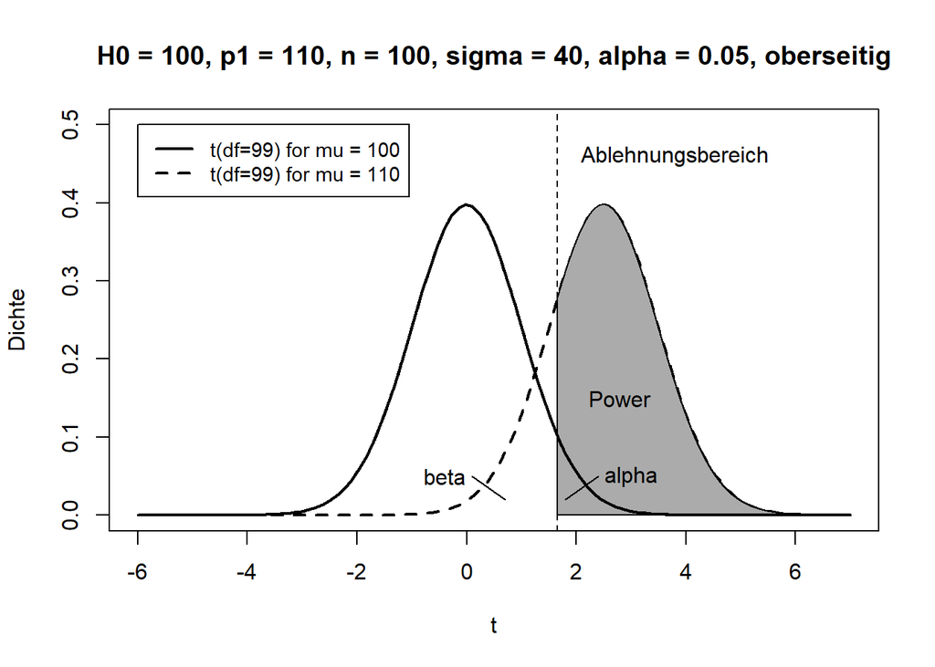

```r
# Koordinaten für polygon() unten
cord.x1 <- c(1.66,seq(1.6604,6,0.001), 1.6604)
cord.y1 <- c(0,dt(seq(1.6604,6,0.001) - 2.5, df = 99),0)

curve(dt(x, df = 99), xlab = "t", lwd = 2,
main= "H0 = 100, p1 = 110, n = 100, sigma = 40, alpha = 0.05, oberseitig",
ylab = "Dichte", xlim = c(-6, 7), ylim = c(0, 0.5))
abline(v = 1.66, lty = 2)
curve(dt(x - 2.5, df = 99), add = TRUE, lty = 2, lwd = 2)
text(3.8, 0.46, "Ablehnungsbereich")
legend(-6, 0.5, c("t(df=99) for mu = 100", "t(df=99) for mu = 110"),
       lty = c(1, 2), lwd = c(2,2), cex = 0.9)
polygon(cord.x1, cord.y1, col = 'gray67')
curve(dt(x, df = 99), xlab = "t", lwd = 2, add = TRUE)
curve(dt(x, df = 99), xlab = "t", lwd = 2, add = TRUE, lty = 2)
text(3, 0.05, "alpha"); text(-0.4, 0.05, "beta"); text(2.8, 0.15, "Power")
segments(0.1, 0.05, 0.7, 0.02); segments(1.8, 0.02, 2.4, 0.05)
```

```r
# distance from 1.6604 to 2.5 = 2.5 - 1.6604 = 0.8396
beta <- pt(-0.8396, df = 99); beta
```

```
## [1] 0.20158
```

```r
power <- 1 - beta; power
```

```
## [1] 0.79842
```

In R kann die Power berechnet werden mit:

```r
power.t.test(n = 100, delta = 10, sd = 40, sig.level = 0.05,
             type = c("one.sample"),
             alternative = c("one.sided"))
```

```
##
##      One-sample t test power calculation
##
##               n = 100
##           delta = 10
##              sd = 40
##       sig.level = 0.05
##           power = 0.79899
##     alternative = one.sided
```

Wenn man keine gerichtete Hypothese hat (was meistens der Fall ist), muss man zweiseitig testen. In der Abbildung oben wird deutlich, dass bei einem zweiseitigen Test der Ablehnungsbereich nach rechts geht und damit die Power kleiner ist. Wir wiederholen die Berechnungen oben, jetzt aber für einen zweiseitigen t-Test.

```r
SE <- 40/sqrt(100); SE
```

```
## [1] 4
```

```r
t_crit <- qt(0.975, df = 99); t_crit
```

```
## [1] 1.9842
```

```r
t_crit*SE + 100 # z = (x - mu)/s
```

```
## [1] 107.94
```

```r
# distance from 1.9842 to 2.5 = 2.5 - 1.9842 = 0.5158
beta <- pt(-0.5158, df = 99); beta
```

```
## [1] 0.30357
```

```r
power <- 1 - beta; power
```

```
## [1] 0.69643
```

```r
power.t.test(n = 100, delta = 10, sd = 40, sig.level = 0.05,
             type = c("one.sample"),
             alternative = c("two.sided"))
```

```
##
##      One-sample t test power calculation
##
##               n = 100
##           delta = 10
##              sd = 40
##       sig.level = 0.05
##           power = 0.69698
##     alternative = two.sided
```

Die Power ist jetzt nur noch ca. 70%.

Auch hier wollen wir die Power für dieses Beispiel (one-sided, vgl. oben) mit einer Simulation verdeutlichen.

```r
# Simulation for H0: mu = 100 vs. HA: mu > 100 (one-sided, upper tail, alpha = 0.05), n = 100
set.seed(3); pop1 <- rnorm(100000000, 110, 40)
mean(pop1); sd(pop1)
```

```
## [1] 110
```

```
## [1] 39.998
```

```r
sample_mean <- c()
sample_sd <- c()
for(i in 1:100000) {set.seed(i); sample_mean[i] = mean(sample(pop1, size = 100, replace = TRUE))}
for(i in 1:100000) {set.seed(i); sample_sd[i] = sd(sample(pop1, size = 100, replace = TRUE))}
SE <- sample_sd/sqrt(100)
mean_st <- (sample_mean - 100)/SE
# hist(mean_st)
```

Wir verwerfen $H_0$, wenn der Mittelwert der Stichprobe > $t_{crit}$ ist. Hier ist $t_{crit} = 1.6604$, das 95%-Quantil der t-Verteilung bei df = 99.

```r
table(mean_st > 1.6604)
```

```
##
## FALSE  TRUE
## 20049 79951
```

Wir verwerfen $H_0$ in 80% der Fälle und treffen dann die richtige Entscheidung. Wir verwerfen $H_0$ nicht (“false negative”) in 20% der Fälle und treffen dann die falsche Entscheidung.

## Inferenz für zwei Stichproben (nicht klausurrelevant)

Wir betrachten hier den t-Test für zwei unabhängige Stichproben (Welch-Test) und den t-Test für zwei abhängige Stichproben.

### Zweistichproben-t-Test

Dieser Test wird auch Welch-Test oder two sample t-test genannt. Die Frage ist hier, ob es einen Unterschied zwischen den arithmetischen Mitteln in zwei Grundgesamtheiten, $X$ und $Y$, gibt.

Die Hypothesen sind also:

$H_0: \mu_X = \mu_Y$ bzw. $H_0: \mu_X - \mu_Y = \Delta_0$, wobei üblicherweise $\Delta_0 = 0$, vs. $H_A$: entsprechend zweiseitig oder einseitig.

Testvariable:

$T = \frac{(\bar{x} - \bar{y} - \Delta_0)} {SE(\bar{x} - \bar{y})} \sim T_{df}$

mit

$SE(\bar{x} - \bar{y}) = \sqrt{\frac{\widehat{\sigma}^2_X}{n_X} + \frac{\widehat{\sigma}^2_Y}{n_Y}}$

$T$ folgt einer t-Verteilung mit $df$ als Zahl Freiheitsgrade und $df = \frac{Z}{N}$, wobei

$Z = (\frac{\widehat{\sigma}^2_X}{n_X} + \frac{\widehat{\sigma}^2_Y}{n_Y})^2$

$N = \frac{1}{n_X - 1}(\frac{\widehat{\sigma}^2_X}{n_X})^2 + \frac{1}{n_Y - 1}(\frac{\widehat{\sigma}^2_Y}{n_Y})^2$

Es gibt folgende Annahmen:

1. Unabhängigkeit der Beobachtungen: Idealerweise Zufallsstichprobe aus beiden Grundgesamtheiten. Kleiner Auswahlsatz mit $n/N\leq0.05$.
2. Normalverteilungsannahme: Beide Grundgesamtheiten folgen einer Normalverteilung. Diese Annahme ist nur bei kleinen Stichproben ($n \leq 30$) nötig. Prüfen mit Histogramm bzw. qq-Plot und Shapiro-Wilk-Test. Bei Verletzung dieser Annahme kann der MWU-Test (vgl. Lehrbuch) genutzt werden.
3. Unabhängige Gruppen: Es darf keinerlei Beeinflussung der Gruppen untereinander geben. Bei Abhängigkeit ist der gepaarte t-Test (vgl. unten) zu verwenden.

Betrachten wir Bsp. 11.1 (vgl. Lehrbuch S. 246, S. 267).

Das Problem: 45 Nutzer von Kreditkarten erhalten Bonus-Punkte, 45 andere Nutzer dagegen nicht. Frage: Haben Bonus-Punkte einen umsatzsteigernden Effekt? Es gibt 45+45=90 Beobachtungen (große Stichprobe) für die Veränderungen der Ausgaben innerhalb von 6 Monaten.

```r
setwd("C:/Users/sturm/Desktop/dataR")   # setze das Arbeitsverzeichnis
data <- read.csv("Bsp._11.1.csv")
# data <- read.csv("https://raw.githubusercontent.com/bodosturm/dataR/main/Bsp._11.1.csv")
attach(data); data[1:2, ] # B = Bonus, kB = kein Bonus
```

|  | X | B | kB |
| --- | --- | --- | --- |
| 1 | 1 | 360.98 | -442.41 |
| 2 | 2 | -142.79 | -471.71 |

```r
nB <- length(B); nkB <- length(kB)
```

Zunächst vergleichen wir die Verteilungen.

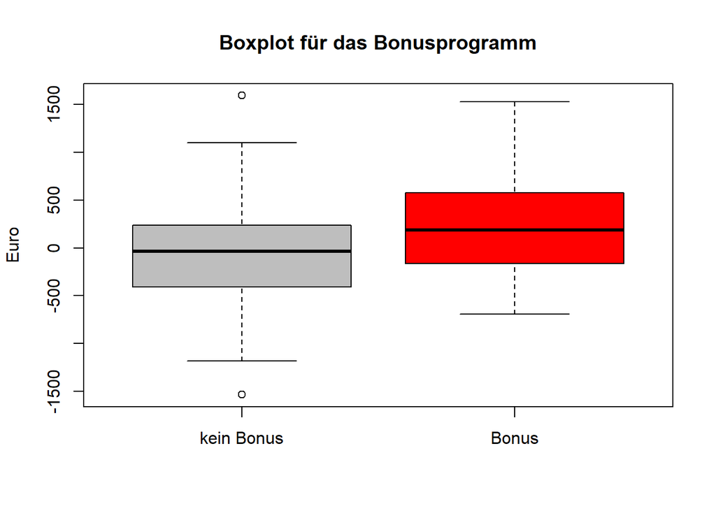

```r
boxplot(kB, B, col = c("grey", "red"), ylab = "Euro",
main = "Boxplot für das Bonusprogramm",
names = c("kein Bonus", "Bonus"))
```

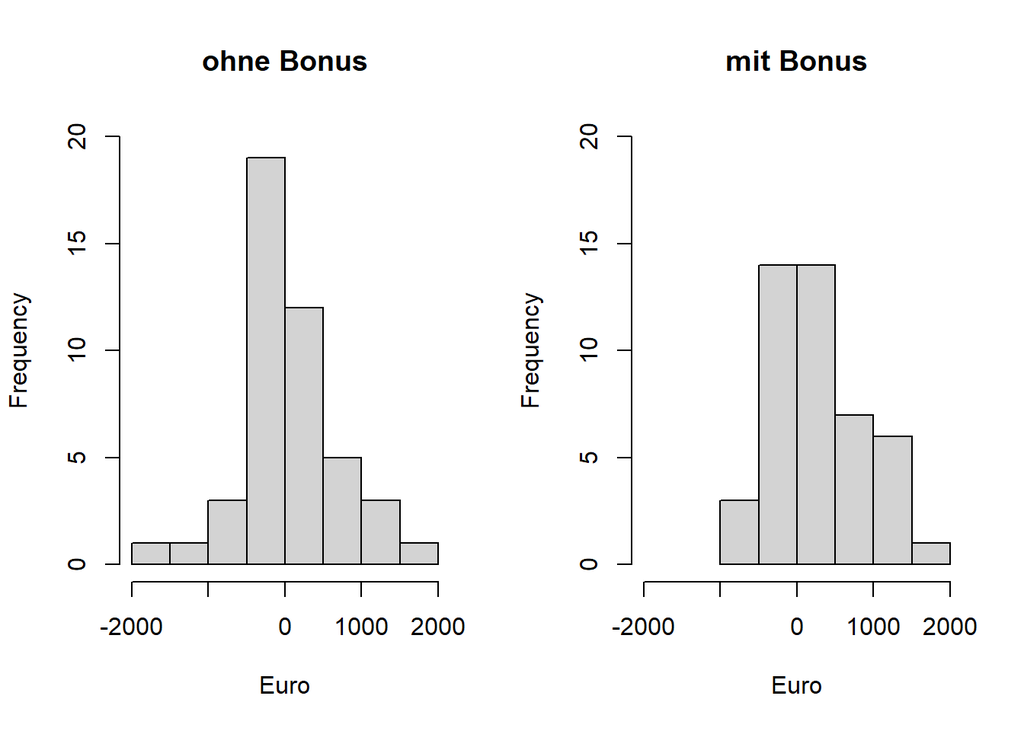

```r
par(mfrow = c(1,2))  # beide Abbildungen in 1 Zeile & 2 Spalten
hist(kB, xlab = "Euro", main = "ohne Bonus", ylim = c(0, 20), xlim = c(-2000, 2000))
hist(B, xlab = "Euro", main = "mit Bonus", ylim = c(0, 20), xlim = c(-2000, 2000))
```

```r
par(mfrow = c(1,1))  # zurücksetzen auf 1 Zeile & 1 Spalte
```

Der Boxplot zeigt, dass es einen deutlichen Unterschied zwischen den Ausgaben gibt. Mit Bonus sind die Ausgaben im Mittel größer als ohne. Dieser Unterschied könnte aber auch zufällig zustande gekommen sein. Um unsere Vermutung bzgl. des Bonus-Effektes zu untermauen, führen wir einen Hypothesentest durch.

Wir testen $H_0: \mu_X = \mu_Y$ vs. $H_A: \mu_X > \mu_Y$ zu $\alpha = 0.05$. Wir testen hier oberseitig, da wir davon ausgehen können, dass der Bonus einen positiven Effekt hat.

```r
t.test(B, kB, alt = "greater")
```

```
##
##  Welch Two Sample t-test
##
## data:  B and kB
## t = 2, df = 88, p-value = 0.025
## alternative hypothesis: true difference in means is greater than 0
## 95 percent confidence interval:
##  41.67   Inf
## sample estimates:
## mean of x mean of y
##  251.4054    1.8388
```

Interpretation: Wenn es in der Grundgesamtheit keinen Unterschied zwischen den mittleren zusätzlichen Ausgaben mit und ohne Bonus gibt (wenn also $H_0$ wahr wäre), liegt die Wahrscheinlichkeit bei einer Zufallsstichprobe von 90 Teilnehmern eine Abweichung zwischen den mittleren Ausgaben wie in der Stichprobe oder größer zu beobachten, bei 2.5%. Wir verwerfen also die Nullhypothese (kein Unterschied) und nehmen die Alternative (Mittel mit Bonus ist größer als ohne) an. Es gibt also einen positiven und statistisch signifikanten Effekt des Bonusprogramms auf die Ausgaben.

Was noch fehlt, ist die Berechnung des Tests “per Hand”. Zu berechnen ist der Wert für $df$, die Teststatistik $t$ und schließlich der p-value.

```r
n_x <- 45; n_y <- 45
var_x <- var(B); var_y <- var(kB)
SE <- sqrt(var_x/n_x + var_y/n_y)

Z <- (var_x/n_x + var_y/n_y)^2
N <- (1/(n_x - 1))*(var_x/n_x)^2 + (1/(n_y - 1))*(var_y/n_y)^2
df <- Z/N; df                        # exakt der für df im R Output
```

```
## [1] 87.979
```

```r
t <- (mean(B) - mean(kB))/SE; t      # exakt der für df im R Output
```

```
## [1] 1.9956
```

```r
pnorm(1.96)
```

```
## [1] 0.975
```

```r
p_value <- 1 - pt(t, df); p_value    # exakt der für df im R Output
```

```
## [1] 0.024538
```

Betrachten wir nun das zum Welch-Test korrespondierende KI

$KI(1-\alpha)_{\mu{_X}-\mu{_Y}} =(\bar{x}-\bar{y})\pm t_{n-1[1-\alpha/2]}SE(\bar{x}-\bar{y})$

Für die Berechnung des 95%-KI ist es nötig, einen zweiseitigen Test durchzuführen.

```r
t.test(B, kB, alt = "two.sided", conf.level = 0.95)
```

```
##
##  Welch Two Sample t-test
##
## data:  B and kB
## t = 2, df = 88, p-value = 0.049
## alternative hypothesis: true difference in means is not equal to 0
## 95 percent confidence interval:
##    1.0333 498.1000
## sample estimates:
## mean of x mean of y
##  251.4054    1.8388
```

```r
#t.test(B, kB, alt = "two.sided", conf.level = 0.90) # schmaleres KI
```

Das 95%-KI für die wahre Differenz der Mittelwerte ist [1.03 Euro, 498.10 Euro]. Die “quick & dirty”-Interpretation ist: Mit 95% Wahrscheinlichkeit liegt die wahre mittlere Veränderung der Ausgaben im Intervall [1.03 Euro, 498.10 Euro]. Richtig wäre: Wenn wir 100 solcher Zufallsstichproben ziehen würden, würden sich 100 verschiedene KIs ergeben. Von diesen 100 KIs werden im Mittel 95 den wahren mittleren Unterschied beinhalten und 5 nicht. Unser KI [1.03 Euro, 498.10 Euro] ist eines dieser 100 KIs. Ein solches KI macht Sinn für Berechnungen, ob ein solches Bonus-Programm profitabel ist (worst case, best case).

Der Zweistichproben-t-Test mit Varianzhomogenität wird hier nicht behandelt (vgl. Lehrbuch zu den Gründen). In `t.test()` muss dann `var.equal = TRUE` gesetzt werden.

#### Exkurs: Messung der Effektgröße (effect size) mit Cohen’s d

Cohen’s $d$ ist eines der am häufigsten verwendeten Maße für die Effektgröße und beschreibt, wie stark sich die Mittelwerte zweier Stichproben unterscheiden (es kann aber auch für eine Stichprobe berechnet werden, vgl. unten). Da Cohen’s $d$ ein standardisiertes Abstandsmaß ist, ist es unerheblich, in welcher Einheit die Variable erhoben wurde. Denn durch die Standardisierung werden die Mittelwerte auf eine neue, gemeinsame und dimensionslose Einheit gebracht und dadurch direkt vergleichbar. Ein weiterer Vorteil ist, dass Cohen’s $d$ im Gegensatz zum p-Wert nicht von der Stichprobengröße abhängt. Aufgrund der Berechnung von Mittelwerten wird Cohen’s $d$ i.d.R. nur bei metrischen Skalen (<=> quantitative Daten, Zahlen mit Einheiten) angewendet.

Berechnung von Cohen’s $d$:

$d = \frac{\bar{x}_A - \bar{x}_B}{\widehat\sigma_{AB}}$

mit $\widehat\sigma_{AB}$ als Standardabweichung.

Für die Standardabweichung gibt es zwei Berechnungsmethoden:

1. Wenn die Stichprobengröße beider Gruppen (X und Y) gleich ist: $\widehat\sigma_{XY} = \sqrt{\frac{\widehat\sigma^2_{X} + \widehat\sigma^2_{Y}}{2}}$
2. Wenn die Stichprobengröße beider Gruppen (X und Y) ungleich ist: $\widehat\sigma_{XY} = \sqrt{\frac{\widehat\sigma^2_{X}n_X + \widehat\sigma^2_{Y}n_Y}{n_X+n_Y}}$

Für die Interpretation der mit $d$ gemessenen Mittelwertunterschiede gilt folgende Regel: vernachlässigbar für |$d$| <= 0.2, klein für 0.2 < |$d$| <= 0.5, mittel für 0.5 < |$d$| <= 0.8 und groß für |$d$| > 0.8.

Ein Beispiel für den Einstichproben-t-Test (vgl. oben), wobei die Nullhypothese $\mu_0=0.5$ ist:

```r
library(rstatix) # muss installiert sein
bier <- c(0.51, 0.48, 0.52, 0.47, 0.48, 0.40, 0.44, 0.43, 0.48, 0.49, 0.47, 0.45, 0.45, 0.46, 0.5)
# Die Daten müssen in einem data frame stehen.
data <- data.frame(bier); head(data, 2)
```

|  | bier |
| --- | --- |
| 1 | 0.51 |
| 2 | 0.48 |

```r
cohens_d(bier ~ 1, data = data, mu = 0.5) # ~1 bedeutet: Es gibt nur eine Variable
```

|  | .y. | group1 | group2 | effsize | n | magnitude |
| --- | --- | --- | --- | --- | --- | --- |
| 1 | bier | 1 | null model | -0.99179 | 15 | large |

```r
# per Hand
d <- (mean(bier) - 0.5)/sd(bier); round(d, 3)
```

```
## [1] -0.992
```

Hier ist |$d$| = 0.992, was als ein großer Effekt eingeschätzt werden kann. Die Abweichung von der Nullhypothese $\mu_0=0.5$ nach unten beträgt 0.992 Standardabweichungen (also ca. 1 SD). Der Effekt ist also sowohl ökonomisch (<=> Effektgröße) als auch statistisch (p-value < 0.05) signifikant.

Ein Beispiel für den Zweistichproben-t-Test (vgl. oben):

```r
setwd("C:/Users/sturm/Desktop/dataR")   # setze das Arbeitsverzeichnis
data <- read.csv("Bsp._11.1.csv")
head(data, 2)
```

|  | X | B | kB |
| --- | --- | --- | --- |
| 1 | 1 | 360.98 | -442.41 |
| 2 | 2 | -142.79 | -471.71 |

```r
# data in long format = alle Werte in einer Spalte
value <- c(data$B, data$kB); value[1:4]
```

```
## [1]  360.98 -142.79  696.45 1177.23
```

```r
length(data$B)
```

```
## [1] 45
```

```r
treat <- c(rep("B", 45), rep("kB", 45))
data <- data.frame(treat, value)
head(data, 2)
```

|  | treat | value |
| --- | --- | --- |
| 1 | B | 360.98 |
| 2 | B | -142.79 |

```r
cohens_d(value ~ treat, data = data, mu = 0, var.equal = FALSE)
```

|  | .y. | group1 | group2 | effsize | n1 | n2 | magnitude |
| --- | --- | --- | --- | --- | --- | --- | --- |
| 1 | value | B | kB | 0.4207 | 45 | 45 | small |

```r
# per Hand
diff <- mean(value[treat == "B"]) - mean(value[treat == "kB"]); diff
```

```
## [1] 249.57
```

```r
var_X <- var(value[treat == "B"]); var_Y <- var(value[treat == "kB"])
n_X <- length(value[treat == "B"]); n_Y <- length(value[treat == "kB"])
sd_XY <- sqrt((var_X*n_X + var_Y*n_Y)/(n_X + n_Y))
d <- diff/sd_XY; round(d, 3)
```

```
## [1] 0.421
```

#### Exkurs: A-priori-Power-Analyse

In diesem Exkurs soll gezeigt werden, wie man eine a-priori-Power-Analyse für einen zweiseitigen t-Test durchführt. Eine a-priori-Power-Analyse ist eine statistische Methode, die vor der Datenerhebung durchgeführt wird, um die benötigte Stichprobengröße ($n$) zu bestimmen, die nötig ist, um einen erwarteten Effekt mit einer bestimmten Wahrscheinlichkeit (Power) zu entdecken und eine verlässliche Entscheidung zu treffen. Sie ist essenziell für eine gute Versuchsplanung und legt Signifikanzniveau ($\alpha$), Teststärke (Power = $1-\beta$) und die minimale Effektgröße fest, um eine aussagekräftige Schlussfolgerung zu ermöglichen.

Wir nutzen hier den Befehl `power.t.test()` für einen zweiseitigen Test. Wir setzen $d$ auf 0.2, 0.4, 0.6, 0.8 und 1. Der Befehl berechnet dann die Power gemäß APES (vgl. oben).

```r
library(stats) # muss installiert sein
pwrn10 <- power.t.test(n = 10, delta = seq(0.2, 1, 0.2), sd = 1, sig.level = 0.05,
                       power = NULL, type = "two.sample", alt = "two.sided")
pwrn10$power
```

```
## [1] 0.062265 0.132966 0.245322 0.394943 0.561985
```

```r
pwrn20 <- power.t.test(n = 20, delta = seq(0.2, 1, 0.2), sd = 1, sig.level = 0.05,
                       power = NULL, type = "two.sample", alt = "two.sided")
pwrn30 <- power.t.test(n = 30, delta = seq(0.2, 1, 0.2), sd = 1, sig.level = 0.05,
                       power = NULL, type = "two.sample", alt = "two.sided")
pwrn40 <- power.t.test(n = 40, delta = seq(0.2, 1, 0.2), sd = 1, sig.level = 0.05,
                       power = NULL, type = "two.sample", alt = "two.sided")
pwrn50 <- power.t.test(n = 50, delta = seq(0.2, 1, 0.2), sd = 1, sig.level = 0.05,
                       power = NULL, type = "two.sample", alt = "two.sided")
pwrn50$power
```

```
## [1] 0.16609 0.50815 0.84388 0.97728 0.99861
```

```r
pwr0.2 <- c(pwrn10$power[1], pwrn20$power[1], pwrn30$power[1], pwrn40$power[1], pwrn50$power[1])
pwr0.2
```

```
## [1] 0.062265 0.089581 0.115434 0.140849 0.166088
```

```r
pwr0.4 <- c(pwrn10$power[2], pwrn20$power[2], pwrn30$power[2], pwrn40$power[2], pwrn50$power[2])
pwr0.6 <- c(pwrn10$power[3], pwrn20$power[3], pwrn30$power[3], pwrn40$power[3], pwrn50$power[3])
pwr0.8 <- c(pwrn10$power[4], pwrn20$power[4], pwrn30$power[4], pwrn40$power[4], pwrn50$power[4])
pwr1.0 <- c(pwrn10$power[5], pwrn20$power[5], pwrn30$power[5], pwrn40$power[5], pwrn50$power[5])
n <- c(10, 20, 30, 40, 50)
```

Wir erstellen nun einen Plot, in dem wir die Stichprobengröße auf die x-Achse und die Power auf die y-Achse setzen. In diesem Plot gibt es fünf Funktionen, je eine für $d$ = 0.2, 0.4, 0.6, 0.8 und 1.0. Um eine Power von 80% zu erreichen, benötigt man bei $d$ = 1.0 eine Stichprobe von (approx.) n = 18, bei $d$ = 0.8 von n = 26 und bei $d$ = 0.6 von n = 45. Wie zu erwarten: Bei größerer Effektstärke steigt die Power für eine gegebene Stichprobengröße bzw. für eine gegebene Effektstärke steigt die Power mit größerer Stichprobe.

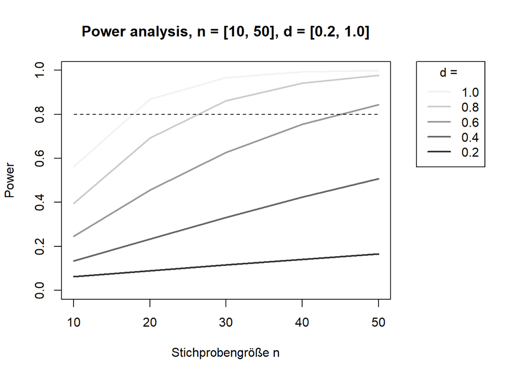

```r
par(mar=c(5.1, 4.1, 4.1, 9), xpd=TRUE)
plot(n, pwr0.2, type = "l", ylim = c(0,1),
main = "Power analysis, n = [10, 50], d = [0.2, 1.0]", xlim = c(10, 50),
xlab = "Stichprobengröße n", ylab = "Power",
col = "grey20", lwd = 2)
lines(n, pwr0.4, type = "l", col = "grey40", lwd = 2)
lines(n, pwr0.6, type = "l", col = "grey60", lwd = 2)
lines(n, pwr0.8, type = "l", col = "grey80", lwd = 2)
lines(n, pwr1.0, type = "l", col = "grey95", lwd = 2)
segments(10, 0.8, 50, 0.8, lty = 2)
legend(55, 1.04, lwd = c(rep(2, 10)), title = "d = ",
c("1.0", "0.8", "0.6", "0.4", "0.2"), inset=c(-0.2,0),
col = c("grey95","grey80","grey60","grey40","grey20"),
cex = 1)
```

### t-Test für gepaarte Stichproben

Dieser Test wird auch paired t-test genannt. Die Frage ist hier, ob es einen Unterschied zwischen den arithmetischen Mitteln zweier verbundener Grundgesamtheiten, $X$ und $Y$, gibt.

Die Hypothesen sind:

$H_0: \mu_D = \Delta_0$ mit $\mu_D$ als wahrer Mittelwert der Differenzen $d= x - y$ und $H_A$ ist entsprechend zweiseitig oder einseitig zu wählen.

Die Testvariable ist:

$T = \frac{\bar{D} - \Delta_0}{SE(\bar{D})} \sim T$ mit $df$ als Zahl Freiheitsgrade

$df = n - 1$ mit $n$ als Zahl der Paare

$SE(\bar{D}) = \frac{\widehat\sigma_D}{\sqrt{n}}$ als Standardfehler der paarweisen Differenzen

Folgende Annahmen sind zu prüfen:

1. Gepaarte Daten. Folgt aus dem Kontext der Datenerhebung. Es gibt einen Bezug zwischen den Beobachtungen, z.B. before/after oder Ehepartner-Befragungen.
2. Unabhängigkeit der Differenzen (idealerweise Zufallsstichprobe) und kleiner Auswahlsatz mit $n/N\leq0.05$.
3. Normalverteilungsannahme der Differenzen (nur bei n $\leq$ 30). Zu prüfen mit qq-plot und Shapiro-Wilk-Test.

Betrachten wir Bsp. 11.3 (vgl. Lehrbuch, S. 251, S. 268). Das Problem ist hier: 13 Tester testen ein Getränk zu Zeitpunkt 1 und dann das gleiche Getränk zu Zeitpunkt 2. Die Süße wird auf einer [0,10]-Skala angegeben. Wir wollen wissen, ob die Süßkraft abnimmt. Achtung: [0,10]-Skala ist eigentlich ordinal, wird hier aber kardinal (mit Punkte als Einheit) interpretiert.

Wir geben die Daten ein:

```r
T1 <- c(9, 3, 6, 4, 1, 4, 6, 4, 7, 8, 5, 1, 5) # Süßkraft
T2 <- c(8, 2, 6, 2, 3, 2, 4, 0, 4, 5, 4, 2, 3)
n <- length(T1)
D <- T1 - T2; D # Differenzen
```

```
##  [1]  1  1  0  2 -2  2  2  4  3  3  1 -1  2
```

```r
mean(D)
```

```
## [1] 1.3846
```

Folgende Abbildungen lassen sich erstellen:

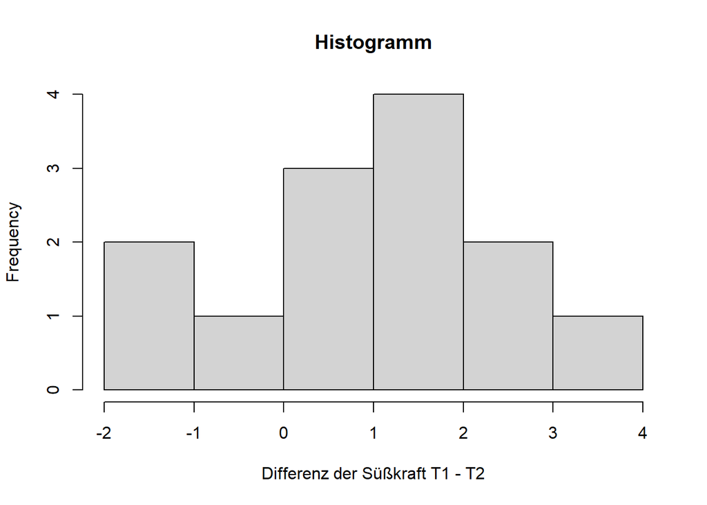

```r
hist(D, main = "Histogramm",
xlab = "Differenz der Süßkraft T1 - T2")
```

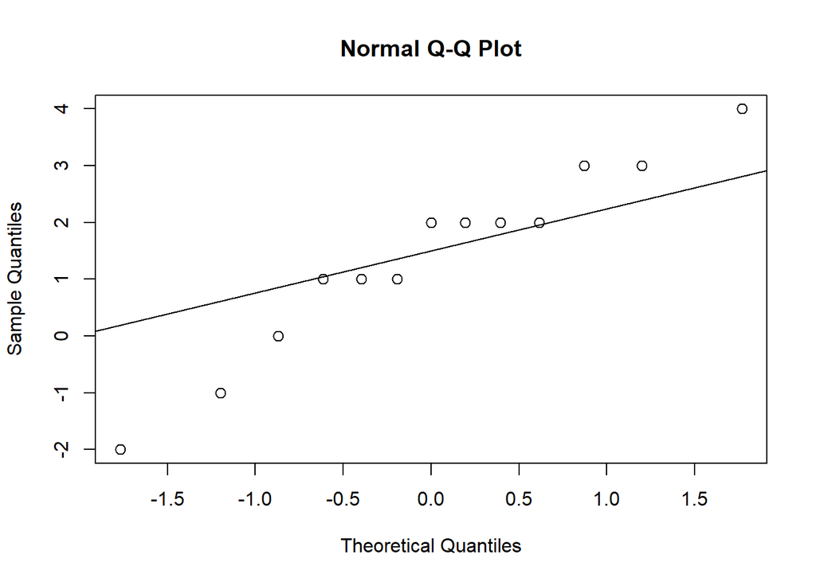

```r
qqnorm(D, cex = 1.2); qqline(D)
```

```r
shapiro.test(D) # p-value > 0.05, Null wird nicht verworfen
```

```
##
##  Shapiro-Wilk normality test
##
## data:  D
## W = 0.949, p-value = 0.58
```

Wir testen $H_0: \mu_D = 0$ vs. $H_A: \mu_D > 0$. Wir testen oberseitig, da wir vermuten, dass die Süßkraft abnimmt.

Der Test wird folgendermaßen durchgeführt:

```r
t.test(T1, T2, alt = "greater", paired = TRUE)
```

```
##
##  Paired t-test
##
## data:  T1 and T2
## t = 3.01, df = 12, p-value = 0.0055
## alternative hypothesis: true mean difference is greater than 0
## 95 percent confidence interval:
##  0.56393     Inf
## sample estimates:
## mean difference
##          1.3846
```

Interpretation: Wenn der wahre Unterschied in der Grundgesamtheit Null ist, ist die Wahrscheinlichkeit, bei einer Zufallsstichprobe von n = 13 eine Abweichung wie in der Stichprobe oder größer zu beobachten, gleich 0.55%. Dieses Ereignis ist also extrem unwahrscheinlich und unser Vertrauen in die Nullhypothese ist “erschüttert”. $H_0$ wird verworfen, weil der p-value < 0.05. Es gibt eine statistisch signifikante Verringerung der Süßkraft. Wir können also davon ausgehen, dass die Süßkraft des Süßstoffes nachlässt.

Was hier noch fehlt ist die Berechnung des Tests “per Hand” (vgl. Lehrbuch, analog zum Welch-Test). Zu berechnen ist der Wert für $df$, die Teststatistik $t$ und schließlich der p-value.

Wir haben also “statistische Signifikanz” gezeigt (p-value < $\alpha$), aber ist das Resultat auch “ökonomisch signifikant”? Dazu berechnen wir ein KI, mit dessen Grenzen wir Hinweise auf die ökonomische Relevanz des Problems erhalten.

Das Intervall (zweiseitig) bestimmt sich mit:

$KI(1-\alpha)_{\mu{_D}} =\bar{d}\pm t_{n-1[1-\alpha/2]}SE(\bar{D})$

```r
t.test(T1, T2, alt = "two.sided", paired = TRUE)
```

```
##
##  Paired t-test
##
## data:  T1 and T2
## t = 3.01, df = 12, p-value = 0.011
## alternative hypothesis: true mean difference is not equal to 0
## 95 percent confidence interval:
##  0.38134 2.38789
## sample estimates:
## mean difference
##          1.3846
```

Das 95%-KI ist [0.38, 2.39]. Das Intervall liefert eine Art best-case-and-worst-case Szenario. Im worst-case reduziert sich die Süßkraft um 2.39 Punkte, im best-case nur um 0.38. Wir können also zu 95% darauf vertrauen, dass ein mit dieser Methode erzeugtes Intervall die wahre mittlere Süßkraftdifferenz beinhaltet. Unser Intervall, [0.38, 2.39], ist ein solches Intervall.

Bei Annahmeverletzungen (Stichprobengröße, Normalverteilungsannahme) bieten sich für die hier vorgestellten t-Tests folgende Alternativen (vgl. Lehrbuch) an:

- MWU-Test für den Welch-Test
- Wilcoxon-Test für gepaarte Stichproben für den gepaarten t-Test

## Inferenz für Einfachregression und Korrelation (nur W662)

Wir wollen nun die Abhängigkeit einer Variablen $Y$ von einer Variablen $X$ beschreiben. Dabei versuchen wir wieder von der Stichprobe auf die Grundgesamtheit zu schließen. Wir konzentrieren uns zunächst auf eine **lineare Abhängigkeit** (lineare Einfachregression). Später erweitern wir die Betrachtung auf nicht-lineare Zusammenhänge, die wir durch eine geeignete Transformation in einen linearen Zusammenhang überführen (log-Transformation).

### Schätzen des Modells

Das wahre (unbekannte) Modell für den linearen Zusammenhang in der **Grundgesamtheit** sei:

$\widehat y = \beta_0 + \beta_1x$

bzw. da es Abweichungen (Fehlerterme $u$) zwischen den vom Modell prognostizierten Werten $\widehat y$ und den wahren Werten $y$ gibt:

$y = \beta_0 + \beta_1x + u$ mit $U \sim N(0, \sigma)$

Wir nennen $Y$ “abhängige” (oder “zu erklärende”) Variable und $X$ “unabhängige” (oder “erklärende”) Variable. Die wahren Fehlerterme $u$ sind annahmegemäß normalverteilt mit Mittelwert null und konstanter Standardabweichung $\sigma$.

Das Ergebnis der Schätzung basierend auf einer **Stichprobe** aus der Grundgesamtheit ist:

$\widehat{y} = \widehat{\beta}_0 + \widehat{\beta}_1x$

bzw.

$y = \widehat{\beta}_0 + \widehat{\beta}_1x + e$

Die beobachteten Fehler (“Residuen” genannt) sind also:

$e = observed - predicted = y - \widehat{y}$

Die geschätzten Parameter des linearen Regressionsmodells berechnen sich mit:

$\widehat{\beta}_1 = \frac{\widehat{{cov}(x,y)}}{\widehat{\sigma}^2_x}$

$\widehat{\beta}_0 = \bar{y} - \widehat{\beta}_1\bar{x}$

Die Berechnung von $\widehat{\beta}_1$ und $\widehat{\beta}_0$ ergibt sich aus der **Minimierung der Summe der quadrierten Residuen**. Der Berechnung liegt also eine Optimierung zu Grunde.

### Annahmen

Folgende Annahmen müssen erfüllt sein, damit wir das Regressionsmodell schätzen und sinnvoll interpretieren können:

1. Linearität: Die Regressionsanalyse ist nur dann sinnvoll, wenn der Zusammenhang zwischen $X$ und $Y$ tatsächlich linear ist.
2. Unabhängigkeit: Die Fehlerterme des Regressionsmodells müssen unabhängig voneinander sein. Liegt eine Zufallsstichprobe vor? Ist die Stichprobe in Relation zur Grundgesamtheit klein?
3. Konstante Varianz der Fehlerterme (Homoskedastizität): Die Streuung der Residuen $e$ sollte die gleiche sein für alle Werte von $X$. Dies ist mit einem Streudiagramm der Residuen und prognostizierten Werte $\widehat{Y}$ (“Kontrollplot”) zu prüfen. Dabei ist darauf zu achten, dass die Streuung der Datenpunkte konstant ist und keine Struktur (Trichter, Klumpen usw.) zu erkennen sind.
4. Normalverteilung der Fehlerterme: Wir nehmen an, dass die wahren Fehlerterme $u$ um die Regressionsgerade für jeden Wert von $X$ einer Normalverteilung $N(0, \sigma)$ folgen und der Erwartungswert der Fehler Null ist. Wir benötigen diese Annahme (für kleine Stichproben), um mit Hilfe der Normalverteilung von der Stichprobe auf die Grundgesamtheit schließen zu können.

Folgende Schritte zur Regressionsgeraden lassen sich identifizieren:

1. Man erstellt zunächst ein Streudiagramm der Daten und prüft, ob ein (näherungsweise) linearer Zusammenhang vorliegt. Ggf. sind die Daten zu transformieren.
2. Ist der Zusammenhang hinreichend linear, schätzt man die Regressionsgerade und ermittelt die Residuen $e$ sowie die prognostizierten Werte $\widehat{y}$.
3. Für den Fall zeitabhängiger Daten sollten die Residuen und die Zeitvariable in einem Streudiagramm dargestellt werden. Damit kann die Unabhängigkeitsannahme geprüft werden.
4. Man erstellt ein Streudiagramm der Residuen $e$ und der prognostizierten Werte $\widehat{y}$. Dieses Streudiagramm (“Kontrollplot”) sollte keine Struktur, auffällige Muster oder ungewöhnliche Beobachtungen zeigen. Ggf. sind zwei Regressionen durchzuführen (mit ungewöhnlichen Beobachtungen und ohne diese).
5. Schließlich erstellt man ein qq-Plot (ggf. inkl. Shapiro-Wilk-Test) oder ein Histogramm der Residuen und prüft die Normalverteilungsannahme und ob Ausreißer vorliegen. Für große Stichproben ($n>30$, besser $n>50$) ist die Erfüllung der Normalverteilungsannahme nicht nötig, da hier wieder der Zentrale Grenzwertsatz greift.

### Eigenschaften

Wichtige Eigenschaften der Regressionsgeraden sind:

- Die Regressionsgerade geht durch den Schwerpunkt des Streudiagramms, also den Punkt $(\bar{x}, \bar{y})$.
- Die Summe der Fehlerterme ist Null, d.h. $\sum e = 0$. Damit ist auch das arithmetische Mittel der Fehler Null ($\bar{e}=0$).
- Die Varianz der abhängigen Variablen, $\widehat{\sigma}_{Y}^2$, kann in zwei Teile zerlegt werden mit: $\widehat{\sigma}_{Y}^2 = \widehat{\sigma}_{\widehat{Y}}^2 + \widehat{\sigma}_{E}^2$. Dabei ist $\widehat{\sigma}_{\widehat{Y}}^2$ die Varianz der Werte auf der Regressionsgeraden (der “fitted values”) und $\widehat{\sigma}_{E}^2$ die Varianz der Fehlerterme in der Stichprobe.

### Hypothesentest für den Anstiegsparameter

Inferenz bedeutet das Schließen von der Stichprobe auf die Grundgesamtheit (analog: Induktion, d.h. das Schließen vom Einzelfall auf das Allgemeine). Wir testen hier eine Nullhypothese über den unbekannten Anstiegsparameter $\widehat \beta_1$ in der Grundgesamtheit.

$H_0: \beta_1 = 0$ vs. $H_A: \beta_1\neq 0$

Normalerweise wird immer die Nullhypothese “wahrer Anstiegsparameter ist gleich Null, d.h., $X$ hat keinen Effekt auf $Y$” getestet.

Wenn $H_0$ wahr ist, gilt:

$\frac{\widehat{\beta}_1}{SE(\widehat{\beta}_1)} \sim T_{df}$ mit $df = n - 2$

mit

$SE(\widehat{\beta}_1) = \frac{\widehat{\sigma}_E}{\widehat{\sigma}_X\sqrt{n-1}}$

mit

$\widehat{\sigma}_E$ = Standardabweichung der Residuen = $\sqrt{\frac{\sum(y - \widehat{y})^2}{(n-2)}}$

$\widehat{\sigma}_X$ = Standardabweichung von $X$

Die Realisation der Testvariablen $T_{df}$ wird genutzt, um einen p-value zu berechnen. Entsprechend lässt sich auch ein Hypothesentest für den Achsenabschnitt durchführen (vgl. Lehrbuch S. 278/279).

Wir können damit auch leicht ein KI für den wahren Anstiegsparameter ($\beta_1$) konstruieren:

$KI(1-\alpha)_{\beta_1} = \widehat{\beta}_1 \pm t_{df[1-\alpha/2]}SE(\widehat{\beta}_1)$

Betrachten wir Bsp. 5.2 aus dem Lehrbuch (S. 91, 279). Wir unterstellen, dass die Beobachtungen zufällig aus einer großen Grundgesamtheit gezogen wurden.

```r
setwd("C:/Users/sturm/Desktop/dataR")   # setze das Arbeitsverzeichnis
data <- read.csv("Bsp._5.2.csv")
# data <- read.csv("https://raw.githubusercontent.com/bodosturm/dataR/main/Bsp._5.2.csv")
data[1:2, ]; attach(data)
```

|  | output | totalcost |
| --- | --- | --- |
| 1 | 20 | 25.1 |
| 2 | 21 | 25.2 |

Die Variable `output` wird in Mengeneinheiten (ME) gemessen, `totalcost` in 1000 Euro.

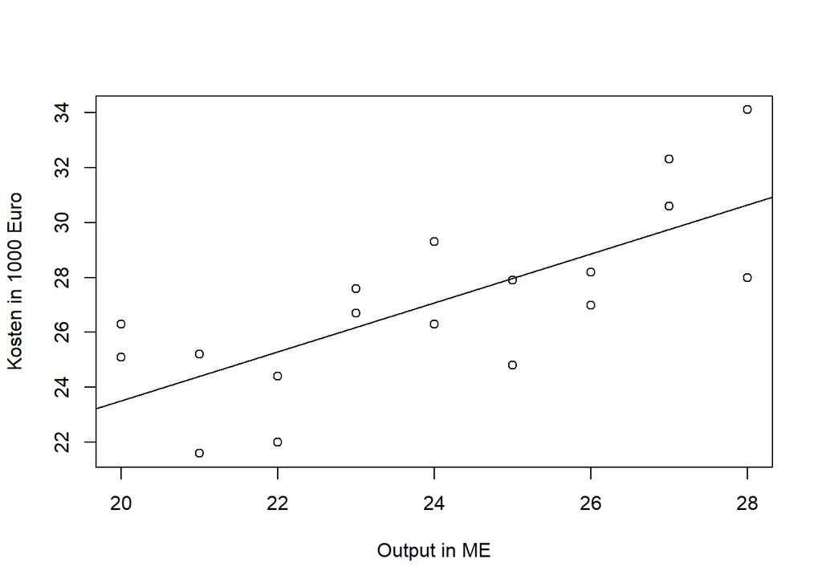

```r
plot(output, totalcost,
xlab = "Output in ME", ylab = "Kosten in 1000 Euro")
abline(lm(totalcost ~ output))
```

```r
ols <- lm(totalcost ~ output) # speichert die Regression, Zugriff später
summary(ols)                  # Output der Regression
```

```
##
## Call:
## lm(formula = totalcost ~ output)
##
## Residuals:
##    Min     1Q Median     3Q    Max
## -3.293 -1.620  0.222  1.548  3.452
##
## Coefficients:
##             Estimate Std. Error t value Pr(>|t|)
## (Intercept)    5.658      4.876    1.16  0.26293
## output         0.892      0.202    4.42  0.00043 ***
## ---
## Signif. codes:  0 '***' 0.001 '**' 0.01 '*' 0.05 '.' 0.1 ' ' 1
##
## Residual standard error: 2.21 on 16 degrees of freedom
## Multiple R-squared:  0.55,   Adjusted R-squared:  0.521
## F-statistic: 19.5 on 1 and 16 DF,  p-value: 0.000431
```

```r
n <- length(output)                          # Zahl Beobachtungen
s_e <- sqrt(sum(ols$residuals^2)/(n-2)); s_e # Residual standard error
```

```
## [1] 2.2128
```

```r
b1_dach <- cov(output, totalcost)/var(output); b1_dach
```

```
## [1] 0.8925
```

```r
b0_dach <- mean(totalcost) - b1_dach*mean(output); b0_dach
```

```
## [1] 5.6578
```

Mit `summary()` kann das Regressionsmodell ausgewertet werden. Für den Anstiegsparameter $\beta_1$ werden ausgegeben: geschätzter Parameter (`Estimate`), Standardfehler des Parameters (`Std. Error`), t-Wert (`t value`) und p-value (`Pr(>|t|)`).

Der Output der Regression für $\beta_1$ in R (also “per Hand”) ist:

```r
SE_b1_dach <- s_e / (sd(output)*sqrt(n-1)); SE_b1_dach
```

```
## [1] 0.202
```

```r
t_b1_dach <- (b1_dach - 0)/SE_b1_dach; t_b1_dach
```

```
## [1] 4.4183
```

```r
p_value_b1_dach <- 2*(1 - pt(t_b1_dach, n - 2)); p_value_b1_dach
```

```
## [1] 0.00043058
```

Das 95%-KI kann mit dem Befehl `confint()`, der auf das Objekt `ols` zugreift, erzeugt werden.

```r
confint(ols, "output", level = 0.95) # 95%-KI für Anstiegsparameter
```

```
##          2.5 % 97.5 %
## output 0.46428 1.3207
```

Das Modell prognostiziert, dass eine Erhöhung des Outputs um 1 ME im Mittel die Kosten um 892.5 Euro erhöht. Dieser Effekt ist statistisch signifikant (p-value < 0.05). Interpretation: Wenn es in der Grundgesamtheit keinen Effekt von `output` auf `totalcost` gibt, dann ist die Wahrscheinlichkeit, einen Effekt wie in der Stichprobe oder extremer zu beobachten, unter 5%. Der F-Test wird im Kapitel “Multiple Regression” behandelt.

Generell ist die **Prognose** eine wichtige Anwendung der Regression. Man kann z.B. einen beliebigen Wert für `output` nehmen und für diesen Wert mit Hilfe der Regressionsgleichung den Wert der abhängigen Variablen, hier `totalcost`, prognostizieren. Dabei ist natürlich der Kontext des Modells zu beachten.

```r
pred_35 <- b0 + b1*35 # Prognose für totalcost(output = 35)
pred_35
```

```
## [1] 36.895
```

### Bestimmtheitsmaß

$R^2$ ist das Bestimmtheitsmaß der Regression und definiert als Anteil der vom Modell erklärten Varianz an der zu erklärenden Varianz.

Es gilt:

$R^2=\frac{\widehat{\sigma}^2_{\widehat{Y}}}{\widehat{\sigma}^2_Y}$ mit $0 \leq R^2 \leq 1$.

Das Bestimmtheitsmaß wird konstruiert basierend auf der **Varianzzerlegung** (vgl. oben):

$\widehat \sigma^2_Y = \widehat\sigma^2_{\widehat{Y}} + \widehat\sigma^2_E$

Ganz analog gilt (ohne den Term $\frac{1}{n-1}$ in der Varianz):

$SST = SSReg + RSS$

$SST=\sum(y-\bar{y})^2$ = Total Sum of Squares. Ein größeres SST bedeutet eine größere Streuung der Y-Variablen, entweder auf Grund von mehr Rauschen in den Residuen (RSS) oder Modellkorrelation (SSReg).

$SSReg=\sum(\widehat{y}-\bar{y})^2$ = Regression Sum of Squares. Ein größeres SSReg bedeutet eine größere Streuung der vom Modell erklärten Werte $\widehat{y}$ (Modellkorrelation).

$RSS=\sum(e^2)$ = Residual Sum of Squares. Ein höheres RSS bedeutet mehr “Rauschen” in den Daten bzw. Residuen und eine weniger präzise Vorhersage.

Daher gilt:

$R^2 = \frac{SSReg}{SST}$ mit $0 \leq R^2 \leq 1$

Betrachten wir das $R^2$ zu Bsp. 5.2 im Lehrbuch oben:

```r
ols$residuals[1:4]   # Residuen
```

```
##        1        2        3        4
##  1.59222  0.79972 -3.29278  0.51472
```

```r
ols$fitted[1:4]      # fitted values = predicted values
```

```
##      1      2      3      4
## 23.508 24.400 25.293 26.185
```

```r
mean(totalcost); mean(ols$fitted) # beide Werte sind gleich
```

```
## [1] 27.078
```

```
## [1] 27.078
```

```r
RSS <- sum(ols$residuals^2); RSS
```

```
## [1] 78.344
```

```r
SSReg <- sum((ols$fitted.values - mean(totalcost))^2); SSReg
```

```
## [1] 95.587
```

```r
SST <- sum((totalcost - mean(totalcost))^2); SST
```

```
## [1] 173.93
```

```r
R2 <- SSReg/SST; R2              # Berechnung R2
```

```
## [1] 0.54957
```

```r
var(ols$fitted)/var(totalcost)   # Alternativ für R2
```

```
## [1] 0.54957
```

Der Anteil der vom Modell erklärten Varianz an der Varianz der abhängigen Variablen beträgt 55%. M.a.W. unser Modell ist in der Lage, 55% der Streuung der abhängigen Variablen zu erklären.

Bei der Einfachregression gilt:

$R^2 = (r_{XY})^2$

Hier:

```r
cor(output, totalcost)^2
```

```
## [1] 0.54957
```

Im Kapitel “Multiple Regression” wird $R^2_{adj}$ eingeführt. $R^2_{adj}$ führt eine “Strafe” ein für komplexere Modelle (mit vielen erklärenden Variablen). Die Abweichung zum $R^2$ ist aber meist relativ gering.

$R^2_{adj} = 1 - (1 - R^2)\frac{(n - 1)}{(n - k - 1)}$ mit $k$ als Zahl erklärende Variablen

Hier ist $k = 1$.

```r
R2adj <- 1 - (1 - R2)*(n - 1)/(n - 1 - 1); R2adj
```

```
## [1] 0.52141
```

Hier noch nötig: Man erstellt ein Streudiagramm der Residuen $e$ und der prognostizierten Werte $\widehat{y}$. Dieses Streudiagramm sollte keine Struktur, auffällige Muster oder ungewöhnliche Beobachtungen zeigen.

Das Streudiagramm zu Bsp. 5.2 im Lehrbuch oben:

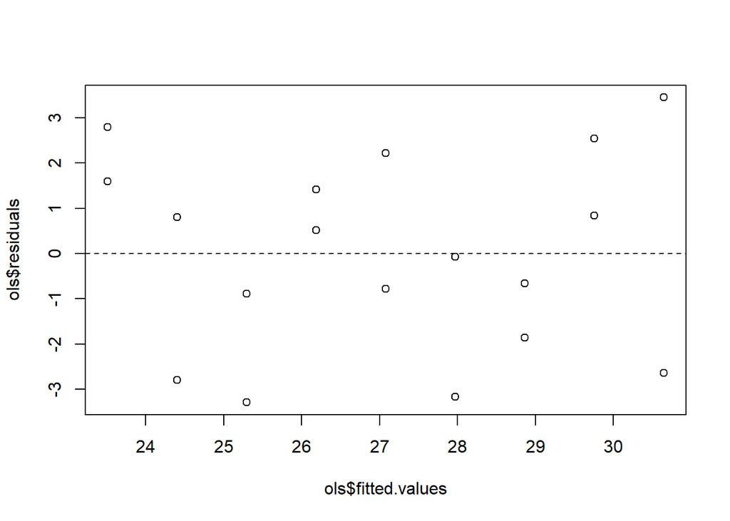

```r
plot(ols$fitted.values, ols$residuals)
abline(h = 0, lty = 2)
```

Man erstellt ein qq-Plot oder ein Histogramm der Residuen und prüft die Normalverteilungsannahme (hier liegt eine kleine Stichprobe mit $n\leq30$ vor) und ob Ausreißer vorliegen.

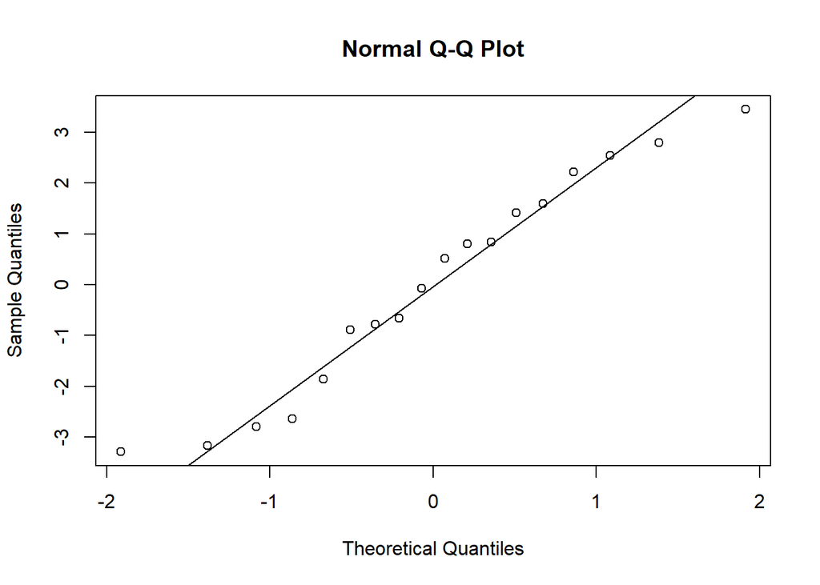

```r
qqnorm(ols$residuals)          # qq-Plot
qqline(ols$residuals)          # mit Linie
```

```r
# H0 der Normalverteilung kann nicht verworfen werden
shapiro.test(ols$residuals)
```

```
##
##  Shapiro-Wilk normality test
##
## data:  ols$residuals
## W = 0.95, p-value = 0.43
```

Für die weitere Diagnose vgl. Kapitel “Multiple Regression”.

Betrachten wir ein weiteres Beispiel.

```r
setwd("C:/Users/sturm/Desktop/dataR")   # setze das Arbeitsverzeichnis
data <- read.csv("wage1.csv")
# data <- read.csv("https://raw.githubusercontent.com/bodosturm/dataR/main/wage1.csv")
names(data)[1:7]; attach(data)
```

```
## [1] "wage"     "educ"     "exper"    "tenure"   "nonwhite" "female"   "married"
```

```r
summary(wage); summary(educ)
```

```
##    Min. 1st Qu.  Median    Mean 3rd Qu.    Max.
##    1.43    3.33    4.65    5.91    6.88   24.98
```

```
##    Min. 1st Qu.  Median    Mean 3rd Qu.    Max.
##     0.0    12.0    12.0    12.6    14.0    18.0
```

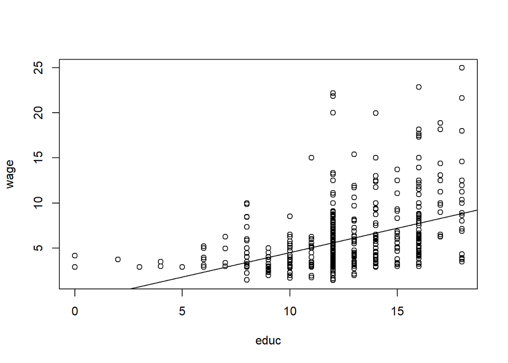

```r
n <- length(wage)
plot(educ, wage)
abline(lm(wage ~ educ))
```

```r
ols1 <- lm(wage ~ educ); summary(ols1)
```

```
##
## Call:
## lm(formula = wage ~ educ)
##
## Residuals:
##    Min     1Q Median     3Q    Max
##  -5.34  -2.16  -0.98   1.19  16.60
##
## Coefficients:
##             Estimate Std. Error t value Pr(>|t|)
## (Intercept)  -0.8863     0.6843    -1.3      0.2
## educ          0.5407     0.0532    10.2   <2e-16 ***
## ---
## Signif. codes:  0 '***' 0.001 '**' 0.01 '*' 0.05 '.' 0.1 ' ' 1
##
## Residual standard error: 3.37 on 523 degrees of freedom
## Multiple R-squared:  0.165,  Adjusted R-squared:  0.163
## F-statistic:  103 on 1 and 523 DF,  p-value: <2e-16
```

```r
b1_dach <- cov(wage, educ)/var(educ); b1_dach
```

```
## [1] 0.54065
```

```r
b0_dach <- mean(wage) - b1_dach*mean(educ); b0_dach
```

```
## [1] -0.8863
```

Gemäß der Modellprognose erhöht ein zusätzliches Jahr Bildung den Stundenlohn um im Mittel 0.54$. Dieser Effekt ist statistisch hochsignifikant (p-value < 0.01). Aber: Offensichtlich ist hier die Annahme eines linearen Zusammenhangs und der Homoskedastizität verletzt.

Ausgabe der Residuen:

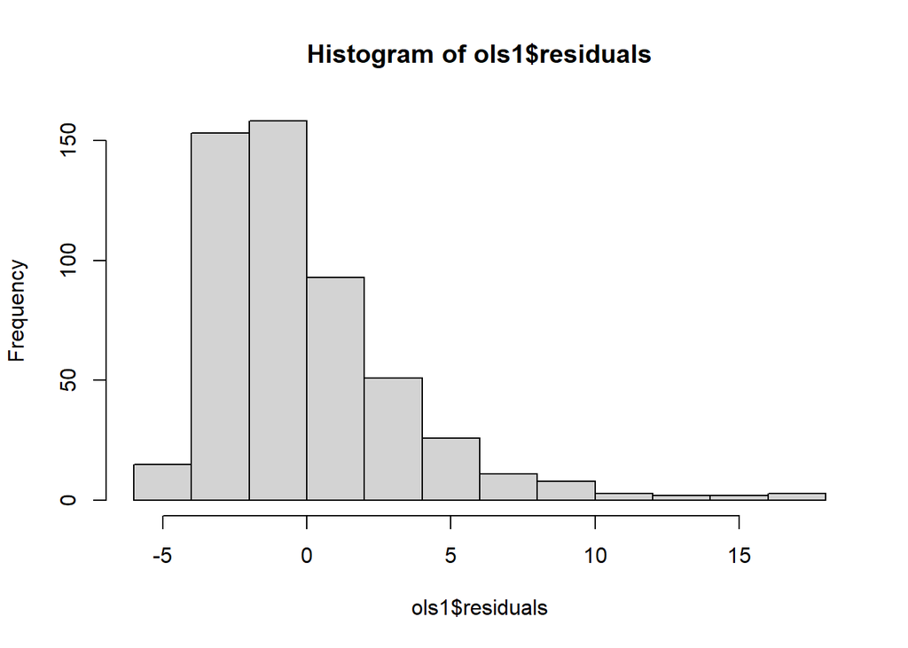

```r
hist(ols1$residuals)
```

Auch die Normalverteilungsannahme ist verletzt (das ist aber hier unkritisch, weil eine große Stichprobe vorliegt). Dies zeigt auch der Shapiro-Wilk-Test.

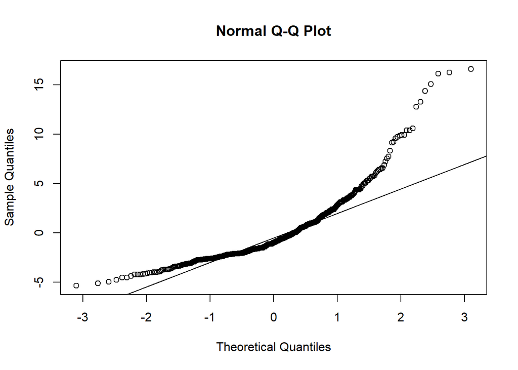

```r
qqnorm(ols1$residuals); qqline(ols1$residuals)
```

```r
shapiro.test(ols1$residuals)
```

```
##
##  Shapiro-Wilk normality test
##
## data:  ols1$residuals
## W = 0.844, p-value <2e-16
```

Die Verletzung der Homoskedastizitätsannahme (konstante Varianz der Fehlerterme) lässt sich auch mit einem Streudiagramm der prognostizierten Werte $\widehat{y}$ und der Residuen $e$ zeigen. Wir wollen die Residuen in diesem Plot standardisiert darstellen (vgl. Kapitel “Multiple Regression”). Für die Standardisierung benötigen wir die Standardabweichung der Residuen (auch “Residual Standard Error” genannt, wird auch mit `summary()` ausgegeben):

$\widehat{\sigma}_E = \sqrt{\frac{\sum(y - \widehat{y})^2}{(n-2)}}$

```r
SE_res <- sqrt(sum(ols1$residuals^2)/(n-2)); SE_res
```

```
## [1] 3.3744
```

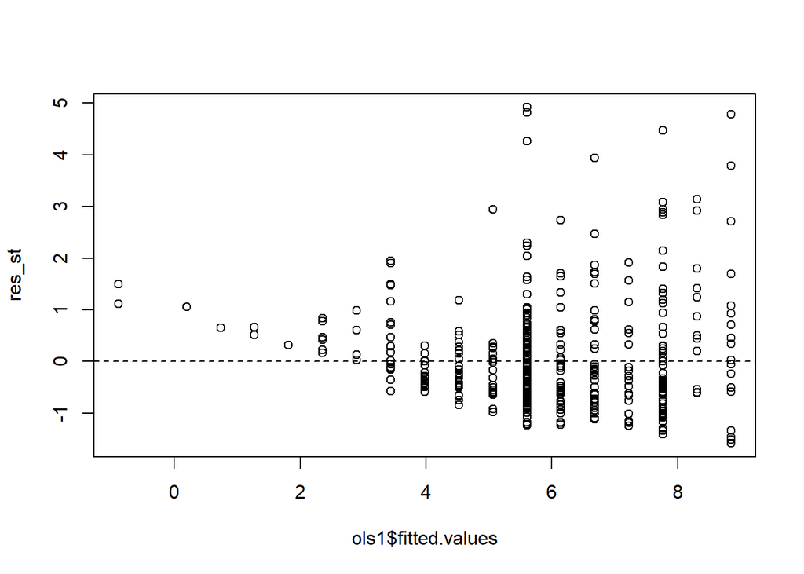

```r
res_st <- ols1$residuals/SE_res
plot(ols1$fitted.values, res_st)
abline(h = 0, lty = 2)
```

Auf der y-Achse ist die Dimension jetzt nicht mehr USD (dies wäre der Fall, wenn man die nicht-standardisierten Residuen darstellen würde), sondern die Standardabweichung von $e$.

Offensichtlich liegt hier eine deutliche Struktur im Streudiagramm vor. Das Modell verletzt die Regressionsannahmen. Wir müssen also das Modell um zusätzliche erklärende Variablen wie z.B. Geschlecht, Job-Erfahrung usw. erweitern und/oder die Variablen transformieren, damit ein linearer Zusammenhang entsteht.

Wir transformieren hier die abhängige Variable $Y$, um diese “zu stauchen”. Hier ist log(wage) = ln(wage) = lwage schon definiert.

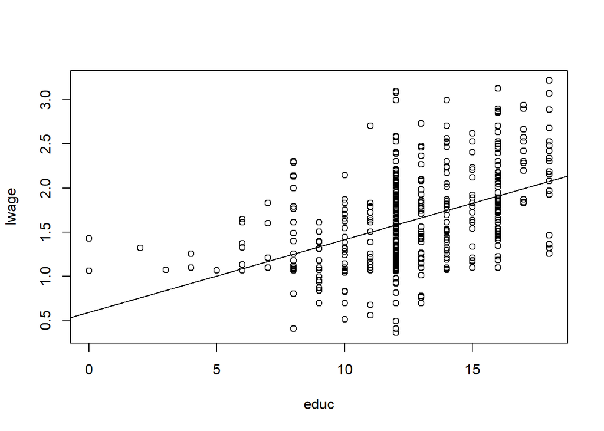

```r
plot(educ, lwage)
abline(lm(lwage ~ educ))
```

Die Annahme der Homoskedastizität ist deutlich besser erfüllt. Jetzt liegt eine gleichmäßigere Streuung der Beobachtungen um die Regressionsgerade vor. Auch ist der Zusammenhang nun näherungsweise linear.

```r
ols2 <- lm(lwage ~ educ)
summary(ols2)
```

```
##
## Call:
## lm(formula = lwage ~ educ)
##
## Residuals:
##    Min     1Q Median     3Q    Max
## -1.223 -0.367 -0.077  0.293  1.519
##
## Coefficients:
##             Estimate Std. Error t value Pr(>|t|)
## (Intercept)  0.59188    0.09545     6.2  1.1e-09 ***
## educ         0.08243    0.00742    11.1  < 2e-16 ***
## ---
## Signif. codes:  0 '***' 0.001 '**' 0.01 '*' 0.05 '.' 0.1 ' ' 1
##
## Residual standard error: 0.471 on 523 degrees of freedom
## Multiple R-squared:  0.191,  Adjusted R-squared:  0.189
## F-statistic:  123 on 1 and 523 DF,  p-value: <2e-16
```

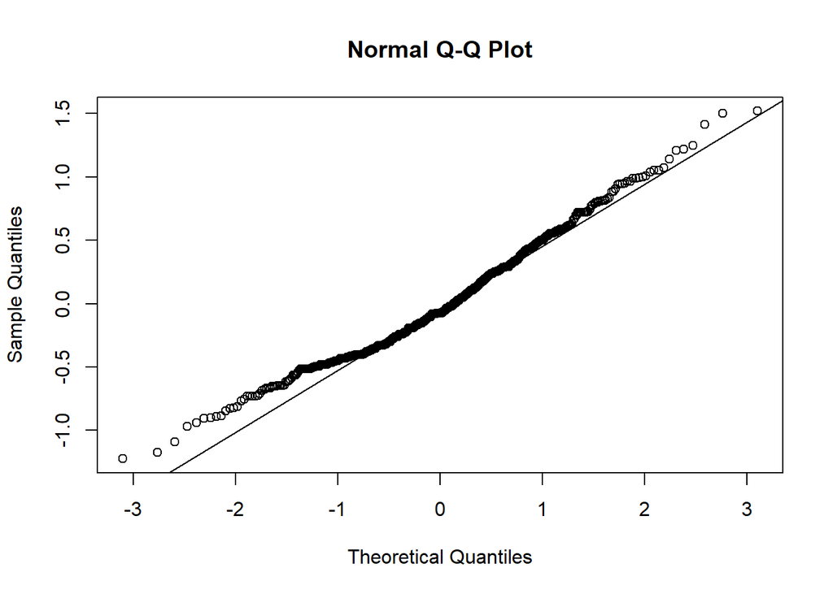

```r
qqnorm(ols2$residuals); qqline(ols2$residuals)
```

```r
shapiro.test(ols2$residuals)
```

```
##
##  Shapiro-Wilk normality test
##
## data:  ols2$residuals
## W = 0.981, p-value = 2.7e-06
```

Auch hier ist die Normalverteilungsannahme verletzt. Allerdings ist dies unproblematisch, da die Stichprobe hinreichend groß ist.

Für die Interpretation des Anstiegsparameters $\widehat {\beta}_1$ müssen wir berücksichtigen, dass $Y$ logarithmisch transformiert wurde, also $log(wage)$ die abhängige Variable ist. Der folgende Abschnitt betrachtet diesen wichtigen Punkt.

### log-Transformation

In der Praxis liegen häufig **nicht-lineare Zusammenhänge** vor. Die lineare Einfachregression kann dann nicht angewendet werden. Durch eine geeignete Transformation lassen sich nicht-lineare Zusammenhänge aber häufig in lineare Zusammenhänge umwandeln. Das Konzept der linearen Einfachregression ist dann wieder anwendbar, allerdings ändert sich die Interpretation der Parameter des Regressionsmodells.

#### Exkurs: Logarithmus

Als Logarithmus $x$ einer Zahl $y$ bezeichnet man den Exponenten, mit dem eine vorher festgelegte Zahl, die Basis, potenziert werden muss, um die gegebene Zahl $y$ zu erhalten. Wird als Basis $e = 2.71828$, die Eulersche Zahl, gewählt, so erhält man den natürlichen Logarithmus.

$y = e^x$ => $x = log_e$ $y=ln$ $y$

In R wird der natürliche Log durch `log()` berechnet.

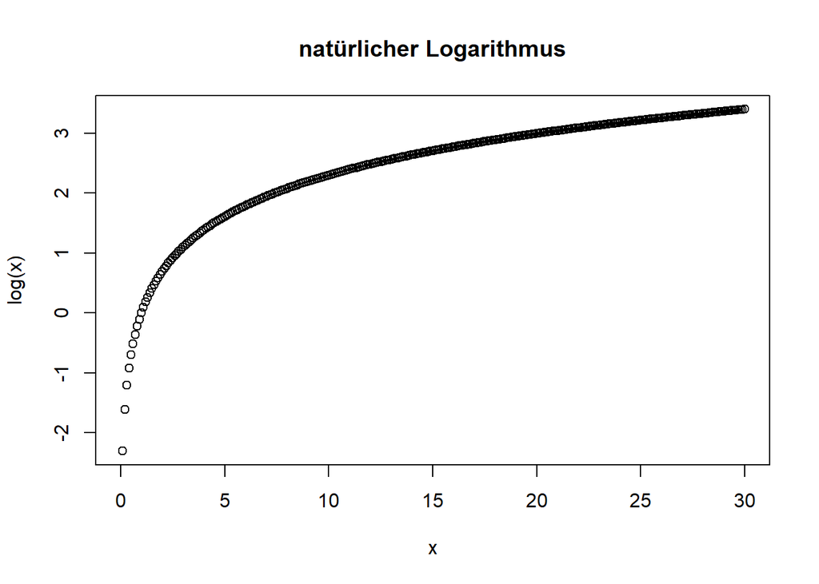

```r
x <- seq(0, 30, 0.1); y <- log(x)
plot(x, y, ylab = "log(x)", main = "natürlicher Logarithmus")
```

Offensichtlich ist der natürliche Log eine nicht-lineare Funktion. Daher kann der natürliche Log auch verwendet werden, um bestimmte nicht-lineare Zusammenhänge zu linearisieren. Weiterhin hat der natürliche Log eine nützliche Eigenschaft: die logarithmierte Differenz einer Variablen misst näherungsweise die relative Änderung der ursprünglichen Variable.

```r
1.05/1 - 1            # Wachstumsrate = 5%
```

```
## [1] 0.05
```

```r
log(1.05) - log(1)    # Differenz der Logs = ca. 5%
```

```
## [1] 0.04879
```

Ausgehend von einem linearen Modell $\widehat {y} = \widehat \beta_0 + \widehat \beta_1x$ unterscheiden wir drei Arten der **log-Transformation**: (1) das log-linear Modell, (2) das linear-log Modell, und (3) das log-log Modell (vgl. folgende Tabelle).

Beim **log-linear Modell** (wie im Beispiel mit dem Stundenlohn) wird nur die abhängige Variable einer log-Transformation unterzogen:

$\widehat {log(y)} = \widehat \beta_0 + \widehat \beta_1x$

Beim **linear-log Modell** wird nur die unabhängige Variable einer log-Transformation unterzogen:

$\widehat y = \widehat \beta_0 +\widehat \beta_1log(x)$

Beim **log-log Modell** werden beide Variablen logarithmiert und es gibt einen linearen Zusammenhang zwischen den Logs:

$\widehat {log(y)} = \widehat \beta_0 + \widehat \beta_1log(x)$

Das log-log Modell ist vor allem deshalb so wichtig, weil es zum **Schätzen von Elastizitäten** verwendet wird (vgl. unten).

Interpretation des Anstiegsparameters $\widehat \beta_1$

|  | $x$ | $log(x)$ |
| --- | --- | --- |
| $\widehat {y}$ | ${\widehat\beta}_1 = d \widehat y / d x$ | ${\widehat \beta}_1 = d \widehat y / (dx / x)$ |
| $\widehat {log(y)}$ | ${\widehat \beta}_1 = (d \widehat y / \widehat y)/ dx$ | ${\widehat \beta}_1 = (d \widehat y / \widehat y) / (dx / x)$ |

Interpretation:

linear: ${\widehat\beta}_1 = d \widehat y / dx$ $\Rightarrow$ Wenn $x$ um 1 Einheit steigt, steigt $\widehat y$ um ${\widehat\beta}_1$ Einheiten

log-linear: ${\widehat\beta}_1 = (d \widehat y / \widehat y)/ dx$ $\Rightarrow$ wenn $x$ um 1 Einheit steigt, erhöht sich $\widehat y$ um ${\widehat\beta}_1$*100%

linear-log: ${\widehat\beta}_1 = d \widehat y / (dx / x)$ $\Rightarrow$ wenn $x$ um 1% steigt, erhöht sich $\widehat y$ um ${\widehat\beta}_1/100$ Einheiten

log-log: ${\widehat\beta}_1 = (d \widehat y / \widehat y) / (dx / x)$ $\Rightarrow$ wenn $x$ um 1% steigt, erhöht sich $\widehat y$ um ${\widehat\beta}_1$%

Betrachten wir nochmal unser Beispiel mit `wage` und `educ`. Interpretation: Das Modell prognostiziert, dass ein Jahr mehr Bildung im Mittel den Stundenlohn um 8% erhöht. Der Anstiegsparameter ${\widehat\beta}_1$ ist in diesem log-linear Modell also eine konstante relative Größe (eine sog. **Semi-Elastizität**)

Die Rücktransformation und grafische Darstellung im Plot für `educ` und `wage` erfolgt folgendermaßen:

```r
log(2.718) # Der Log der Eulerschen Zahl e muss 1 sein
```

```
## [1] 0.9999
```

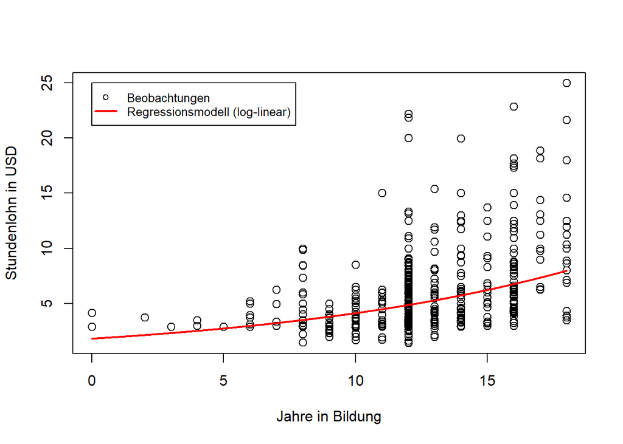

```r
educ_ols <- seq(0, 18, 0.01)
wage_ols <- 2.718^(0.59188 + 0.08243*educ_ols)
plot(data$educ, data$wage, cex = 1.2, ylab = "Stundenlohn in USD", xlab = "Jahre in Bildung")
lines(educ_ols, wage_ols, lwd = 2, col = "red")
legend(0, 25, pch = c(1,NA), c("Beobachtungen","Regressionsmodell (log-linear)"), lwd = c(NA,2),
col = c("black","red"), cex = 0.8)
```

Wir sehen in der Abbildung oben, dass ein konstanter relativer Anstieg (ca. +8% pro Jahr) zu einem absolut zunehmenden Effekt von `educ` auf `wage` führt. Wenn `educ = 10`, prognostiziert das Modell ca. 0.35 USD mehr Stundenlohn für ein zusätzliches Jahr Bildung (von 4.11 USD zu 4.46 USD, ca. +8.5%). Wenn `educ = 15`, prognostiziert das Modell ca. 0.53 USD mehr Stundenlohn (von 6.21 USD zu 6.74 USD, ca. +8.5%) für ein zusätzliches Jahr Bildung. Die Abweichungen zum Modell ergeben sich u.a. dadurch, dass wir runden und einen stetigen Zusammenhang diskret (+1 Jahr) interpretieren.

Wir betrachten nun das folgende Beispiel:

```r
setwd("C:/Users/sturm/Desktop/dataR")   # setze das Arbeitsverzeichnis
data <- read.csv("GDPpc_pm_live.csv")
# data <- read.csv("https://raw.githubusercontent.com/bodosturm/dataR/main/GDPpc_pm_live.csv")
data[1:2, ]; attach(data); dim(data)
```

|  | code | GDPpc | pm | live |
| --- | --- | --- | --- | --- |
| 1 | AFG | 496.6 | 58.331 | 62.941 |
| 2 | AGO | 2189.9 | 24.599 | 63.051 |

```
## [1] 186   4
```

```r
data <- subset(data, live > 40, ); attach(data); dim(data) # Hier ohne den Ausreißer
```

```
## [1] 185   4
```

Wir interessieren uns für die Variablen `GDPpc` (pro-Kopf GDP in USD) und `live` (Lebenserwartung bei Geburt in Jahre). Die Daten wurden von der Weltbank für 2019 erhoben (vollständig für 186 Länder).

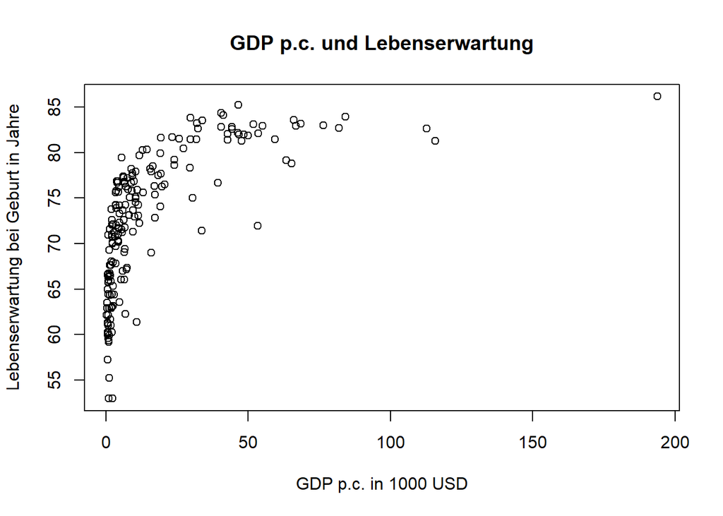

```r
plot(GDPpc/1000, live, xlab = "GDP p.c. in 1000 USD", ylab = "Lebenserwartung bei Geburt in Jahre",
     main = "GDP p.c. und Lebenserwartung")
```

Wie wir sehen, gibt es einen positiven Zusammenhang zwischen GDP p.c. und Lebenserwartung. Allerdings ist dieser positive Zusammenhang nicht linear. Für geringe GDP p.c. Werte führt ein höheres Einkommen zu drastischen Zugewinnen bei der Lebenserwartung, bei höheren GDP p.c. Werten sind die Zugewinne nur noch relativ klein.

Wenn wir GDP p.c. logarithmieren, ändert sich das Bild.

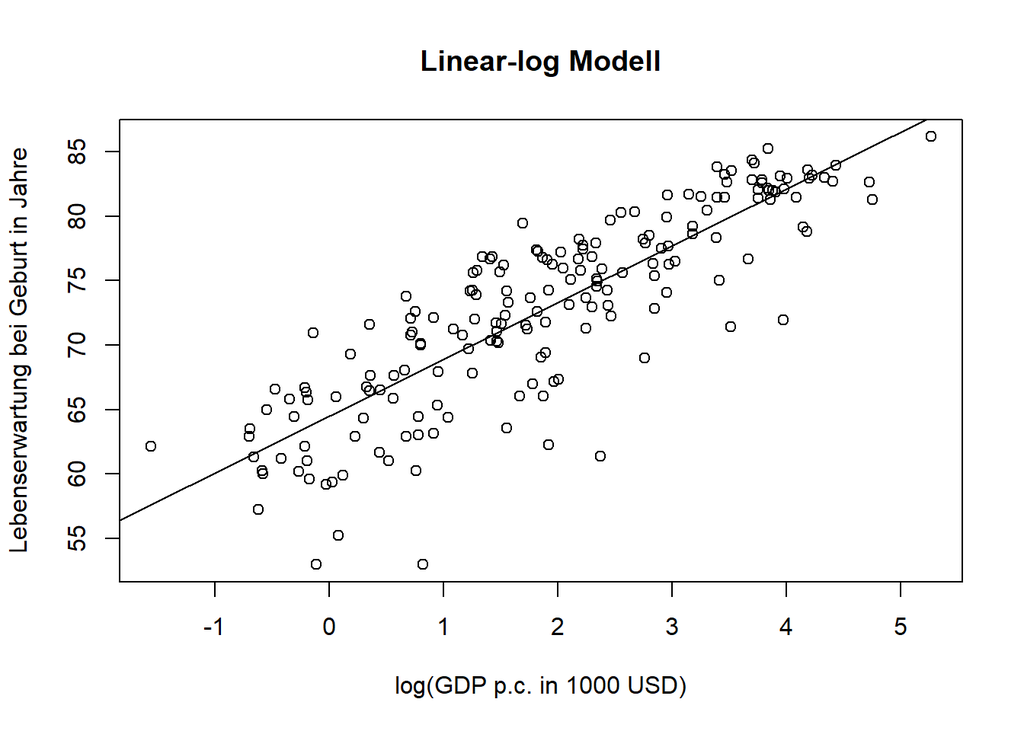

```r
plot(log(GDPpc/1000), live, xlab = "log(GDP p.c. in 1000 USD)", ylab = "Lebenserwartung bei Geburt in Jahre",
     main = "Linear-log Modell")
abline(lm(live ~ log(GDPpc/1000)))
```

Es gibt einen relativ starken, positiven, linearen Zusammenhang zwischen `log(GDPpc/1000)` und `live`. Wir schätzen ein linear-log Modell.

```r
ols <- lm(live ~ log(GDPpc/1000))
summary(ols)
```

```
##
## Call:
## lm(formula = live ~ log(GDPpc/1000))
##
## Residuals:
##     Min      1Q  Median      3Q     Max
## -15.065  -1.656   0.531   2.839   7.519
##
## Coefficients:
##                 Estimate Std. Error t value Pr(>|t|)
## (Intercept)       64.474      0.480   134.3   <2e-16 ***
## log(GDPpc/1000)    4.403      0.201    21.9   <2e-16 ***
## ---
## Signif. codes:  0 '***' 0.001 '**' 0.01 '*' 0.05 '.' 0.1 ' ' 1
##
## Residual standard error: 3.95 on 183 degrees of freedom
## Multiple R-squared:  0.723,  Adjusted R-squared:  0.722
## F-statistic:  478 on 1 and 183 DF,  p-value: <2e-16
```

Das geschätzte Modell (linear-log) ist: $\widehat {live} = 64.5 + 4.4*log(GDPpc/1000)$. Der Anstiegsparameter dieses Modells ist folgendermaßen zu interpretieren: Eine Erhöhung des GDP p.c. um 1% führt gemäß Modellprognose zu einer um 0.044 Jahre höheren Lebenserwartung. Oder: Eine Erhöhung des GDP p.c. um 10% führt gemäß Modellprognose zu einer um ca. 0.44 Jahre höheren Lebenserwartung.

Wir betrachten nochmal die ursprünglichen Daten mit dem geschätzten Modell.

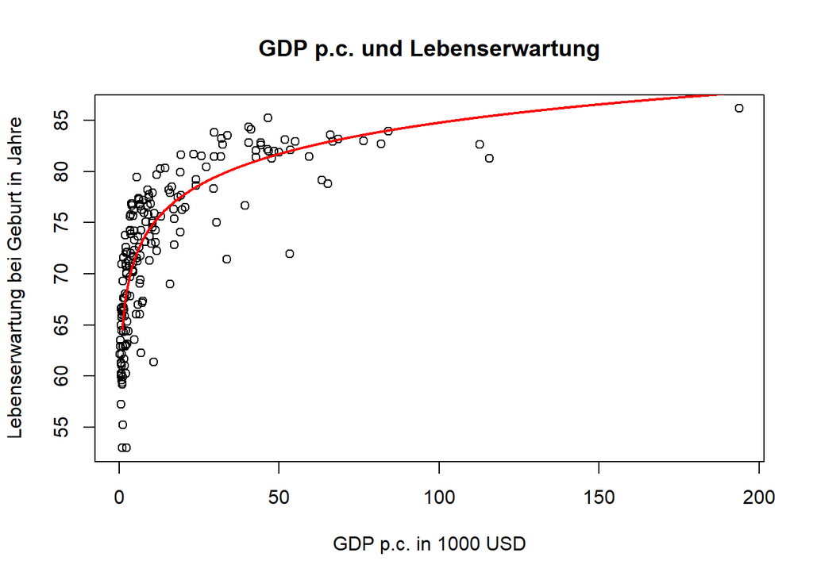

```r
gdp <- seq(1, 200, 0.1)
le <- 64.5 + 4.4*log(gdp)
plot(GDPpc/1000, live, xlab = "GDP p.c. in 1000 USD",
     ylab = "Lebenserwartung bei Geburt in Jahre",
     main = "GDP p.c. und Lebenserwartung")
lines(gdp, le, lwd = 2, col = "red")
legend(100, 50, pch = c(1,NA), c("Beobachtungen","Regressionsmodell (linear-log)"),
       lwd = c(NA,2), col = c("black","red"), cex = 0.8)
```

Wir prüfen das Modell: Bei einem GDP p.c. von 5000 USD prognostiziert das Modell eine Lebenserwartung von 71.56 Jahre. Steigt das GDP p.c. auf 5500 USD (+10%), so prognostiziert das Modell eine Lebenserwartung von 71.98 (ein Plus von 0.42 Jahre). Auf eine Diskussion der Modellannahmen und der Ausreißer verzichten wir hier aus Platzgründen.

```r
64.474 + 4.403*log(5); 64.474 + 4.403*log(5.5)
```

```
## [1] 71.56
```

```
## [1] 71.98
```

Um die Varianzzerlegung zu illustrieren, können auch die Varianzen ausgeben lassen.

```r
var(live); var(ols$residuals); var(ols$fitted.values)
```

```
## [1] 55.937
```

```
## [1] 15.489
```

```
## [1] 40.448
```

Wir betrachten abschließend das folgende Beispiel mit den Variablen $P$ und $Q$:

```r
setwd("C:/Users/sturm/Desktop/dataR")   # setze das Arbeitsverzeichnis
data <- read.csv("Elasticity.csv")
# data <- read.csv("https://raw.githubusercontent.com/bodosturm/dataR/main/Elasticity.csv")
data[1:2, ]; attach(data)
```

|  | P | Q |
| --- | --- | --- |
| 1 | 1 | 220.0 |
| 2 | 1 | 196.2 |

Die Menge $Q$ wird in Mengeneinheiten (ME) angegeben, der Preis $P$ in Euro. Ziel ist, eine Nachfragefunktion $Q(P)$ zu schätzen. Wir schätzen zunächst das lineare Modell $\widehat Q = \widehat \beta_0 + \widehat \beta_1P$.

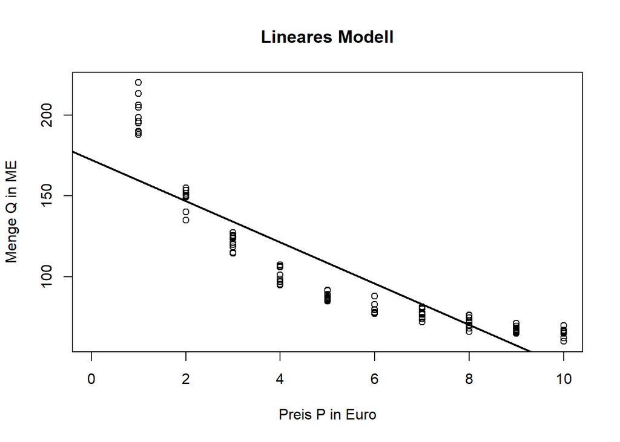

```r
plot(P, Q, xlab = "Preis P in Euro", ylab = "Menge Q in ME",
     main = "Lineares Modell", xlim = c(0, 10))
abline(lm(Q ~ P), lwd = 2)
```

```r
ols3 <- lm(Q ~ P); ols3
```

```
##
## Call:
## lm(formula = Q ~ P)
##
## Coefficients:
## (Intercept)            P
##       172.3        -12.7
```

Steigt der Preis um 1 Euro, geht gemäß der Modellprognose im Mittel die Nachfrage um 12.7 ME zurück. Offensichtlich ist aber die Annahme eines linearen Zusammenhangs verletzt. Auch das Streudiagramm der Residuen und der vorhergesagten Werte zeigt, dass das Modell die Abhängigkeit zwischen $P$ und $Q$ nicht richtig abbildet.

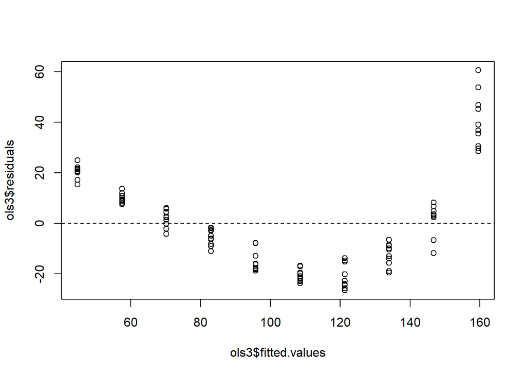

```r
plot(ols3$fitted.values, ols3$residuals)
abline(h = 0, lty = 2)
```

In diesem Plot ist eine deutliche Struktur erkennbar. Wir müssen die Daten geeignet transformieren, um den Zusammenhang zu linearisieren. Hier bietet sich die Transformation von $X$ und $Y$ mit dem natürlich Logarithmus (log) an.